# 总目录

小说创作大师班

故事创作大师班.国际卷

文学的读法

文学理论

小说的八百万种写法

写小说最重要的十件事

小说创作大师班

[美]威廉·凯恩 著  
黄筠 译

版权信息

**书名：**小说创作大师班

**作者：**[美]威廉·凯恩

**译者：**黄筠

**版权：**后浪出版咨询（北京）有限责任公司

###### 献给

> 我的妻子玛丽莲，

> 她让我用尽了辞藻。

> 还有我的女儿凯特，

> 她经常吃我的手稿！

返回总目录

# 前言

当许多人在键盘上绞尽脑汁“砰砰”地敲字，并抱怨“为什么我就不能写出像大师一样的作品？”时，答案其实是你可以做得到。不过在此之前，你得认清一个事实：大师所受到的教育和我们有很大的不同。

在过去约80年里，创作者们非常不幸地错过了一个关键方法的训练，而他们的前辈们却惯用此法来提升自己的写作水平。这一被忽视的技巧理应是作家们最为重要的法宝之一，两千多年来这个方法屡试不爽，在如今却被突然抛之脑后。几乎所有的大师都用到了这一法宝，而你可能因近年来教育体系的影响冷落了它。如果你意识到这一门被遗忘的技巧的存在，并磨炼它，它将对你的创作产生极大的影响，就像发生在乔叟①、莎士比亚、弥尔顿②、蒲柏③、斯威夫特④、 T. S.艾略特⑤等大师身上的一样，它为你的作品注入新的生命，甚至让你的创作实现飞跃。

说到这里，你一定很想知道你和那些大师所受到的教育到底有何不同吧？不过，在告诉你答案之前，请容我先问个问题。当你还是学生时，你会经常听到“原创”这个词吗？换句话说，你会被经常要求写出新东西，写的东西要有所突破，并用自己的语言进行创作吗？也许，你和大多学生一样，傻傻地被那些禁止抄袭、禁止弄虚作假并坚持原创的要求牵着鼻子走。许多大学老师也会对学生们说“让我听到你们的想法！”这些大学课堂上的要求至今仍萦绕在我们大多数人的耳旁。

然而，这就是问题所在—不管你信不信。

说到底，你不可能凭空变成一个卓越的作家。在你像舞王弗雷德·阿斯泰尔⑥那样脱下外套就立马能在字里行间起舞之前，你需要的是积淀，是系统性的知识，是扎实的写作技巧以及对语言的基本悟性。

在我向你解释清楚你的教育中到底缺失了哪一环之前，还是先让我聊聊，我是如何偶然发现这一令人遗憾的事实的。那是在我去法学院之前还徘徊在图书馆散发着霉味的旧书架间的日子，当时我是大学辩论社的主席，我需要搜集尽可能多的资料来打败对手。因此，我会在波士顿大学图书馆闷热的三楼站上几小时翻看政府文件。我当时还在大学电台工作，因此我会顺便为我的广播剧找些素材。就这样在一个晚上，我偶然发现了一整排关于古典修辞学的书。这些布满尘埃的书里居然满是我们在面向一小撮忠实听众的肥皂剧中可以用到的金点子。

除此之外，我还发现了另一个事实，那就是古典修辞学这一门学问并未在任何一门大学写作课程中被教授过，至少，我找不到类似的课程。相对应的，修辞学被划分到了语言传播系，在那里我们只上过关于亚里士多德、西塞罗、昆体良⑦的一些无聊讲座。言归正传，我想说的是，在当今的写作教育中被忽视的这门学问正是修辞学。爱德华·P. J.科比特（Edward P. J. Corbett）作为在这一领域仍然健在的并被公认为最有造诣的学者也曾宣称道，修辞学中的核心要素早在20世纪30年代前后就逐步退出了美国教育的舞台。⑧

那么，你为什么需要去关心修辞学的沉寂与否呢？难道修辞学不就是用语调和情绪来说服或感染他人吗？也许在某些地方确是如此，但它并不仅仅是你来我往的唇枪舌剑或冠冕堂皇的布道宣教，它还包括措辞的恰当得体以及文风的精通熟稔。究其本源，修辞学还涉及如何确保文章的选题、选材及编排的清晰、巧妙和有趣。除此之外，它还能教导人们如何通过一个导言去诱导读者，一直牵着读者的鼻子让他读到文章最后。而这就是你想做的，不是吗？

那么，就请允许我向你展示修辞学的其中一面，单单这冰山一角就能够切实地拯救你的写作，给你的文风注入新的活力，并赋予你和那些最为优秀、最为聪明的人一样的文笔。关于古典修辞学中的这一技巧—“模仿”将在本书中得到全面讲解。是的，你没看错，这是一本关于如何去“模仿”文学大家的书，而这一技巧在现代教育出现后就从修辞学的版图上掉下来、穿过地面、从地表上消失了。⑨但是，模仿可能仍是成为成功作家的路上最为有效的修辞手法（此处可比照亚里士多德、西塞罗以及其他权威人士）。⑩

这也太简单了吧，简直让人难以相信？好吧，现在请试着想一想披头士、海滩男孩，或者你音乐播放器里的任何一个歌手，他们几乎都是先通过翻唱其他人的歌来磨炼自己的歌喉和技艺。说得更简单一点，他们都是通过模仿其他歌手的作品来开启自己的职业生涯。他们只有掌握这些基础之后，才会尝试创作自己的作品。那为什么作家就不能这么做呢？为什么他们就不能被指导和鼓励着去做相同的事，而这恰好还是古典模仿这一修辞手法所擅长的领域？

你将像音乐家一样，通过模仿名家大师的作品，吸收他们的风格来完成自己的创作。模仿将帮助你成长为一名出色的作家，就像它曾助力过弥尔顿、梅尔维尔、福楼拜、福克纳、狄更斯和莎士比亚一样。更为重要的是，除非学会了通过模仿来博采众长，你无法期望自己能完全激发出作为作家的全部潜能。⑪

这本书详细介绍了历经过时间检验但现今的作家并未在学校中学习的方法，它将帮助你提高写作水平，创作出更好的作品，好到甚至可以创造奇迹，将一个文笔乏味的作者培养成为像塞林格、海明威那样可以在文字的海洋中自由徜徉的作家。我保证，本书中的技巧所给予你在创作上的帮助不会像你之前学过的课程一样不痛不痒。作为一名英语教授，我已经用这些技巧指导了一代学生。所以，我以亲身经历担保这些方法十分有效。读完这本书，相信你也会有同感。

书中的各个章节将弥补你在课堂上的那些知识空白。我将通过剖析21位著名作家的作品来展示古典修辞学中的模仿手法，并告诉你如何在自己的创作中运用他们的写作技巧。就像画家在创作前需要学会构图、笔法、调色等绘画基础一样，你也将在本书中学习到创作的基本要素，包括对文章节奏韵律的把握、人物的刻画、故事的展开等等，以便站在巨人的肩膀上提升自己的写作技巧和水平，就像巨人们曾经做过的那样。

本书的最终目的并不是让你成为其他作家的复制品，而是帮助你了解他们成功的秘诀，让你能够自信、有范儿地发出自己独特的声音。一旦你用模仿掌握了接下来的章节中介绍的技巧, 属于你自己的声音就会在此基础之上以某种从未展现过的方式显现出来。

换作是我，就会毫不犹豫地将自己的声音发出来。从多年前我在图书馆里偶然发现了那些布满灰尘的书卷的那刻起，我就一直在等待着这个机会—写出你现在拿着的这本书。相信它能够帮助你超越同时代的作家。最后，愿你在阅读和使用这本书的过程中充满探索的喜悦和激情。

①杰弗雷·乔叟（Geoffrey Chaucer，1343—1400），英国小说家、诗人。主要作品有小说集《坎特伯雷故事集》。—译者注

②约翰·弥尔顿（John Milton，1608—1674），英国诗人、政论家，英国文学史上伟大的六大诗人之一清教徒文学的代表者。代表作品有长诗《失乐园》《复乐园》和《力士参孙》。—译者注

③亚历山大·蒲柏（Alexander Pope，1688—1744），18世纪英国最伟大的诗人，代表作品《伊利亚特》《奥德赛》《田园诗集》。—译者注

④乔纳森·斯威夫特（Jonathan Swift，1667—1745），18世纪英国著名文学家、讽刺作家、政治家，代表作《格列佛游记》。—译者注

⑤托马斯·斯特尔那斯·艾略特（Thomas Stearns Eliot，1888—1965）（通称T. S.艾略特），英国诗人、剧作家和文学批评家，诗歌现代派运动领袖，代表作品有《荒原》《四个四重奏》等。—译者注

⑥弗雷德·阿斯泰尔（Fred Astaire，1899—1987），美国电影演员、舞蹈家、舞台剧演员、编舞、歌手。演出生涯长达76年，出演过31部歌舞剧，代表作有《鬼故事》《狗王擒贼王》等。1950年，获得奥斯卡终身成就奖。—译者注

⑦昆体良（Marcus Fabius Quintilianus，约35—约100），古罗马时期的著名律师、教育家和皇室委任的第一个修辞学教授。—译者注

⑧科比特，1971年，第32—33页，第627页（注：此处页下注体例尊重原著格式，读者可通过正文后的“参考书目”查找准确出处）。

⑨一位深谙此理并广受尊敬的当代小说家指出：在18世纪，模仿就是学习写作的主要方式。（加德纳，1983年，第26页）

⑩例如，西塞罗把模仿称为他修辞学的第一原则。（墨菲、卡图拉、希尔和奥克斯，2003年，第172页）

⑪许多伟大的作家不仅对模仿勤加练习，还对此高度赞扬，直言模仿对他们的创作大有裨益。例如，但丁称：“为了达到完美，我们必须去模仿过去的那些伟大诗人。”(雷诺兹，2006年，第59页)

# 第1章 奥诺雷·德·巴尔扎克的创作方法

巴尔扎克是个拙劣的作家。他的句子粗糙，用词生硬，风格也不讨喜，但他的作品却很成功。我们该如何解释这一现象呢？

答案就在于巴尔扎克的作品中存在着许多其他的闪光点。他的作品里充满了逼真现实的人物、错综复杂的情节和大量的浪漫主义元素。因此，读者们原谅了巴尔扎克作品里的粗糙。他们翻阅着巴尔扎克的小说，迫切想知道欧也纳·德·拉斯蒂涅（Eugène de Rastignac）、面粉商人高老头（Père Goriot）、守财奴的女儿欧也妮·葛朗台（Eugénie Grandet）以及其他在他小说中栩栩如生的人物身上都发生了哪些故事。从创作量上看，他是法国最伟大的小说家；从广度上看，其作品展示的社会生活层面最为广阔；在私生活上，他最为放荡多情；在作品里犯的小错误又最为怪诞；他是那个年代报酬最高的作家，但又因奢华挥霍的生活而负债累累。这个引领着法国文学的男人在许多方面既怪异又蛮横，而这正是理解他的作品，并将其最为成功的技巧吸收运用的关键之一。

奥诺雷·德·巴尔扎克（Honoré de Balzac）出生于1799年。他是家中的长男，下面还有两个他深爱的妹妹。早年间，巴尔扎克进入法律学校学习，但和卡夫卡一样，他发现律师工作乏味得令人难以忍受。因此，他不顾父亲的反对，停止了学习法律，转而走上文学创作的道路。刚开始，他野心勃勃，满脑子都是疯狂的商业计划（但都失败了），最后别无选择，只能老老实实地通过码字赚钱；而他确实也从中赚到了不少钱，足够当上好几次富人了。可惜，他是个天才浪子。一位传记作家提到，巴尔扎克禁不住将钱挥霍在昂贵的手套、衣物以及—和他笔下的大多数人物一样—追求贵族女性上。结果他债台高筑，被拖累终身。但巴尔扎克是一个无可救药的浪漫主义者—也许是本书所提及的所有作家中最浪漫的一位—对他来说，无数的情事是一种生活的方式〔包括与高级妓女奥林普·贝里西耶（Olympe Pélissier）的情事，她和她著名老相好们的故事为他的许多小说提供了素材〕。从许多方面来看，巴尔扎克都是一位非常现代的作家，他的情感与我们这个时代有着许多共鸣。①

## 如何克服拙劣的文风

没有什么比一篇从头到尾无病呻吟的文章更令读者反感了。某些想法的初衷可能是好的，但如果文笔枯燥生涩、粗糙笨拙、磕磕巴巴、不知所云，那很大概率上它就不会受到读者欢迎。因此，即便是最为优秀的作家也会想方设法地让自己的文章写得贴切得体，他们会用心学习构思布局的技巧，反复修改并虚心接受编辑们的建议，尽可能地让文章读起来一气呵成、朗朗上口。在读者看来，读这些书就如同在听一张专辑、一首歌、一首诗，即便故事中出现了短暂的停顿，也仿佛是听到了诗歌般的抑扬顿挫。

对巴尔扎克而言，他那拙劣的文风在其职业生涯早期几乎就是个笑话。当时，为了寻找赚钱门路，他注意到有一群年轻人因一个偶然机会开始作为合著者共同创作，并将作品卖给了当地的出版商。看到他们因此发迹，巴尔扎克告诉他的妹妹，他也要去分一杯羹。同他们不同的是，他打算独自完成整个作品，独吞所有的钱。自此，他就像个疯子一样以疯狂的速度开始写作。

> 他发现了对于他未来的作家生涯而言极为重要的一件事：他能用和说话语速相媲美的速度进行写作，并且这个速度还相当快。从此，他便日夜不休地创作，用两到三周时间便完成一部中篇小说；他曾吹嘘说道，他在奋笔疾书下，三天就能用掉十支羽毛笔。他的笔速几乎跟不上那泉涌的思潮，但他并不在意这些文字读上去到底如何。巴尔扎克曾满不在意地提到，这些思绪尽管很零碎，但它们却似泉水般源源不断地喷涌而出。他的父亲对此感到惊讶，而他的母亲则感到一阵惊慌。她从小就在语法和文体上接受了良好的教导，而自己儿子在行文上的漫不经心和粗糙鄙俗让她倍感震惊。随着巴尔扎克的成功，他与父母之间的关系反而变得更糟了。 ②

看到这里，如果你还担心你的文笔仍有晦涩笨拙之处，担心你的句子读起来并不流畅，听起来并不悦耳，担心你的文章时而会枯燥乏味，那么就请振作起来。尽管弥补这些缺点很重要，但它们不应该阻止你写作。毕竟，它们可从来没能阻止过巴尔扎克。

不过，你不用试图去了解这一拙劣的文风到底如何，在这里给出相应的例子对你的写作也没有任何帮助。首先，巴尔扎克的所有作品都是用法语写的，而大多数英语作家读到的都是他的译本，其混乱的语法和滔滔不绝的长句在翻译的过程中已经被译者们费尽心思地处理，往往比原著更有可读性。其次，无论多少次拿出这个关于文风生硬的例子，都既不会激发你的想象力，也不会为你的写作赋能，让你突然像开了挂一样以破纪录的速度写出一本故事。我要说的重点在于，即便是如此拙劣粗糙的文笔也没能阻止巴尔扎克成功，他把别人浪费在担心文笔不好上的时间，投入到更多的文学创作之中。对于正在创作人生中第一部作品的新手而言，巴尔扎克的成功是一剂强心针。

假设你碰巧缺乏对语言的鉴赏力，但这是否意味着你就应该放弃成为一名作家呢？远非如此！你仍然可以给自己打气，坐在书桌前，拿起笔，心无旁骛、一往无前地坚持写完初稿。万事开头难，小说也是如此，在这点上，没有人比巴尔扎克更适合成为你的榜样。

有时，拙劣的文风会随着时间的推移而逐步改善；事实上，你写得越多，你会写得越好，这几乎是一成不变的规律。你不可能每天坐在桌子前掏心掏肺地写上4到6个小时，写作水平还没有一丝提高。你可以试着建一个博客，把自己的想法甚至一些章节的草稿都写在上面，这样你能看到作品在相对专业的排版下所呈现出来的样子，这一行为将有助于你的写作。曾经，一位著名的写作老师向我抱怨他的学生们大都在文笔上有所欠缺：“他们对文字的音调韵律毫无感触。节拍、复奏这些写作中必要的元素和他们毫不沾边。”不幸的是，这点并非通过简单的教学就能获得，最好的办法还是让学生们通过更多的写作练习来自己体会。这就是从巴尔扎克身上得到的启示—要多写多练。

## 如何使用“情感标签”

如果你和巴尔扎克一样，在文笔上也碰到了点麻烦，那你亦可像他一样用其他优点来扬长避短。例如，巴尔扎克是一位刻画人物情感的大师，他的写作中充满了“情感标签”来揭示人物当下的感受。在《高老头》（Père Goriot，1834年）中，巴尔扎克深入到主人公欧也纳·德·拉斯蒂涅的脑海中揭示了他的心理活动：“**一想到**要在子爵夫人家吃饭的**快乐**，这位大学生的**牢骚**也就没有了。”③从这句话中的黑体字可以看出，巴尔扎克紧凑的句子里饱含着情感的活动。你也可以像巴尔扎克一样在作品中运用类似的情感标签让作品更为出彩，这样读者就很可能忽略掉作品中一些细微的语法和逻辑错误。

巴尔扎克在这本1834年创作的小说中将情感标签运用到了极致。这本小说的中心人物欧也纳·德·拉斯蒂涅是一名为了追求社会地位而巴结贵族女性，在法国社会中奋力往上爬的富有野心的青年。其原型正是与许多贵族女性相好的巴尔扎克本人。德·拉斯蒂涅也和他一样，时而肤浅，时而迷茫，但总在寻找摆脱窘境的出路。尽管他为了往上爬不顾一切，愿意和任何一个女人上床，但他最终没有受到强盗伏脱冷（Vautrin）的煽动，而是立下誓言在不谋杀任何人的情况下在社会上留下自己的印记，这便是他人性中尚存的良知。

当德·拉斯蒂涅正准备晚上外出时，巴尔扎克运用情感标签描述了这名年轻人在欣赏自己迷人气质时所展现出来的自恋之情：“欧也纳体味着那些小小的乐趣，不少青年因怕人取笑都不敢提及这份得意，可他们的虚荣心却得到了满足。”后来，在舞会上，他感到扬扬自得，因为他让大家以为自己追到了纽沁根男爵夫人，巴尔扎克十分直接地告诉我们“他初次体味到踌躇满志的快感”。④此时，你可能已经意识到了巴尔扎克的写作模式。即便在对情感标签的运用上，巴尔扎克也略显粗糙。事实上，他用了同一个词去描述近半数人物的心理活动，那就是“pleasure”（意为乐趣、快感）。当你看到“pleasure”这个词时，你就知道巴尔扎克又在玩同一个套路了。就像士兵踩着鼓点行军一样，巴尔扎克用他心里的节拍器去记录人物的情绪或情感，有时当这个单一的节拍被人发现时，你反而会觉得有点诙谐。但读者们很难发现这个套路，因为这些“节拍”就像我列举的这两个例子一样分散在不同页数中，只有评论家（和初露头角的小说家）看穿了其手法简单的本质。没错，简单！但这个手法绝对有效，并能很好地运用于上下文的语境中。可以说，这一手法让巴尔扎克获得了巨大的成功，让一代又一代的评论家对他生气勃勃的作品（尽管他文笔不好）及生动逼真的人物大加赞赏—特别是这些人物是如此现实、真实、自然！然而，就凭这种像钟表机械一样简单重复的情感标签，这种不起眼的小手法就真的能达到如此效果吗？不，光凭情感标签自身是难以达到的，但正是通过这个小把戏，巴尔扎克将人物身上大量的生气、活力乃至人性突显了出来，这让巴尔扎克的作品有了决定性的优势。

使用情感标签的方法在我们这个时代的文学作品中也得到了广泛的运用，甚至当你心累到无法想出一个优雅贴切或富有创意的词语时，你可以通过查阅并引用一些“标签手册”（譬如字典或辞典）里的例子来激发写作灵感。⑤如果这些书在巴尔扎克的时代也销售的话，也许他也会从中获益匪浅。幸运的是，你可以直接从巴尔扎克本人身上学习到如何制作这一“情感标签”。

首先，你需要知道的是，这些标签是用来描述情感的，情感越强烈，标签就越有力，也越管用。例如，当强盗伏脱冷被人揭发谋杀了阻碍拉斯蒂涅往上爬的泰伊番小姐的哥哥时，这位年轻主角的内心感到一阵愧疚，对此巴尔扎克用了一个巧妙的情感标签，以最为强烈的措辞描绘了拉斯蒂涅当下的感受：“欧也纳本想出去走走，换换气，他感到一阵窒息。”当他继续穿过卢森堡公园的走道时，“好似有一群猎犬在背后追他”⑥。通过这个情感标签，巴尔扎克触及了人物情感的最底层以及负面情绪的核心，对人物的刻画十分深刻，就像在勾勒人物的内心活动时一把抓准了其心脏脉动的节奏及强弱。接着，我们看到这个人物的情绪转而高涨随后转悲为喜，情感标签再次发挥作用。“欧也纳将但斐纳（Delphine）紧紧抱在怀里，喜极而泣。这一天，他身心俱疲，加上此前发生的事和眼前的场面，他彻底失声痛哭。”⑦这位大师在这里熟练地运用情感标签这一技巧标记出了感情的高潮和低谷。

当一种强烈的情感深深触动了人物时，用标签生动地传递出这一情感的强度可以让文本从平铺直叙的叙事中脱颖而出。巴尔扎克在挖掘情感深度和表达情绪高峰上的方法，应该对你有所启发，每当你想去探索任何一个情感峡谷或攀登任何一个情绪高峰时，你可以尝试使用类似的情感标签。可能你笔下的故事正平淡无奇地展开着，并不需要什么情感标签来展现人物起伏的心境，但当故事的节奏加快，主角们开始带有愤怒、傲慢、狂妄、渴望、爱欲、嫉妒、仇恨等强烈情感时，你就会想要给故事增色，贴上标记这些情感的标签。储备一打情感标签，总比空空如也的好；如果你的标签富有创意，那就再好不过了；即便你想不出任何能触动你心灵的美妙又独特的标签，也无须灰心，因为巴尔扎克也和你一样！看看巴尔扎克，尽管他思如泉涌、挥洒自如，他也只不过常常是想到什么就写下什么，从不会反过头去为了语言的恰当得体、丰富多彩而再做修改。所以，在灵感来临之时，你也应该趁热打铁，不要让机会白白溜走。不过与巴尔扎克相反的是，你应该调过头来对文章进行润色，添加一两组漂亮的短语，优化情感标签，并帮助读者走进人物角色的内心。

## 巴尔扎克的写作秘诀

巴尔扎克有着巨大的创造力和无穷的想象力，但他依然严格保持着自己的写作习惯。事实上，他的成功很大程度上归功于规律的日常生活。他把自己与外界隔离开来，集中所有注意力在写作上。为此，他做了两件事：一是把家中的窗帘拉上，二是在别人都睡着了的深夜里写作。⑧这里反映了一个道理，除非你像大多数成功作家一样把自己与无时无刻不扰乱你的日常生活隔离开来，让自己远离喧嚣的人群，你就不可避免地会受到外界的干扰，打断笔下的工作。（譬如，康拉德⑨把自己关进房间里，塞林格蜗居在一个混凝土的掩体里写作，弗莱明隐居在牙买加完成了所有《詹姆斯·邦德》系列小说）有些时候，你甚至需要比独处时更为集中的注意力，而巴尔扎克的秘诀就是喝咖啡。⑩他在深夜保持清醒的方法，就是在这几个小时里喝进大量浓郁的黑咖啡。通常，他会用一口大咖啡壶来烹煮咖啡，在写作时不时呷上几口。巴尔扎克对咖啡的狂热在《论现代兴奋剂》这本书中展现得淋漓尽致，他专门用了一整章的篇幅热情洋溢地歌颂了咖啡的优点。⑪“咖啡就是我生命中的力量”，他如此坦白道，“我已经饮用了大量的咖啡来观察并证实它的功效。”⑫咖啡让巴尔扎克能够在夜里保持清醒的头脑，整理思绪，持续写作。同时，咖啡激发了他的想象力，给了他源源不断的点子，让他一挥而就。⑬

需要强调的是，我并非在建议你像巴尔扎克一样沉溺于一杯又一杯“浓黑强效”的咖啡，尽管咖啡因确实激发了他的灵感，但巴尔扎克也承认，它“烧灼着你的内脏”。事实上，他晚年的胃病就是因为喝咖啡过度造成的，医生也建议他戒掉咖啡。⑭我想要指明的是，独处和专注可能是成为一名成功作家的两个先决条件。对大多数作家而言，不论是通过意志力、冥想还是偶尔服用增忆药⑮等方式，都必须达到这两个条件。

## 巴尔扎克的灵感来源

巴尔扎克的灵感源自生活，并在他的笔下摇身一变，成为小说中充满欲望的主人公们的逾越之举：包括那些即将成熟蜕变的年轻人，那些与贵族女子勾搭以期凭借自身的努力赢得尊重与权力的年轻人，那些渴望受人瞩目、为了热切渴求的声望几乎可以做任何事的年轻人。尽管《高老头》里的拉斯蒂涅阻止了一场谋杀，但并非说明他就完全无罪；相反，在今天的法国，称呼某人为“拉斯蒂涅”是在嘲讽他是一个虚荣、残忍、贪婪、不择手段往上爬的小人，这既体现了巴尔扎克笔下人物形象的影响深远，也从侧面反映出了巴尔扎克内心所期望的自我。

克里斯托弗·布克（Christopher Booker）在《七种基本情节：我们为何讲述故事》（The Seven Basic Plots: Why We Tell Stories，2004年）一书中写道，拉斯蒂涅的故事背离了17世纪文学的价值观，更背离了从莎士比亚到但丁并一直可以追溯到古雅典及荷马时期以来的文学创作法则，即文学作品应带有某种道德观或意义，故事应见证主人公在经历不同阶段后作为人类的成长成熟，并且在故事最后主人公（除了悲剧式的主人公）最终战胜了他的对手，从中感悟到了何为人类的某种价值观。巴尔扎克则正好相反，他是现代小说发生巨大变化的重要推动力之一，是小说走向以自我为中心和注重情感描写的运动的重要组成部分，这一运动仍影响着现今的好莱坞。这位多产的法国作家描绘的不是逐渐走向成熟的人物（我们稍后会提到这些角色的发展变化），而是根据他脑海中独特的幻想而生活行事的人物。这些人物并未从自身经历中得到任何有意义的东西，也未努力变成“好人”；相反，他们只是作者幻想生活中自我的投射，其所作所为不过是作者所期望实现的。年轻时的拉斯蒂涅，就像年轻时的巴尔扎克一样，渴望征服女人，渴望财富，渴望进入上层社会，他所追求的这些目标明显都是以自我为中心的利己主义。⑯欧也纳·德·拉斯蒂涅的人际关系因为其自私自利而受损，说实话，除了他幻想着自己坠入爱河的那段短暂浪漫的插曲以及对高老头显露出的同情之外，他并未与其他人建立起真正的联系。即便是爱情，也被拉斯蒂涅用作往上爬的工具，这位主人公并未和任何一位女性真正地心意相通，也没有建立过幸福的婚姻，这种相当幼稚和愚蠢的做法让那些有着自我思考的读者感到震惊。

因此，获得灵感并写出像巴尔扎克的作品那样打动人心、充满活力的丰富情节，其秘诀就在于放飞你的想象。会不会用了这个秘诀，你笔下的人物就会像荷马英雄史诗、莎士比亚道德剧、古罗马诗人奥维德⑰长诗里的人物一样发生蜕变？不，你写出的将是一本现代小说，是关于一个一头扎进社会、为生计奔波、为实现自我价值和追求某种终极渴望而不断奋斗的灵魂。在这种类型的故事创作中，巴尔扎克将成为你优秀的引路人。

即便你想写出像《天路历程》⑱一样有着充满道德感并且不断自我成长的角色的书，巴尔扎克的方法也能帮到你。这个方法就是让想象在你的内心世界中驰骋，让它载着你去心之所愿之处，借着你生活中失败、胜利等点滴记忆的翅膀翱翔，这样你就能写出一系列与主人公自我目标实现相关的情景。接着，你需要运用逻辑思维能力、组织技巧，从这些自我驱动的混杂情景中梳理出情节、中心思想或价值观。为了做到这一点，我们必须去参考其他作家的作品。巴尔扎克教会我们如何保持写作的热忱和获取灵感的源泉，但如何在作品中注入价值观、如何让笔下的人物成长为一个真正意义上的人，却鲜有阐述。自我是当今时代的代名词，也意味着迅速变化的情节，这对于吸引现代读者来说是必要的。从巴尔扎克身上，你能学到一些从其他作家身上很少学到的基本技能。

## 现代角色的发展演变

写作老师最喜欢的莫过于反复强调描绘人物性格发展变化的必要性。在他们看来，这是作家们的神器，是所有小说的命门，没有它，成功就会变得名不副实。他们提醒道，“如果你笔下的人物没有潜在的变化，读者就会感到他的所作所为可以被预测，很快便会丧失对这个人物的兴趣”。⑲然而，任何研究现代小说的人都会告诉你，人物的发展演变在过去一百多年间的作品里处于非常诡异的低迷状态。大卫·科波菲尔身上所经历的那些成长并不会出现在霍尔顿·考尔菲尔德身上。⑳大部分现代小说的人物特点里也找不到简·爱的那种成熟。人物的成长变成了短暂经历中的微小“转折”或顿悟，致使评论家们看到人物身上的任何变化就会小题大做。当然，拉斯蒂涅学会了如何将贵妇人追到手的技巧，但这很难被称为性格上的根本转变或成熟。

欧也纳·德·拉斯蒂涅刚开始是个在社会上想往上爬的青年，最后他如愿以偿。在整本书中，他时刻准备着利用他人，包括自己的亲戚，将他们视为往上爬的垫脚石。他从未与任何人建立过长久的关系，在故事的结尾，他的人际关系并不比开头更好：他仍然贪婪、势利、刻薄、饥渴。他既未结婚，也未恋爱，他在道德和伦理上并未比之前更为明智，他也未得到任何推动其性格走向成熟的教训。即便故事接近尾声，人物的改变也只不过是个假象。事实上，评论家对小说的最后一段推崇备至，它描述了拉斯蒂涅是如何进入上流社会并俯视整个巴黎的。

> 他那充满欲火的眼睛停留在旺多姆广场和巴黎荣军院的穹隆之间。那便是他不胜向往的上流社会所在之地。面对这个热闹的蜂房，他看了一眼，仿佛已吸入其中的甘蜜。他自命不凡地说了句：“现在我们俩来拼一拼吧！”

换句话说，这个年轻人心中仍然有向上爬的欲望。他并未满足，内心依然不平，认为自己的人生并没有发生实质性的变化。如果把这称为人物的改变，那就误解了“改变”的本质。巴尔扎克的主人公依然是开篇那个“终于体会到社会各阶层是怎样重叠起来的，先是欣赏那些在香榭丽舍大道上成行的车马，接着就眼红着想要成为其中一员”的稚嫩青年。欧也纳·德·拉斯蒂涅未曾改变，他通篇就是一个渴望进入更高社会阶层、总想要得到更多的肤浅青年的缩影。他在结尾的形象正如开头一样，仍然是一个以自我为中心、野心勃勃的浪子。㉑在本书中他唯一露出过的怜悯就是帮助高老头，即便他不会从中获得任何好处。然而，这其中也掺杂着他渴望利用高老头的女儿—纽沁根太太来实现他目的的心思。

我们讨论巴尔扎克的主人公在本性上没有发生任何改变，并不是对其进行完全的否定；相反，现代作家可以从他的小说中学到很多如何给人留下深刻印象的方式，其中最为重要的就是如何用人物身上不太大的改变让读者们眼前一亮。这就是巴尔扎克身上最值得现代作家学习的地方。克里斯托弗·布克对此提出了富有见地的评论—这种人物身上的细微差别往往就是当代作家展现人物变化的方式。我建议作家们从这一点入手研究巴尔扎克的作品，从他那里直接学习这一技巧。由于现代小说发展方向的转变，现代作家已经脱离了像《灰姑娘》《白雪公主》甚至《大卫·科波菲尔》那种夸张的童话故事，大多数作家都可以凭借巴尔扎克式的细微人物变化勉强过活。一两个人性上的闪光点，一两句顿悟，尤其是出现在结尾处，这就足够了。事实上，这么做反而会让大多数编辑觉得你富有洞察力。他们极有可能认为这种点到为止的技巧很有品位并且恰到好处，没有必要再给人物的性格来个过山车式的转变。正如巴尔扎克展现给我们的那样，现今小说中的一些细微变化对展现现代人物鲜活的一面大有帮助。

①格尔森，1972年，第103—104页。

②普利切特，1973年，第51—52页。

③巴尔扎克，1834年，第123页。

④巴尔扎克，1834年，第154页。

⑤其中最好的一本“标签手册”是吉恩·肯特（Jean Kent）和坎迪斯·谢尔顿（Candace Shelton）写的《浪漫作家的短语手册》（The Romance Writer’s Phrase Book）。

⑥巴尔扎克，1834年，第198页。

⑦巴尔扎克，1834年，第213页。

⑧巴尔扎克在Rue des Batailles（巴塔伊勒街）13号的住所一层并不住人，访客必须用特定的密码才能进入。他自己住在二楼，这样既能躲债，又保证了隐私。（莫鲁瓦，1965年，第273页）

⑨约瑟夫·康拉德（Joseph Conrad，1857—1924），英国作家，有二十余年的海上航行生涯。最擅长写海洋冒险小说，有“海洋小说大师”之称。—译者注

⑩格尔森，1972年，第162页；布恩，2002年，第174页。

⑪巴尔扎克，1838年a。

⑫巴尔扎克，1838年b，第273页。

⑬例如，20世纪著名的哲学家、小说家和公共知识分子安·兰德（Ayn Rand，1905—1982）通过服用安非他命（一种兴奋剂）达到了同样的效果。（布兰登，1989年，第384页）

⑭巴尔扎克的英年早逝部分归因于他嗜浓咖啡如命。（布恩，2002年，第175页）

⑮增忆药也被称为“聪明药”，指辅助认知和大脑运行的添加剂。在克兹维尔的《奇妙航行：活到永远》中，这种添加剂包括咖啡、茶、长春西丁、石杉碱甲、孕烯醇酮和其他物质。其中有些物质比咖啡更有效，副作用更少。

⑯值得注意的是，巴尔扎克效仿了《红与黑》的作者司汤达的创作风格。司汤达的作品抛弃了人物道德的发展演变，转而专注于以人物自我为中心的故事情节，这也是现代小说的重要特征。（布克，2004年，第352页）

⑰奥维德（Ovid，公元前43年—公元17年），古罗马诗人，是古罗马最具影响力的诗人之一，代表作有《变形记》《爱的艺术》《爱情三论》。—译者注

⑱《天路历程》（The Pilgrim’s Progress）为17世纪英国著名作家、布道家约翰·班扬（John Bunyan，1628—1688）创作的长篇小说，讲述了基督徒前往天堂朝圣的过程。—译者注

⑲雷森韦伯，2003年，第34页。

⑳这也是为何J. D.塞林格在《麦田里的守望者》的第一句中就用霍尔顿来批判大卫·科波菲尔。  
译者注：霍尔顿·考尔菲尔德（Holden Caulfield）是《麦田里的守望者》的主人公，性格叛逆，以其自身的堕落揭示和反抗着异化社会中道德的堕落。《麦田里的守望者》开篇第一句话为“你要是真的想听我的故事，你想要知道的第一件事大概就是我在哪儿出生，我倒霉的童年是怎么度过的，我爸妈在我出生前都干了些什么，还有一堆诸如此类的大卫·科波菲尔式的废话，可是说实话，我压根不想告诉你这一切”。

㉑不出意外，人们常常把巴尔扎克笔下的拉斯蒂涅与司汤达小说《红与黑》里的主人公朱利安·索雷尔（Julien Sorel，又译“于连”）相提并论。索雷尔也是一名野心勃勃的青年，贯穿整本小说，他的道德和性格几乎没有发生任何变化。参见希格内特，2002年，第82页。或参见克里斯托弗·布克在《七种基本情节：我们为何讲述故事》中关于拉斯蒂涅与索雷尔相似之处的深入分析。“当拉斯蒂涅冷酷地攀登着通往上流社会的阶梯，他的内在没有任何变化的征兆，也没有变得成熟的迹象：他仅仅是在追求名利的征程中获得了更新、更为锋利的武器。”（布克，2004年，第353页）

# 第2章 查尔斯·狄更斯的创作方法

弗拉基米尔·纳博科夫①在韦尔斯利学院和康奈尔大学当教授时，曾开设了一门关于狄更斯的讲座，他要求学生们像研究一位令人敬畏的圣人一样阅读狄更斯的作品，并“沐浴在狄更斯的圣光”②中。为何当代散文大师纳博科夫会如此敬佩狄更斯？③是什么驱使着与狄更斯同时代的美国读者们在大街上排着队，等着载着他的书籍的商船靠岸？最为重要的是，我们能从狄更斯身上学到什么写作技巧呢？

自莎士比亚以来，还没有哪位作家能创造出数量如此庞大、形象如此多样、举手投足都非常迷人的角色阵容。更重要的是，狄更斯和莎士比亚一样，不仅写出了引人入胜的故事，还给我们带来了语言美感上的盛宴，即便故事失去了吸引力，文字本身也能引领着我们读完整部作品。

查尔斯·狄更斯（Charles Dickens）1812年出生于一个中产阶级家庭，但在他的父亲因负债被关进监狱后便家道中落。他们一家人随其父亲迁至牢房中居住后，小狄更斯首次品尝到了底层社会生活的味道，这也影响了他之后的创作。在父亲获释后，狄更斯被送进一家工厂工作，在那里他经历了作为一个契约佣工的悲惨生活。后来他通过学习法律获得了律师资格，但最后转行当了报纸撰稿人。他的大部分作品都是以系列的形式出现的。

在今天，被拿来与狄更斯做比较是成为一名成功小说家的标志，几乎所有的主流小说家们（除了那些更愿意被称为极简抽象派的作家）都在争夺这一头衔。例如，汤姆·沃尔夫在不久前曾宣称，约翰·欧文④嫉妒他被拿来与狄更斯做比较，认为自己才是应该与狄更斯并肩的人。⑤那些了解狄更斯的作家都知道他的文字里暗藏玄机。这些玄机就是我们要学习的技巧。我们将要讨论狄更斯写作技巧中最有用的四个，你可以直接运用这四个技巧到自己的创作中。当然，为了运用这些技巧，你不必写一则关于穷苦孩子被迫在悲惨环境中工作的故事，因为狄更斯写作技巧的绝妙之处在于，它几乎适用于你想要创作的任何故事类型。这些技巧包括在冲突中塑造人物角色、使用幽默、运用令人悲悯的元素以及有意识地将悬念融入故事主线之中。

## 在冲突中塑造人物角色

当人物是故事的灵魂时，人们就会期待你的作品。狄更斯的每部作品都是以人物为中心的，人们记住的也主要是他笔下的人物〔譬如《圣诞颂歌》（A Christmas Carol，1843年）里的吝啬鬼史克鲁奇（Scrooge）、《远大前程》（Great Expectations，1861年）里的孤儿皮普（Pip）和《大卫·科波菲尔》（David Copperfield，1850年）里诡计多端的尤利亚·希普（Uriah Heep）〕。今天如果说某人是“史克鲁奇”，大家都会明白其中的含义。在小说出版前，狄更斯可能提前几个月就已经拟好了故事大纲，他有着良好的情节感，但他首先是一位“肖像大师”，总是在寻找完善人物形象的方法。⑥他的人物画像源于他丰富奇妙的想象力，更扎根于现实以及那个时代的“真善美”与“假恶丑”。

那么，考虑到现代读者不会有耐心看完一大段关于人物的描写，你该如何像狄更斯那样对人物进行写实呢？这里，请让我改编一下世界一流国际象棋手伊曼纽尔·拉斯克（Emanuel Lasker）的话，“当你想到一个好的描述时，就接着想个更好的”⑦。不要满足于现状或常规，发挥你的想象力，最重要的是，要具备幽默感、荒诞感和讽刺感。奚落你笔下的人物，给他们起一些幽默讽刺的名字，用滑稽可笑的方式刻画他们，这样你的读者也会和你一起会心一笑。

“图金霍恩（Tulkinghorn）先生属于所谓老一派的人—老一派通常指的是那些从未有过青年时代的人。他穿着一条系了细带的及膝短裤，下面是绑腿套或者长筒袜，”在描述莱斯特爵士（Sir Leicester）的律师图金霍恩时，狄更斯如此写道，“他那身黑衣服和那双黑袜子（丝袜也好，线袜也好）的特色是从来都黯淡无光，任何光线投射在上面都没有反应，真是衣如其人。除非干他这一行的人向他请教，否则他从来不与人交谈。”⑧狄更斯首先给图金霍恩先生画了一幅沉闷的画像，但他并未就此停笔。他的下一个步骤是把精心雕琢的棋子布局在窘境和冲突之中，这就是他勾勒所有故事情节的关键所在，也是你在推动故事进展时必须解决的问题。不久，图金霍恩先生便与德洛克夫人（Lady Dedlock）发生了冲突，威胁着要向她的丈夫揭发她，故事情节就此迅速展开。⑨

另一个完美地在冲突中展现人物形象的例子出现在《董贝父子》（Dombey and Son，1848年）第四十章中董贝和他的妻子伊迪丝（Edith）身上。他们之间的冲突被描述得极其详细，其中揭示的人物心理表明董贝完全误解了他的妻子，认为她对他心存敬畏，实际上，她是为了保护女儿弗洛伦斯（Florence）而保持了沉默。“她把目光转向他，紧闭着颤抖的嘴唇。他看到她的胸脯在起伏，脸色骤然发红又变白。这一切他都看在眼里，可他无法知道的是，在她内心深处正低声说着四个字使她保持冷静，那便是弗洛伦斯”。⑩董贝妻子藏于心中的秘密让这段冲突变得更加引人入胜。

狄更斯的技巧并不难掌握。它由两个部分组成：第一步是通过讽刺、外形描写或其他描述来刻画人物。你笔下的人物可以热情四溢或冷酷无情，可以是黑人、白人，可以是青年或老人，前提是这些人物描写能尽量保持相对简短。也就是说，在向狄更斯学习的同时，需注意将人物描写缩短到适应现代读者阅读习惯的长度。制造冲突的第二步是效仿狄更斯，让主要人物在肢体、言语、精神上相互对抗。记住狄更斯是如何将一些冲突隐藏在表象之下的，比如伊迪丝与董贝之间的心理对抗，以及图金霍恩是如何在德洛克夫人身边徘徊、暗中行动以试图发现她秘密的。这些潜藏的冲突最终爆发成言语上的争端，也就是读者们所期待的“冲突显像化”。

## 使用幽默

“让他们笑，让他们哭，让他们等待”，这便是狄更斯的座右铭和吸引读者的方法。这些技巧在使用的过程中经过了仔细的推敲，成了这位大师作品中不可或缺的部分。不幸的是，许多现代作家笔下都欠缺“幽默”，特别是那些希望写出严肃文学作品的作家，他们习惯性地避开了低俗的笑话，却也忽略了高雅的幽默。狄更斯在这方面极为老道，他擅长使用讽刺、双关语、文字游戏，并用奚落嘲讽的方式将他笔下有血有肉的人物刻画得入木三分。

狄更斯的幽默散见于人物一举一动中的点滴细节，譬如《董贝父子》中的信差珀奇（Perch）会“严严实实、小心翼翼地把门关好，仿佛他准备一星期不回到这里似的”。⑪再如，《大卫·科波菲尔》中尤利亚·希普的形象就是典型的幽默描写：“这时我才注意到他脸上并没有微笑这种表情，他只能咧着嘴，在两颊各皱起一道生硬的褶子。”⑫

狄更斯在《荒凉山庄》（Bleak House，1853年）里对上层阶级不遗余力地讽刺经常让人开怀大笑。譬如，他在第十二章中对莱斯特爵士做了这样的描述：“莱斯特爵士总是那样怡然自得，很少感到厌烦。要是没有遇到别的什么事，他就会开始想着自己是如何伟大。一个人有了这样一个取之不尽、用之不竭的主题来消磨时间，倒是有着莫大的好处。这不，在看完信件后，他便靠着车厢的一角，回顾自己对于这个社会的重要价值。”

你可以运用狄更斯的技巧让作品变得幽默风趣。要将幽默感融入写作之中，首先需要培养的是语言的“不协调感”⑬，你可以试着用讽刺的口吻夸大人物。如果其他方法都不管用，那就去读读狄更斯的作品，并画下你觉得特别风趣的段落。然后，用类似的口吻或方法去刻画你特别想挖苦取笑的人物。需要强调的是，这种幽默并不会拉低作品的格调或品位。相反，它会为严肃的作品额外增添人性的色彩。

## 让读者落泪

狄更斯座右铭中的第三个要素便是他对悲悯之情及其他强烈情感的运用。亚里士多德在《诗学》（Poetics）一书中提到，情感诉求是演说家的利器之一—这同样适用于小说家。在亚里士多德的时代，戏剧当道，小说尚未流行，因此亚里士多德举了古希腊剧作家的例子来证明，无论是观众的怜悯之情还是愤怒之情都是剧作家事先计划好的。同样，小说家们也可以从狄更斯身上学习如何让读者们感受到强烈情感的技巧。

在《荒凉山庄》中，当埃丝特（Esther）得知自己的母亲是德洛克夫人时，她感到十分惊讶。但狄更斯知道，光用“惊讶”一词是不够的，他需要从这一情节中挖掘出更多的价值。他知道此时此刻她们之间的母女关系将发生翻天覆地的变化，尤其在母亲离去很长一段时间后母女重逢，但在此之前女儿对彼此间的关系一无所知。德洛克夫人残酷地告诉埃丝特，她们不应再见面，她也不能给予埃丝特任何帮助，这一情节推动了整个故事情绪。通过这一幕的描写，即便读者有颗坚硬的心，也会潸然泪下。

现代疲惫的生活可能很难让我们感动哭泣，但狄更斯却能通过情景描写唤起读者的悲悯之心。当《老古玩店》（The Old Curiosity Shop，1841年）中的小耐儿（Nell）不幸夭折后，狄更斯的美国读者们排队伫立在纽约的码头，等待着邮船将刊载《老古玩店》最后一部分的杂志运来。为了写下这一幕，狄更斯让自己陷入了近乎绝望的状态，并拒绝了朋友们的拜访。在创作这一幕时，他可能想起了几年前眼睁睁地看着17岁的小姨子玛丽·霍加斯（Mary Hogarth）在他怀里死去时的那种痛心疾首。⑭这里传递的讯息非常清楚：创作情景必须 “笔下留情”—要创作出感动人心的作品，创作者首先得带有感情。不要犹豫唤起你生命中刻骨铭心的记忆，事实上，你必须这样做才能在纸上写出真情。将自己的经历融入作品中，只有打动了自己，才能创作出打动读者的作品。

## 让读者等待

我必须承认，我对悬疑小说从来都不感兴趣。我的母亲和姐姐很喜欢这类小说，但我却觉得它们满是套路。老实说，我不在乎到底是谁杀了谁，我也对里面的角色不感兴趣，因为他们只不过是推动故事走向结局的螺丝钉罢了。我说这些并不是为了劝大家不要读悬疑小说，我想要表达的是即便是那些对悬疑小说漠不关心的作家，当听到狄更斯说一个悬疑元素对讲好一个故事而言必不可少时（注意他说的仅仅是“一个悬疑元素”），也应该高度关注。毕竟，比起我的话，你们更应该听狄更斯的啊！

在《系列小说家查尔斯·狄更斯》（Charles Dickens as Serial Novelist，1967年）这本精彩的小册子中，阿奇博尔德·C·库利奇（Archibald C. Coolidge）提出了一个十分令人信服的主张，即以连载的形式创作给狄更斯带来了一定压力，迫使他以惊人大胆的方式解决小说家所面临的典型问题（譬如，如何保持读者的兴趣）。这意味着，小说家们应当将狄更斯在连载压力下采取的那些大胆、引人注目的夸张技巧奉为教科书，它们是狄更斯天赋的体现，也是小说创作中不可或缺的部分，小说家们应该研究狄更斯如何运用这些技巧创作故事并塑造出让人难忘和记挂的角色⑮。这将对你的写作大有裨益。其中，他最为重要的技巧之一——也是那些喜欢文学小说的作家们经常忽视的技巧之一，是运用悬念。如果你像我一样对悬念不是很上心，你可能会低估它在故事主线中的作用。这种倾向当然是错误的，我们理应向大师学习这个创作故事的技巧。“他通过制造包含隐藏故事线的悬念，解决了不断推动情节发展的问题。”⑯例如，贯穿《荒凉山庄》的悬念便是埃丝特母亲的身份。故事还揭示了德洛克夫人和其丈夫的律师图金霍恩在背地里交锋的情节。直到真相揭露的那一刻，读者们都激动得发狂。当德洛克夫人告诉埃丝特其母亲正是她本人时，悬念被揭开了。然而紧接着，德洛克夫人却警告埃丝特她们不应再见面，画面顿时令人感到心酸。埃丝特在一个巨大的悬念揭晓之时戏剧性地找到了她的母亲，却又在同一个情景中再次失去了她。通过悬念，狄更斯将故事松散的部分捏合到一起，并将谜底的揭晓与埃丝特的命运交织在一起。

为了在你的主线里插入悬念，你可以选择对读者隐藏故事里的某些要素。然后扮演起全知全能的作者角色，无所不知却不肯泄露天机，只提供给读者必要的线索。

在《远大前程》中，资助主角皮普的神秘人身份被融入故事的主线中。皮普原先以为是他爱慕的艾丝黛拉（Estella）的监护人郝薇香小姐（Havisham）资助了他。这笔钱帮助他从简陋的家搬到伦敦，成了一个“上等人”。狄更斯通过在故事推进中不断提及这笔钱以及它如何帮助皮普摆脱贫困让悬念得以维持。有时狄更斯甚至会直接用“谜团”一词来称呼这个悬念。在第四十章中，书中这样写道：“这个可怕的神秘人物〔死刑犯马格维奇（Magwitch）〕，我（皮普）当时对他的感觉实在一言难尽。晚上他睡着了，一双青筋暴起的手抓着安乐椅的扶手，文着刺青的秃头皱纹密布，垂在胸前。我坐在一旁看着他，暗暗揣度他犯了什么罪。”此时，谜团终于揭晓，我们得知马格维奇才是皮普真正的恩人，这一真相让故事发生了巨大的转折，皮普被推回到郝薇香小姐的阴谋中，这促使他再次前去拜访郝薇香小姐以弄清楚她的真实意图。

你可以在自己的作品中运用狄更斯式的悬疑手法，故意隐去一些重要的讯息，譬如谁才是主角真正的朋友（或敌人）。你甚至可以故意将读者引入歧途，让其中一个角色合理地相信错误的讯息，就像皮普认为自己的恩人是郝薇香小姐那样。

有时，你说得越少，读者越是着迷。所以，请用悬念让他们等待。

①弗拉基米尔·纳博科夫（Vladimir Vladimirovich Nabokov，1899—1977），俄裔美籍作家，代表作《洛丽塔》。—译者注

②纳博科夫，1980年，第63页。

③库兹马诺维奇，2005年，第13页。

④约翰·欧文（John Irving，1942— ），当代美国最知名的小说家之一，被美国文坛泰斗冯内古特誉为“美国最重要的幽默作家”。—译者注

⑤参见沃尔夫那篇有趣又犀利的文章《我的三个丑角》（My Three Stooges）。（沃尔夫，2000年，第153页）

⑥关于狄更斯如何提前构思章节的有趣讨论，可以参见福特和莫诺德《关于文稿的注释》（A Note on the Text）一文，文章讨论了狄更斯1853年b（诺顿评论版的《荒凉山庄》）的第777—799页，并附上了他草拟的大纲。

⑦拉斯克的原话为“当你想到一招好棋时，就接着想个更好的”。

⑧狄更斯，1853年a（班坦图书出版的《荒凉山庄》），第10页。

⑨《荒凉山庄》第四十一章。

⑩狄更斯，1848年，第651页。

⑪狄更斯，1848年，第651页。

⑫狄更斯，1848年，第377页。

⑬可参见认知心理学中的乖讹论（Incongruity Theory）（幽默不协调理论），康德对此的解释是“两个或更多不一致、不适合、不协调的部分或情况，在一个复杂的对象或集合中统一起来，或以一种头脑能注意到的方式获得某种相互关系，笑便源出于此”。—译者注

⑭普雷斯顿，引用自狄更斯，1841年，第xv页。

⑮库利奇，1967年，第4页。

⑯库利奇，1967年，第10页。

# 第3章 赫尔曼·梅尔维尔的创作方法

如果你喜欢诗歌，那就去阅读梅尔维尔的作品吧。在这一过程中，你将会学到如何在创作中运用象征符号以及如何创作出令人难忘的角色。他被称为美国最伟大的小说家之一，绝非偶然。

赫尔曼·梅尔维尔（Herman Melville）出生于1819年，父母都出身名门望族，他在这个被兄弟姐妹包围的温暖家庭里长大。①在高中时期他便擅长写作，喜欢写散文。②他的父亲在他十二岁那年不幸去世，之后他的哥哥担起了家中的大部分责任。到了十九岁，赫尔曼经常在阁楼的书桌前写作。③在临近二十岁生日时，他以侍者的身份出海，并喜欢上了这种经历。在接下来的几年，航行成了他的生活方式。在无数次航海旅行中，他到过波利尼西亚群岛，曾离船上岸同食人族一起生活，并在捕鲸船上当投叉手—这些都成了他的小说和故事的一部分。他于1847年结婚，不久搬到了马萨诸塞州的匹兹菲尔德，在那里，他的四个孩子相继出生。搬家之后，赫尔曼把大部分的时间集中在写作上。在马萨诸塞州，他还与纳撒尼尔·霍桑④成为朋友，后者对其散文风格产生了深远的影响。

## 梅尔维尔初稿里的奥秘

梅尔维尔成功的秘诀之一在于他把他人对其作品可能存在的想法或批判抛诸脑后。⑤心无旁骛的独处和有规律的工作习惯帮助了他的创作。梅尔维尔的妻子也鼓励他践行固定的时间表，因为她发现，只要丈夫一熬夜便无法集中注意力。⑥在写《白鲸》（Moby-Dick，1851年）时，梅尔维尔为了专注于初稿的写作，将自己与家人和朋友隔离开来。

> 在一周左右的时间里，我把自己关在纽约一个三层楼的房间里，全身心地投入《白鲸》的创作……我容易被周围的环境所左右，因此这是我现在能完成它的唯一方式。一个人写作时必须始终保持着冷静平和的心情，但这对于我来说很是困难。⑦

他写作的另一个秘诀是先中断写作一段时间，之后再重拾创作的热情。在写《白鲸》的初稿时，他就中途暂停过好几个星期，之后再重新写——“过不久我就会重新牵起它的‘牛鼻子’，并用某种方法完成它。”⑧

梅尔维尔并未不屑于向优秀的前辈们学习。实际上，他曾承认从纳撒尼尔·霍桑身上学会了如何叙述——⑨“我感受到霍桑在我的灵魂里播下了萌芽的种子。”⑩一位评论家指出，“在两人短暂的深交中，这些种子生长成了《白鲸》的叙事技巧”⑪。梅尔维尔从霍桑那里汲取到的部分经验是如何将信念和情感融入写作中，确保在表面文章之下暗含着深刻的意蕴。《白鲸》就是这样一部充满寓意、象征主义和强烈情感的作品。

## 如何写出诗一般的作品

梅尔维尔的写作风格像狂风骤雨一般，嘲笑着传统，反过来又重振了美国小说。《泰比》（Typee，1846年）以“一种诗情画意的清新散文风格”与“当时流行的平淡纪实游记”区别开来。⑫《玛迪》（Mardi，1849年）那段令人赞叹的开头成了这位革新者笔下最为抒情的段落之一：

> 我们出发了！大横帆和中桅帆随风扬起，挂着珊瑚的锚在船头如钟摆般摇荡；疾风吹动三支顶桅帆，像猎犬的吠声一路回响在耳旁。船桅上下的帆均已撑满，在两侧也铺开了许多翼帆，整艘船看起来就像只张开双翼的鹰前行着。帆影倒映在海面上，船轻轻摇晃，劈开海浪。

然而，这种写作风格却在当时饱受差评。事实上，梅尔维尔本人经常是文学评论家公开批评的对象，对此他采取了防御性的自我辩护。当《泰比》中的故事情节被谴责为天方夜谭、无稽之谈时，梅尔维尔恳求一位熟人发表了一份其实是由他自己撰写的文章进行反驳。⑬例如，一位评论家指责这部小说过于浮夸，“这些东拉西扯的推论、华而不实的辞藻，加上花里胡哨的风格，搭配成了奇特的文章特点，让人不禁想到某些大师的矫揉造作如同阿拉伯花纹般令人无法理解的怪诞风格”⑭。但总的来说，对梅尔维尔积极的评价要多于负面的批评。⑮别的不说，单凭评论家对梅尔维尔如诗般的写作风格的赞美之词就应该鼓励你去冒险尝试自己的风格。

现代作家也能采用梅尔维尔的技巧，在写作中融入诗歌般轻快的节奏和韵律，在大量段落中运用格律和头韵（Alliteration）（头韵是英语语言学分支文体学的重要术语，是一种英语语音修辞手段。——编者按）。⑯在一封写给朋友的信中，梅尔维尔这样写道：

> 我担心这将成为一本怪书。你知道的，鲸脂尽管是鲸脂，但仍可以从中提炼出油，可创作诗歌就像从冬天的枫树里提炼出甘甜的汁液一般困难。为了创作这个故事，我必须在原本的事物上加点想象，从本质上来说，这么做可能会显得像鲸嬉戏般笨拙。尽管如此，我还是要说出事情的真相。⑰

梅尔维尔在这封信中坦言道，他在写《白鲸》时有意识地运用了诗歌的技巧，格律和头韵并非突然出现在他的脑海中，他像诗人一样为此绞尽脑汁。当然为了掌握这一技巧，你无须成为一名专业诗人，你要做的是增强对音节和韵律的敏感性。

下面这个段落读起来朗朗上口，充满韵律感。在《白鲸》的主要情节开始前，故事的叙述者在第十三章到达了捕鲸小镇新贝德福德（New Bedford），这一章的第五段充满了大量头韵：

> 在船的另一边是新贝德福德镇鳞次栉比的街道，街上那被冻得结了冰的树木在清新的冷风（clear，cold air）中闪耀着。层层的木桶（casks on casks）如高山般（huge hills）堆放在码头上，游历了世界的捕鲸船（world-wandering whale ships）并排着（side by side），安静平稳地（silent and safely）停靠在此地。在船的另一边，响起了木工做木桶（carpenters and coopers）的敲击声，还夹杂着烧融柏油的火声（noises of fires and forges）。这一切都预示着一个全新的旅程即将起航，预示着一个前途险恶又路途遥远的航行在迎来终点的瞬间又将开始。上一个航行的终点便是下一个航行的起点，如此周而复始、无穷无尽。这世间的所有努力（earthly effort）便是这般永无止境，让人难以忍受。

看了这段之后，一位传记作家把梅尔维尔的作品比作最棒的诗歌。“在第二句中，头韵的辅音听上去就像在码头上的男人们劳作时发出的‘混合噪音’……七个两连音和一个三连音完美地呈现了码头单调重复的工作……他在这里展现出了人们所期望的最为美妙的诗歌应有的样子。”⑱现代作家们可能会怀疑自己是否有胆量去做出这般大胆的事来。梅尔维尔已开辟了前路，却少有人能勇敢地“继往开来”。尽管20世纪的一些优秀作品中也出现了对头韵的谨慎使用，比如纳博科夫、雷·布雷德伯里和菲利普·罗斯⑲等人的作品⑳，只不过那些最妙的头韵通常是读者很难注意到的。

## 如何运用象征手法

一些现代小说家没有办法有效地运用象征手法，他们似乎是在担心用了象征就可能会被贴上片面追求文学效果的标签。但事实是，如果运用得当，象征手法将为作品注入更多的意义，并给读者带来更大的满足感。

梅尔维尔是精于象征手法的好手，他不仅在文中使用了许多象征，还将它们融入作品中来支撑中心思想。白鲸显然是一个自我的象征，是一个荣格㉑式综合人格的典型。㉒主人公亚哈船长（Captain Ahab）缺乏这种完整的人格而被偏执的疯狂所驱使，这种疯狂通常被称为执念，因为他活着只是为了向白鲸复仇。复仇使他无法接受作为一个残疾人的命运。一位评论家指出：“亚哈船长是堕落的天使或半人半神的化身，这一化身在基督世界中被以不同的名字命名—路西法、魔鬼、恶魔、撒旦。”㉓这可能已接近这一象征的意义，但或许更为接近的解释是，这暗示着亚哈船长自我融合的失败，他陷入了过度神经质地要将所有人毁灭的仇恨之中。正是因为亚哈，除了故事叙述者之外的所有水手都葬身大海。

一旦你找到了作品中的核心象征，外围的象征就可以像众星拱月般去烘托出作品更深更高的内涵。如果白鲸象征着人类所渴望的完整人格—自我㉔，我们就可以知道为什么亚哈船长并未达到这一层次：他没有让宽恕进入他的内心，也从未摆脱他那疯狂的复仇心。像这样的人，无法过上美好的生活。书中的另一人物魁魁格（Queequeg）则是更接近理想人格的象征，梅尔维尔在第三十四章中称其为“高尚的野蛮人”。一位评论家指出，魁魁格是梅尔维尔笔下“兄弟情谊、宗教宽容、本能之美”的象征。㉕而以实玛利（Ishmael）则象征着普通人。㉖他也在追寻着完整人格的象征—白鲸，但为何最后只有他一个人生还，答案就在于他与亚哈船长有着本质上的不同：以实玛利并未让自己被疯船长那极不理性的专横暴行所淹没。第一，他能保持克制，并知道自己能力的极限，而亚哈船长不能；第二，他能辨别是非，而亚哈船长则刚愎自用，对自己理念以外的东西充耳不闻；第三，他可以控制住自己的冲动，但亚哈船长却恰恰相反，被复仇冲昏了头脑。

现代作家应受到梅尔维尔作品的鼓舞，大胆地使用象征手法。不要因为梅尔维尔的作品出众就感到胆怯自卑，尽管这是作家们看到一部出色作品时通常会有的反应。㉗相反，你应该将梅尔维尔的技巧运用到自己的作品中，特别是当你的作品里恰好也有那么一个执迷不悟、报复心重、狂妄自大以及具备其他自私自利品质的“黑暗系”主人公时。同时，你可以树立与之相反的“光明派”人物㉘，来衬托主人公的黑暗。㉙通过这种方式，你可以在具体的人物描述细节和抽象概念（象征）之间来回转换，安·兰德㉚将这一过程称为作者在“抽象和具体”之间的快步舞。㉛抽象是人物或事物所具有的象征意义，具体是对人物和事物及其行为的描述。同时运行这两个“程序”，将释放你的创造力，并避免创造力被其中一个所局限。象征的创造与人物情节细节的创作并驾齐驱。当你进行象征的创造时，你会发现自己的故事有了更深层次的含义，而这正是写作乐趣中的一部分。

## 人物塑造的奥秘

有时，梅尔维尔被指责对主要人物的刻画过于夸张。“《白鲸》中的人物刻画也被认为夸大其词。特别是亚哈船长被贴上了夸张的标签，尽管许多评论家认为他的狂妄自大是对他疯狂行为的合理解释，同时也承认了在与白鲸的斗争中人物身上非同寻常的品质有存在的必要性。”㉜对于学习人物塑造的作家而言，没有比梅尔维尔更好的样板了，这很大程度上是因为与那些笔法更为巧妙的大师相比，梅尔维尔在刻画人物的笔法上更加大胆，也就更容易观察、学习和模仿。

亚哈船长是最为著名，也是最富文学技巧的文学形象之一。梅尔维尔运用了四种文学手法去刻画这一形象。其一是复杂性，这意味着亚哈船长身上有着相互冲突的性格。例如，他被认为既是好人也是恶人，既理智又疯狂，既可以预知又无法预测。其二是不可靠性，因为读者是从其他人物〔包括皮莱格船长（Captain Peleg）和比尔达德船长（Captain Bildad），他们都对亚哈存在偏见〕的口中得知他的形象。因此，这种表征就具备了模糊和不确定性。换言之，读者们想要了解亚哈船长，就得在读小说的过程中筛选事实、去伪存真。运用不可靠性将读者带入故事中，通常会引起他们极高的兴趣。其三是选择性，即关注人物的主要性格特点，将笔墨集中在对亚哈船长疯狂和狂妄自大形象的刻画上。其四是神秘性，提及亚哈船长身上还有某些未知或不可知的部分，从而引导读者更深入地了解这一人物。

在对亚哈船长形象的刻画上，梅尔维尔暗示了他那令人毛骨悚然的疯狂。故事叙述者以实玛利在和另一位船长的对话中，了解到了关于这位神秘船长的一些讯息。注意梅尔维尔在对亚哈船长最初的描述中是如何同时使用神秘性、不可靠性、选择性和复杂性的。（注意我在下文括号中做的标记）

> 我也不明白他究竟是怎么一回事**（神秘性）**……或许是一种病……实际上，他并没有病；但是，他也并不健康**（复杂性）**……亚哈船长是个古怪的人—有些人会这么认为，但他是个大好人**（复杂性）**……他是一位不信神明但却如同神明一般的杰出人物**（复杂性）**……亚哈既上过大学，也去过野蛮人的地盘**（复杂性）**……他那疯癫的寡妇母亲……在他才十二个月大的时候就去世了……我十分了解亚哈船长……我清楚他的为人**（不可靠性）**—他是个大好人，但并非虔诚的大好人**（复杂性）**……而是一位喜欢咒骂别人的大好人**（复杂性）**……在返航时，有段时间他甚至有些精神错乱**（选择性）**；但这是他那条尚在淌血的残肢引发的猛烈疼痛造成的，这一点众所周知。我清楚地记得，打从上回航行中他那条腿被该死的白鲸咬掉起，他就一直处于烦躁之中，非常绝望的烦躁，有时甚至到了蛮横的地步**（选择性）**……但比起一位成天嬉皮笑脸的坏船长，和一位郁郁寡欢的好船长**（复杂性）**出航要好得多。

在学习了梅尔维尔的手法之后，你也完全有权用同样的手法去进行创作。记住，一位拳击手从不会说“不，我不会用这个刺拳，因为这是拳王阿里的拳技”，这么说的人愚蠢至极。创作也是一样。当然，你可能想要拥有自己的独创性，但你不能忽视基础技巧。一个忽视了有效文学手法的作家，就像一个踏入了拳击圈内却不用刺拳的拳击手一样愚昧。最重要的是，这些文学手法并未超越任何阅读此书的读者的理解能力，它们也没有版权。的确，亚哈船长是有史以来最为成功的人物角色之一，但这并不意味着你不能用相同的手法来刻画人物的形象。

要无所畏惧地运用类似的技巧去丰富人物的层次，在人物的形象塑造中包含复杂性以及反常的冲动。一个单纯的坏人或单纯的好人远不如一个好坏兼具的人物更具魅力（如亚哈船长、霍尔顿·考尔菲尔德）。不要让你的主角过于完美，允许他拥有不完美之处和缺点，这样读者们就会欢迎他走入自己的内心，并在他身上看到自己的影子。

同时，注意在你的人物塑造中包含神秘性，留下一些不明确和未曾解释的部分。让其中一些人物对另一个人物的动机、行动、目标产生好奇。这种悬念和神秘感将丰富人物性格的层次，塑造一个更真实的人物形象。

可能的话，请在人物塑造中再添加一些不可靠的元素，可以通过一个不可靠的叙述者或借其他角色之口以及回忆的方式引介出某一人物。通过这个手法，可以让你的读者参与到角色的创作之中，因为他们必须自己弄清楚这个角色到底是个什么样的人。读者会觉得这样很有趣，他们会感谢你让他们在阅读时获得乐趣。

最后但也同样重要的是运用选择性，将笔墨集中在人物的几个主要特点上。不要像自然主义者那样，为了创造出一个三维立体的人物罗列出所有的可能性。这样做的结果只会导致你所刻画的人物像安·兰德说的那样“过于详细却不真实” ㉝。两到三个特征足以塑造出属于你自己的“亚哈船长”了。

①梅尔维尔有个大他三岁半的哥哥，大他两岁的姐姐，小他两岁的妹妹，还有一个弟弟，以及两个更为年幼的妹妹，其中最小的小他八岁。

②罗伯逊—洛伦特，1996年，第60页。

③罗伯逊—洛伦特，1996年，第67页。另见米尔顿·梅尔泽关于梅尔维尔生平及作品的精彩自传。

④纳撒尼尔·霍桑（Nathaniel Hawthorne，1804—1864），美国心理分析小说的开创者，也是美国文学史上首位写短篇小说的作家，被称为“美国19世纪最伟大的浪漫主义小说家”。代表作有《红字》《七角楼房》等。—译者注

⑤“一旦赫尔曼·梅尔维尔笃定要成为一个专业的作家，他便决定不要让他人的想法破坏了他‘写作的心情’。成为作家，是梅尔维尔倾诉自我的方式。”（罗伯逊—洛伦特，1996年，第132页）

⑥罗伯逊—洛伦特，1996年，第176页。

⑦帕克，1996年，第841页。许多作家在写作时也会习惯独处，其中最值得一提的是J. D.塞林格。他们中的大多数人都会住在酒店或是租用的房间，以便工作时能够保持安静。

⑧帕克，1996年，第841页。

⑨霍华德，1994年，第71—72页。

⑩梅尔维尔，引用自霍华德，1994年，第72页。

⑪霍华德，1994年，第72页。

⑫罗伯逊—洛伦特，1996年，第141页。

⑬罗伯逊—洛伦特，1996年，第144页。

⑭查理斯，1849年，第171页。

⑮根据一位现代评论家的论述，“这种风格被评论家普遍称赞”（布兰奇，1997年，第4页）。

⑯我们也可以在一百年后纳博科夫的作品中看到类似的手法，值得注意的是，梅尔维尔那大胆华丽的风格与他对其他作家进行创造性的模仿高度相关，这些作家包括霍桑、维吉尔、莎士比亚以及玛丽·雪莱。（德尔班科，2005年，第126—131页，第138页）  
普布留斯·维吉留斯·马罗，通称维吉尔（Virgil，公元前70年—公元前19年），古罗马诗人，代表作《牧歌》。—译者注  
玛丽·雪莱（Mary Shelley，1797—1851），英国著名小说家、英国著名浪漫主义诗人珀西·比希·雪莱的妻子，因其1818年创作了文学史上第一部科幻小说《弗兰肯斯坦》而被誉为“科幻小说之母”。—译者注

⑰引用自布兰奇，1997年，第24页。

⑱德尔班科，2005年，第128—129页。德尔班科的这本书深入分析了梅尔维尔小说里的诗歌效果，值得一读。

⑲菲利普·罗斯（Philip Roth，1933—2018），美国作家，多次提名诺贝尔文学奖，代表作《再见，哥伦布》《美国牧歌》等。—译者注

⑳普洛菲尔出版于1968年的书分析了纳博科夫在《洛丽塔》一书中运用到的头韵及其他诗歌技巧。雷·布拉德伯里的《从魔界来的》可能是他最诗歌化的作品。菲利普·罗斯的《伟大的美国小说》中开篇第一句话就极具梅尔维尔的风格，第一段就用了40余次头韵。他的心理医生甚至让他少用点诗歌技巧。也可参见贝克，2004年。

㉑卡尔·古斯塔夫·荣格（Carl Gustav Jung ，1875—1961），瑞士心理学家。1907年开始与西格蒙德·弗洛伊德（Sigmund Freud）合作，发展及推广精神分析学说，后与弗洛伊德分道扬镳，创立了荣格人格分析心理学理论，把人格分为内倾和外倾两种，主张把人格分为意识、个人无意识和集体无意识三层。—译者注

㉒布克，2004年，第358—364页。布克的解读让那些二十多年都未能破解出白鲸意义的评论家们蒙羞。例如，白鲸被某些评论家解读为象征着“另一个世界”（谢里尔，1986年，第89页）。当然，一千个读者有一千个哈姆雷特，当你对作品有了一个感想或解读时，最好坚持自己的看法。

㉓默里，1956年，第10页。

㉔我读过关于此书最具说服力的解释来自克里斯托弗·布克。他讲道：“白鲸就像上帝一样：它是一个与生命和自然融为一体的强大生物；它与推动宇宙的伟大精神力量完美融合；它是一个超越自我的完整象征。而与之完全相反的是人类自我中黑暗、凶残部分的化身—如同恶魔般疯狂的船长，一心要完成他的毁灭之路。”（布克，2004年，第363页）

㉕文森特，1949年，第78页。文森特关于梅尔维尔象征手法的分析颇为精彩。也可参考布克，2004年，第359页。

㉖文森特，1949年，第339页。

㉗例如，J. D.塞林格就觉得自己不如卡夫卡。济慈担心自己无法超越莎士比亚，于是他制订了一个十年计划，阅读莎士比亚的作品并研究如何超越他。海滩男孩的布赖恩·威尔逊（Brian Wilson）听到披头士的《橡胶灵魂》（Rubber Soul）后，陷入深深的沮丧之中，担心自己永远无法超越这张完美的专辑。

㉘光明与黑暗人物的概念出自克里斯托弗·布克。和加拿大文学批评家诺斯罗普·弗莱一样，布克擅长解释文学作品是如何体现故事创作原型的。他的《七种基本情节：我们为何讲述故事》为正在创作的作家们提供了最为有效的故事解释方法之一。参见布克，2004年，特别是第十三章和第十八章中关于黑暗和光明人物的讨论。

㉙在此基础之上，梅尔维尔用象征手法达到了更为广泛的效果，包括反击超验主义（文森特，1949年，第151页，第155页），在亚哈船长这一人物身上呈现出弗洛伊德的“死亡本能”（施奈德曼，1986年，第553页），在巴金顿（Bulkington）这一人物身上将引领人类的理性之光拟人化，否则这一人物就不会融入剧情中（格莱姆，1938年，第64—65页）。所有这些都是服务于白鲸作为完整自我的中心象征的外围象征。

㉚安·兰德（Ayn Rand，1905—1982），俄裔美国人，20世纪著名的哲学家、小说家和公共知识分子。她的哲学理论和小说开创了客观主义哲学运动，她著有《源泉》等数本畅销小说。—译者注

㉛兰德，2000年，第52—55页。

㉜布兰奇，1997年，第27—28页。

㉝兰德钦佩自然主义者作为作家的优秀，但她同时也注意到，他们过于详尽的人物肖像并不能比一个列满了人物特点的清单传递出更多的讯息，留给读者的仅仅是物极必反的细节。在她看来，最好选择一些明显的特征来定义角色，这样读者会得到一幅更为突出有力、更为生动形象的人物肖像画。（兰德，2000年，第81页）

# 第4章 费奥多尔·陀思妥耶夫斯基的创作方法

在一件事上，陀思妥耶夫斯基比其他作家做得更好。他让读者沉浸在一个生动的虚构世界中：在这个世界里，羞愧和耻辱成了最为重要的情感，人物因自身的感情而变得混乱不堪、迷失方向。“他发明了一种叙事方式，让读者沉浸在耻辱的体验中。”①在本章中，我们将看到陀思妥耶夫斯基如何运用这一高超的技巧以及这个技巧将如何帮助你写出包含羞愧、耻辱等情感在内的有力场景。

费奥多尔·陀思妥耶夫斯基（Fyodor Dostoevsky）生于1821年的俄罗斯，是全家七个孩子中的老二。他的父亲是一名医生，酗酒成性，并且脾气暴躁。陀思妥耶夫斯基在上学期间擅长外语，在22岁那年，他已经把巴尔扎克的《欧也妮·葛朗台》翻译成了俄语。后来，他因参加一个自由政治团体被捕，在行刑队处决前的最后一刻被赦免。在他之后的生命中，陀思妥耶夫斯基的癫痫病发作得愈发频繁，他也因此将病痛投射到《白痴》（The Idiot，1868年）一书中的年轻公爵梅诗金身上。46岁时，陀思妥耶夫斯基娶了年仅20岁的速记员，这段婚姻给他的生活带来了稳定。②

## 陀思妥耶夫斯基杰出的视角控制技巧

为了给故事叙述带来紧凑感，陀思妥耶夫斯基巧妙地在人物之间进行视角切换。他先通过情境设置的手法进入一个人物的内心，接着再跳转到另一个人物的内心，这让他能够迅速地抓住与特定的情境关系最为紧密的情感。你一旦掌握了这个技巧，将会发现你也可以像陀思妥耶夫斯基一样写出任何与故事情节密切呼应的情感。

例如，在《罪与罚》（Crime and Punishment，1866年）第五部分的第四章中，陀思妥耶夫斯基首先设置了故事的情境。这是这本小说中最为精彩的一部分，讲述了拉斯柯尔尼科夫（Raskolnikov）是如何向女友索尼娅（Sonia）坦白自己是一个杀人犯的。拉斯柯尔尼科夫全然以为索尼娅在得知真相后就会永远地将他拒之门外。但让拉斯柯尔尼科夫震惊的是，索尼娅不仅重申了对他的爱意，还为他做了蠢事伤害了自己而感到怜悯和悲伤。这一幕被设置在拉斯柯尔尼科夫朋友的公寓里——“他很快打开房门，从门口望了望索尼娅。她支着胳膊坐在桌子旁，双手捂着脸，但当她看到拉斯柯尔尼科夫时，便赶快站起来，朝他走去，好像她一直在等着他似的。”即便是情境的设置也带着一种紧迫感，让读者们以上帝视角看清是谁在场以及他们彼此的位置，这样便可以让我们在身处情景之中的同时依次进入每个人物的内心之中。

他的下一步便是进入其中一个人物的内心，这个人物最好处于混乱和强烈的情感之中，正如此时的拉斯柯尔尼科夫。在拉斯柯尔尼科夫承认杀了利萨维塔（Lizaveta）之后，陀思妥耶夫斯基进入他的内心，写道：“他刚一说出这句话，……便记起自己拿着斧头逼近利萨维塔时她脸上的表情。利萨维塔躲开他，退到了墙边，一只手举在面前，脸上全是孩子般的恐惧。”③这段描写的技巧极为高超：它在一个绝妙的时间点进入了拉斯柯尔尼科夫的内心世界，并挖掘出他的最深层情感。它也体现出了陀思妥耶夫斯基经典的羞愧感主题——此时此刻的拉斯柯尔尼科夫正对他的所作所为心生羞愧，同时，他也为不得不向女友坦白自己是一个杀人犯而局促不安，并开始因为杀人的罪过而感到悔恨。让人物内心乱作一团正是陀思妥耶夫斯基的拿手好戏。

最后一步就是切换视角，进入下一个人物的内心。陀思妥耶夫斯基进行这一过程如跳舞般自如，仿佛这是世界上最简单的事。在我们听到拉斯柯尔尼科夫内心的想法后，便立马得知：“索尼娅看了他一眼。在对这个不幸的人表示了强烈又痛心的最初同情后，杀人这一可怕的想法再次让她感到震惊。在他变化了的语调中，她突然听到了杀人凶手一词。她惊讶地看着他，她还什么都不知道，既不知道他为什么杀人，也不知道是怎么杀的，更不知道他的目的何在。”④注意陀思妥耶夫斯基这一视角切换的巧妙之处：当索尼娅平静思考时，他并不急于切换视角；相反，当她的情绪达到顶峰即被谋杀案的真相所震惊并处于冲突和混乱的思绪及情感的漩涡中时，陀思妥耶夫斯基才切换了人物内心活动的视角。同时，对作家来说具有启发性的是陀思妥耶夫斯基并非简单地堆砌这些思绪并一股脑儿地将它们推向读者，取而代之的是他让索尼娅的思绪和行为相互交织在一起，她在思考的同时也“惊讶地看着他”，紧接着又陷入“还什么都不知道，既不知道他为什么杀人，也不知道是怎么杀的，更不知道他的目的何在”的思绪中。思绪和行为的相互交替让读者充分意识到“是谁在思考”以及“他在思考的同时做了什么”，这大大强化了读者身临其境的感觉。我们在看着角色一举一动的同时，也身处她的脑海之中……至此，这就是陀思妥耶夫斯基情景设置的全部过程！有了这一法宝，你可以在情景中对不同的思维模式进行无缝切换，更为重要的是，你可以打动读者。而这正是小说这种形式最为擅长的—演绎角色的内心活动、思考方式乃至“中枢神经系统”的运转！⑤

## 陀思妥耶夫斯基的场景切换技巧

场景切换是陀思妥耶夫斯基又一个擅长的手法，这也是小说家们必须掌握的技巧之一。但说实话，在他之后的百年里，对于这一技巧的使用并未取得任何进展。事实上，当代作家们对于这一手法的运用还不如这位已故的俄罗斯大师！陀思妥耶夫斯基从一个场景切换到另一个场景时就像在放电影一样快速、高效。同时，他所具备的另一项秘技也能帮助你顺利地完成场景切换，你定然会对它推崇备至。

让我们先从陀思妥耶夫斯基早期的作品中一窥这一技巧的奥秘。陀思妥耶夫斯基很早就开始运用场景切换的技巧，并将其贯穿自己的写作生涯，这表明他意识到这一技巧在创作中非常重要并且有效。在《死屋手记》（Notes From Underground，1864年）的一章中，反英雄色彩的主人公正乘着马车去参加一个酒店聚会，下一章开头迅速勾勒出切换了的场景：

> 我早就知道我会是第一个到的。但现在问题不再是谁是第一。

> 不仅他们不在那里，我还找不到我们的房间。⑥

这里的场景切换极为高效，没有废话就让我们站在了新的地点。更为重要的是，陀思妥耶夫斯基是通过讲述者的意识流将读者带入了新的场景之中，这一意识流包含了并非那么重要的地点描述以及更为重要的人物身在此地的情感意义。陀思妥耶夫斯基这种在场景切换时借助人物情感的技巧极为老练，大多数现代作家都不会这么使用，因为他们从不知道还有这种操作。

让我们再来看看另一个例子，在《卡拉马佐夫兄弟》（The Brothers Karamazov，1880年）中也同样运用了这种巧妙的场景切换技巧。在该书的第二卷第一章中，彼得·米乌索夫（Pyotr Miusov）和他的远亲彼得·卡尔干诺夫（Pyotr Kalganov）到了一个新地点。陀思妥耶夫斯基让他们中的一人陷入犹豫，思考着自己是否应该进入大学，同时又指出另一个人尚未到场。在对这两个人物的快速交代中，场景切换已经完成：已到场男人的犹豫不决和另一个男人的姗姗来迟将读者推入了新的场景中。注意，在这里读者不是单纯地被告知，到了一个新地点而是透过两个人物的内心活动融入进了新场景。

下面这个例子更能反映出陀思妥耶夫斯基在场景切换上的高超技巧。在《白痴》一书的结尾，梅诗金公爵（Prince Myshkin）赶往自己深爱女人所在的屋子，抵达后发现她已经惨遭杀害。陀思妥耶夫斯基写道：

> 在距离旅馆五十步左右的第一个十字路口，忽然人群中有人碰了一下他的胳膊肘儿，贴近他耳边轻声说：“列夫·尼古拉耶维奇，跟我来，老弟，有个事儿找你。”

> 此人正是罗果仁。

随后，陀思妥耶夫斯基为场景切换做了铺垫，此时公爵尚处于愉悦的心情中，不知道自己的女人已经被谋杀。“稀奇的是，当公爵满怀欣喜，讷讷地准备告知，刚才他满以为会在旅馆的走廊里遇见罗果仁。”⑦就在公爵短暂思考的瞬间，场景已经发生了变换，公爵因被罗果仁从人群里拉了出来而不再是孤单一人，他因此变得心情愉悦。伴随着公爵情绪高涨的场景变换将我们带入了一个新场景中，同时也为公爵在目睹死去的爱人时情绪逆转失去理智做了完美的铺垫。

要掌握陀思妥耶夫斯基的场景切换技巧，就得摒弃仅对地点进行简单切换的大多数当代作家的作品。尽管这些作家的做法尤为省事，但陀思妥耶夫斯基加入了情节和情绪的转折，能让读者们屏息凝视。要做到这一点，首先需要记住的是在进行场景切换时一定要迅速；其次，在地点变换的同时加入情感元素，最好是主人公或中心人物的内心活动。这种双管齐下的方法使场景切换更为高效，同时，在使用这个方法从一个地点切换到另一个地点时，你将获得比电影里那些令人钦佩的场景切换镜头更多的成就感，你的读者也会沉浸其中，因为比起简单的描述，他们更会对情感的变换产生共情。以上场景切换的两个步骤将使你获得现代小说中少有的能够弥合场景间缺口的力量。如果你能完全掌握在场景切换中实现情感逆转的大师级技巧，说不定你的作品就会出现在读者的下一本书中。

## 让读者喜欢上你的表达

表达是用来描述一个作家在用词、文风和其他语言风格上所展现出的独特、情感及个性的方式。陀思妥耶夫斯基用两个秘密武器让读者爱上他的表达。其一，在用第一人称阐述时，陀思妥耶夫斯基常常让他们承认自身的疾病、缺点和软弱。同样的手法也可见于J. D.塞林格的《麦田里的守望者》（The Catcher in the Rye，1951年），赫尔曼·黑塞⑧的《荒原狼》（Steppenwolf，1972年），马克·吐温的《哈克贝利·费恩历险记》（Adventures of Huckleberry Finn，1884年），以及亨特·S.汤普森⑨的《恐惧拉斯维加斯》（Fear and Loathing in Las Vegas，1971年）。其二，以艾伯特叔叔讲故事的风格拉近与读者的距离。这两种方法在现今也和当年陀思妥耶夫斯基使用它们时一样有效。换句话说，用这两种方法并不会让你的作品读上去感觉老掉牙，相反，它们会吸引读者去关注故事里的每个字眼。

举个例子，J. D.塞林格让《麦田里的守望者》中的主人公霍顿告诉读者他所有的弱点和缺点。塞林格所运用的这一技巧就是从陀思妥耶夫斯基这位好老师身上学到的。在让读者喜欢其作品的文字表达方面，陀思妥耶夫斯基可是当时的佼佼者。在《死屋手记》中，主角说出了这段著名的开场白：

> 我是个有病的人……我是个凶狠的人。我是个不招人喜欢的人。我觉得我肝脏有病。可是我丝毫没有了解过我的病，而且也不确定是否有病。我不去看病，也不曾看过病，虽然我尊重医学和医生。况且我还极端迷信；噢，迷信是迷信，但我还是尊重医学……不对，先生，我只是在故意赌气而不去看病。

这位主角的叙述极不讨人喜欢，也暴露出他的许多缺点，他在很多方面都让人难以理解。但正因为他有问题并坦率地承认了这一点，才让我们放下厌恶并产生好奇。我们会开始想，这事也太奇怪了，并笃定地认为这会是个阴暗的故事。陀思妥耶夫斯基正是抓住了这一心理反应，让读者接着往下读。读者也希望把所有的片段拼凑到一起，找出令主人公疯狂的原因。这正是陀思妥耶夫斯基运用第一人称叙述所呈现出的魔法。

陀思妥耶夫斯基的第二种方法是用一种颠来倒去、拐弯抹角的叙述口吻让故事听上去更像一场自然的演讲而非编辑过的生硬的文章，以此与读者“套近乎”。正如一位评论家指出的：

> 《卡拉马佐夫兄弟》中的复调手法⑩包括了故事本身的叙述口吻。陀思妥耶夫斯基选择了人物个性化的叙述表达，让叙述者用“与读者交谈”的方式讲述故事，其词汇和句法往往就像即兴的口头表达：句子和段落并不规范完整，更像是抓住了中心思想的“句子链”……而作者正是通过这一链条，一步步逐渐让其想法浮现出清晰的样貌。⑪

这种通俗化、口语化的语言风格可能让读者难以看清故事的全貌，但却勾起了读者的兴趣，让读者好奇接下来的故事走向，从而抵消了这一缺点。运用这一手法的基本原则是用叙述者亲切、个性的表达激起读者的反应。

## 为何陀思妥耶夫斯基笔下的角色让人过目难忘

陀思妥耶夫斯基笔下的人物之所以令人难忘有很多原因，其中最重要的一点是他对人物的刻画充分展现了他们的个性。例如，“德米特里·费奥多罗维奇⑫（Dmitry Fyodorovich），一个28岁、中等身材、相貌讨人喜欢的年轻人，看起来却比他的实际年龄老得多”⑬，陀思妥耶夫斯基用一句话就一下子激发了读者的兴趣——德米特里为何看起来显老？这是什么意思？它是不是暗示着什么？因为，在一本精心设计的小说里的一切都应该有深层含义。“他肌肉发达，从外表看，身强体壮；尽管如此，他的脸上却透露出一丝病态。他那双突出的又大又黑的眼睛虽然看起来坚定，却带着迟疑不决的神色。”对德米特里的描述变得越来越离奇时，我们对他的了解也越来越多。陀思妥耶夫斯基深刻认识到在一本小说中——外表即内在。说得更简单点，对人物的外形描述揭示了他/她的内在性格。知道这一点的作家就可以通过修改对人物的描述去展现微妙的人物特性。

陀思妥耶夫斯基的人物之所以引人注目还因为他们有着极其强烈的情感及思想。在《死屋手记》中，叙述者结识了一个名叫丽莎（Liza）的妓女并为她的拜访感到难堪。他之所以羞愧是因为自己一贫如洗，并住在一个简陋的小木屋里。“我站在她面前，垂头丧气，受到了奇耻大辱一般，充满羞愧，神情令人厌恶。我强作笑颜，裹紧那件像被子一样、破烂的棉睡衣。”⑭热烈和窘迫的情绪交织在一起，让这一人物形象凸显出来。同样强烈的情感和混乱的思绪在拉斯柯尔尼科夫、德米特里、梅诗金公爵身上也有体现；事实上，陀思妥耶夫斯基的所有主要人物都经历了类似的精神错乱，通过这一过程把读者吸进他们支离破碎的生活漩涡中。

任何关于陀思妥耶夫斯基的讨论，如果不触及他笔下人物的怪异行为及其所走的令人瞠目结舌的大胆路线，都是不完整的。拉斯柯尔尼科夫“为了谋杀而谋杀”的行为只是为了证明自己是一个不平凡的超人，还有什么比这更大胆、更惊人、更戏剧化的？！那个住在地下室的男人决定和妓女上床是为了通过施舍来羞辱她，结果发现他才是那个被妓女及妓女对他的爱所羞辱的人！梅诗金公爵主动向纳斯塔霞·菲里波芙娜（Nastasya Filippovna）求婚，但却发现她被自己的情敌杀害，这导致他丧失了理智！德米特里则差点杀了自己的父亲，因为他们成了追求格露莘卡（Grushenka）的竞争者！异于常人行为的人物、大胆曲折的情节、暴烈性格的主角—这些都标志着陀思妥耶夫斯基塑造的角色的与众不同。

如果你要在自己的作品中运用这一手法就要超越常规，一旦你想出了人物的下一个行为就停下来想一想，是否可以再往上加注，让它变得更加大胆、更加惊人、更加离谱。同时，将说明性的描述和如旋风般混乱的思绪混合在一起。只有这样，你才能掌握陀思妥耶夫斯基的创作手法，让你的角色也同样令人难忘。

## 用陀思妥耶夫斯基的技巧让读者心惊胆战

19世纪是现实主义小说的熔炉，巴尔扎克、狄更斯、左拉⑮和托尔斯泰⑯等作家都对社会细节进行了大量的描写，创造了当时读者们所熟悉的世界。正如汤姆·沃尔夫所主张的：现实主义是一项最重要的发现，它使小说走上了正确的道路，是保证小说经久不衰的唯一途径。⑰陀思妥耶夫斯基秉持这一伟大传统，像所有19世纪的小说家一样，他对细节的描写比典型的现代作家要详细得多。例如，在《罪与罚》第六部分第三章的中段，拉斯柯尔尼科夫把“下巴靠在右手的手指上”，“专注地盯着斯维德里加伊洛夫（Svidrigailov）”。在他们俩的对话开始前是一段关于地主斯维德里加伊洛夫长达116个字的外形描述。⑱这种详尽的细节描写可能不符合当今读者的阅读习惯，但描写本身可以精简，例如，下面这一段对外形描写就能很容易引起读者的兴趣：“这是一张奇怪的脸，就像戴着张面具……这张英俊的、保养得异常精致的脸让人感到极度不适。”注意这些描述中夹带着情感的暗示，提醒读者这张像面具一样奇怪的脸上有着令人不愉快的地方。

将情感融入描写是陀思妥耶夫斯基用来保证人物肖像描写生动形象的技巧之一。正如我们在前文提到的，他也把人物的外形描写与其内在有机结合。“关于人物外形的细节描写很少仅仅是为了塑造其外在特征……相反，外在细节在反映内在的精神世界上起到了象征性的作用。”⑲《卡拉马佐夫兄弟》中对阿辽沙（Alyosha）的形象刻画反映出他内心的善良和高尚——“在那时，阿辽沙还是一位目光清澈、身体健康、仪表堂堂、有着红脸蛋的19岁青年。在那些日子里，他长得很英俊，有着匀称的身材和中等身高，顶着一头深褐色的头发，长着端正而略长的椭圆脸，两只发亮的暗灰色眼睛离得很开。他为人深沉，显得很平静。”⑳陀思妥耶夫斯基用了一段相当长的描述来概括阿辽沙的体貌特征，并以一种检视般的视角对其评头论足，这种方式在现代小说中可能不太合适，但这些描写的要点可以很容易地融入当代作家的作品中。如果你想向读者展现人物阳光积极的一面，就着重在这方面进行着墨，反之亦然。

但或许，陀思妥耶夫斯基技巧中最令人震撼的地方在于对书中暴力行为的恐怖渲染和冲击性的描写。例如，《罪与罚》中的谋杀案在文中被反复提及：先是读者们被暗示谋杀即将到来，而后谋杀如约而至，之后又伴随不同的心理状态反复出现，比如拉斯柯尔尼科夫对谋杀案的回忆，害怕其罪行被揭发的担忧，以及他开始为杀害两名妇女的残忍行径忏悔。《白痴》中纳斯塔霞的死也展现出了这种既华丽又现实的描写所带来的震撼，书中用几个不祥的字眼预示了她死亡的事实：“公爵又跨近了一步，接着又上前靠近了一些，然后就一动不动地定在那儿。”陀思妥耶夫斯基巧妙地将情感融入描写中来拓展它们的内涵，充分利用场景和细节描写。正如谋杀在《罪与罚》中反复出现一样，《白痴》中纳斯塔霞的死也贯穿在接下来公爵和凶手罗果仁与尸体共处一室的交谈中，直到公爵开始失去理智。

当代作家应当学习陀思妥耶夫斯基从简单的描写中提取意义的技巧，模仿他将情感和象征意义融入对外形或行为的描述中。当你有一个值得注意或充满暴力的场景时，在主要人物脑海中反复复现它，可以增强这一场景的震撼效果。将人物置于恐怖或暴力事件的发生地，就要毫不犹豫地挖掘、利用细节描写的所有价值。这样，你的描述才能让读者记住。

陀思妥耶夫斯基是作家中的翘楚。他的作品尽管对于现代人来说有些冗长，却对写小说的人有着永恒的价值。任何小说都离不开对人物内心和灵魂的深入挖掘，陀思妥耶夫斯基向我们展示了如何做到这一点——如何巧妙地切换场景，如何写出让读者欣然接受的文字表述，如何描写出受强烈情感影响的人物的身心状态。这就是陀思妥耶夫斯基的遗产，也是他送给当代作家的礼物。

①马丁森，2003年，第12页。

②西蒙斯，1940年，第180—181页。

③陀思妥耶夫斯基，1866年，第391页。

④陀思妥耶夫斯基，1866年，第393页。

⑤“真正的人物视角是让观众觉得自己身处在其中一个人物的脑海里，或者说是在其中枢神经里，而这一共情是电影所无法比拟的。”小说和纪实文学在这点上做得比其他形式都更好。(沃尔夫，引用自斯库拉，1990年，第51页)

⑥陀思妥耶夫斯基，1864年，第83页。

⑦陀思妥耶夫斯基，1868年，第630页。

⑧赫尔曼·黑塞（Hermann Hesse，1877—1962），德国作家、诗人，1946年获诺贝尔文学奖。—译者注

⑨亨特·斯托克顿·汤普森（Hunter Stockton Thompson，1937—2005），美国传奇作家，“刚左新闻（Gonzo Journalism）”开创者，《滚石》头牌作家。—译者注

⑩“复调小说”是苏联学者巴赫金创设的概念。巴赫金借用这一术语来概括陀思妥耶夫斯基小说的诗学特征，他认为“有着众多各自独立而不相融合的声音和意识，由具有充分价值的不同声音组成的真正的复调，这确是陀思妥耶夫斯基长篇小说的特点”。—译者注

⑪特拉斯，1981年，第87页，引用自博朗，1976年，第271页，第272—273页。

⑫德米特里是《卡拉马佐夫兄弟》里的长子。—译者注

⑬陀思妥耶夫斯基，1880年a，第85页。

⑭陀思妥耶夫斯基，1864年，第138页。

⑮爱弥尔·左拉（法语：Émile Zola，1840—1902），法国自然主义小说家和理论家，自然主义文学流派创始人与领袖，代表作有《小酒店》《萌芽》《娜娜》《金钱》等。—译者注

⑯列夫·尼古拉耶维奇·托尔斯泰（Лев Николаевич Толстой，1828—1910），19世纪中期俄国批判现实主义作家、思想家、哲学家，代表作有《战争与和平》《安娜·卡列尼娜》《复活》等。—译者注

⑰沃尔夫抱怨道：“（今天）有些有才华的人写小说时，没有写明笔下主人公所处的社会背景或社会环境。他就只是个主角，人们说话的内容也反映不出其社会背景。”沃尔夫毫不含糊地说道：“这种写法会毁掉他们的写作生涯。”（沃尔夫，载于斯库拉，1990年，第34页）

⑱陀思妥耶夫斯基，1866年，第445页。

⑲莱瑟巴罗，1992年，第85页。

⑳陀思妥耶夫斯基，1880年b，第38—39页。

# 第5章 克努特·汉姆生的创作方法

如果你向往文学上的新事物，寻找一个在文学上大胆无畏的创新者，那你可能会喜欢上克努特·汉姆生和他的作品。汉姆生不仅创造出了描绘多维逼真人物的独特技巧，还开创了故事时间线描写的全新风格。但他并非为了改变而寻求改变，他还发展出一种文学理论来支撑他的作品。①

克努特·汉姆生（Knut Hamsun）出生于1859年的挪威，在兄弟姐妹里排行中间。他多次到过美国，干过电车售票员等工作。但他在美国干过的最有成就的事是举办了一系列小说讲座。他认为，传统的小说围绕一个具有主导人格的静态人物展开，这有着严重的缺陷，与真实生活并不相符。和汤姆·沃尔夫一样，他对小说写作有着清晰的理论认识（尽管他没有像沃尔夫那样把现实主义放在首位），并希望这套理论在自己的小说里得到实践。回到挪威后，他继续就当代小说这一主题发表演讲。汉姆生为自己颇具争议的新想法感到兴奋（也有人认为那是令人困惑的想法），并准备用新方法写一种新型小说。这种小说将打破线性叙述的传统，囊括了陀思妥耶夫斯基情感描写、在两个或多个时间段之间快速切换的人物内心独白以及梦境片段，而梦境片段的写作方式可以刻画出人物在意识恍惚闪现下的内心状态。

## 突破写作的瓶颈

与他在小说上的创新之举形成鲜明对比的是，汉姆生对女性的看法十分保守—不论是在生活还是在小说中。“在他的作品里，女性在成为母亲时才是最为幸福的，教育、文明、旅行都会摧毁她们。”②他的第一段婚姻以失败告终，部分原因是他固执地要求妻子放弃独立。他的第二段婚姻比之前的“要成功许多，但他的妻子付出了巨大的代价来维持这段婚姻。她放弃了自己作为女演员的生涯，并同意和汉姆生一起搬到一个偏远地方去体验他所向往的未遭破坏的神奇自然”③。同赫尔曼·梅尔维尔、 J. D.塞林格及许多作家一样，汉姆生每次都离开妻子“好几个月”，这样他就可以“在旅馆或公寓里而不是家中”④写作。事实上，他认为心血来潮地离家出走到一个新的地点重新提笔可以帮助他克服时不时遇到的写作瓶颈。这种方法在大多数情况下发挥了功效，他最优秀的一些作品就是在离开了熟悉的环境之后创作出来的。⑤

## 令海明威和卡夫卡虚心请教的人

尽管汉姆生作为一名作家在早期取得了成功，但在第二次世界大战期间，他遇到了重大的政治麻烦。他是个顽固的反英派，以致他转而支持希特勒，甚至在德国人把坦克开进挪威并占领这个国家时，他仍执迷不悟。战后，他因支持德国而被判处巨额罚款，其作品也受到轻视和冷落，尤其是在英美两国。这种被冷落是他偏激的政治立场所造成的不幸后果。实际上，汉姆生并非那么亲德，当挪威人要被处决时，他曾同德国人会面并试图阻止杀戮。反而是他的反英情绪让他失去了洞察力，不加批判并无条件地支持纳粹入侵。这一具有争议性的立场让他的作品在战后遭到了抵制。在当今的美国，他依然鲜为人知。

1920年，汉姆生因《大地的生长》（Growth of the Soil，1917年）获得了诺贝尔奖；讽刺的是，那是他最缺乏想象力的作品之一。⑥从技巧上看，他的小说《神秘的人》（Mysteries，1892年）和《维多利亚》（Victoria，1898年）更为有趣，其特点也更符合我们讨论其作品的目的。这两本书在人物塑造和语言创新上都进行了十分有意义的尝试和挑战。汉姆生被誉为“不折不扣的散文诗人、心理小说的先驱”⑦。他经常用两个人物来代表一个人性格的两面，这种技巧在文学中被称为“二重身（doppelgänger）”。赫尔曼·黑塞（汉姆生的崇拜者）在他的大部分作品中也运用这一手法打造出绝佳的效果。⑧

尽管汉姆生在挪威面临政治问题，但他的作品仍然被包括D. H.劳伦斯、海明威以及卡夫卡在内的英美作家仔细阅读。⑨他们试图从中窥探其风格的奥秘，并将他极具技巧的情感刻画运用到自己的作品中。他们从汉姆生身上学到的是，人物的情感世界可以通过一连串梦境或诗一般的文字和对线性故事的摒弃来呈现，而这更贴近人类变化莫测的内心。从汉姆生身上，当代作家可以学到进入人类意识多变本质核心的最为精致深奥的技巧。如果你注重笔下人物的多面性，汉姆生将告诉你如何打破传统技巧中用一两个主要特征来刻画人物的常规，转而采用一种更能反映人类思想和内心频繁快速变化的技巧来进行刻画。

汉姆生对现代小说的批判毫无疑问是正确的。大多数小说都是以线性的方式讲述故事，从某一时间点开始，通过一系列相互关联、相互影响的事件或场景向前推进，就像一排多米诺骨牌一样，一旦关键骨牌被推倒，整个故事情节就会依次发生连锁反应，层层铺展开来。诚然，现代作家也经常会用倒叙的方式，不过这充其量只是作为故事的背景罢了。它到底与现实人物真实的心理活动有多贴合？谁真的会经常在自己的回忆中审视这个世界？谁又真的会在一个时空难辨的模糊印象中历经沧海桑田、感受人间冷暖呢？相比之下，克努特·汉姆生倾向于用一种梦境般内省的方式去探寻人物的内心，而非传统线性和理性的方式。这也是海明威和卡夫卡崇拜并研究他作品的原因，他们希望从中学习到一些能让自身作品更具张力的技巧。

## 超越“主导特征”的方法

挪威人正“固执地阅读着汉姆生的小说，甚至爱上了其中最不完美的部分”⑩。在第二次世界大战已经过去了几十年的今天，他的作品正被大众逐渐接受。例如，评论家埃德蒙·怀特（Edmund White）就对汉姆生的作品推崇备至：“克努特·汉姆生是我最喜欢的作家之一……对我来说，他仍是检验抒情是否优美、对非理性模式的描写是否到位的标准。在我知道的人当中，没有人比他更擅长描写强烈的情感了—包括因肉体欲望产生的痛苦、被拒绝的恐惧以及爱情的悲喜剧。”⑪怀特最钦佩这位挪威籍诺贝尔奖得主的其中一点是，他的作品在人物内心刻画上打破了常规模式，开辟了一个全新的方向。汉姆生的手法被称为表现主义，这种风格将表达人类个性的多层次和多样化的复杂性置于首位。另一种说法则认为表现主义者通过扭曲现实来展现其主题的情感内容。⑫

汉姆生主要的文学贡献之一是摒弃了左拉的人物性格描绘方法，事实上，汉姆生曾公开嘲笑自然主义流派用一个主导特征去描绘人物。他认为，在一个人身上强加主导的性格特征是矫揉造作。汉姆生的作品深受陀思妥耶夫斯基的影响，后者笔下的人物性格易变且不可预测。同样，汉姆生也认为他书中的角色中没有谁可以被限定在一个“显性的特征”之中；相反，他们像水银一样易受到外界的影响，在一连串快速并常常令人眼花缭乱的反应中一会儿闪现出这样的特征，一会儿又闪现出那样的特质。⑬在许多方面，汉姆生都是一位令人惊奇的、风格独特的现代作家，他所展现出的是人类意识的禅宗般的写照。

例如，在《神秘的人》这本书中，主角纳格尔（Nagel）就是个谜一样的人物。他穿着黄色西装出现在镇上，没有向任何人透露他的背景。他很有钱，却住在一个下等酒吧；尽管声称自己并不是个天才，但拉小提琴的技巧却是大师级别；他试图将所有的事都藏在心底，却又疯狂地爱上了这个村庄的一位美人（碰巧她还和另一个男人订了婚），并像个恶魔一样追求她。他变化无常的性格与村里的侏儒米尼南（Miniman）形成了鲜明的对比，后者性格阴暗却被纳格尔视作朋友。在小说接近尾声时，纳格尔试图服用毒药自杀但失败了。读者以为此时他已经死了，但他的脑海中却浮现出一段幻觉。在故事的结尾，纳格尔怀着对爱情的失望跳湖自杀了。

汉姆生这部小说的写法不仅背离了传统故事的线性发展，还背离了主流文学中一个人物仅能代表一种心理类型的传统。纳格尔既是个喜欢自吹自擂的人，也是一个害羞的人，还是一个冲动的追求者；他既是个傻瓜，也是个天才。对法官来说他是个恶霸，对被欺凌的侏儒来说是个朋友，对他的邻居来说是个神秘人。简而言之，他是个有秘密的人，时而抑郁，时而狂躁……最后自杀身亡。当代翻译汉姆生小说的人强调了这本书的部分魅力：“从整体上看，《神秘的人》成功创造了一个濒临毁灭的中心人物日复一日、每时每刻意识流动的强烈既视感……在《神秘的人》一书中，汉姆生对传统小说中连贯的情节，因果关系，人物塑造的完整性、一致性、合理性，及文章主旨等最基本的元素统统不屑一顾。”⑭对于那些想要更为直接地描绘出中心人物思想的作家们来说，《神秘的人》这本书值得研究借鉴。

## 多时段并行的技巧

汉姆生的小说通常遵循着某种模式。正如埃德蒙·怀特观察到的：“孤独的主人公来到一个村庄后，爱上了当地的一位年轻姑娘……她经常被主人公的怪癖吓坏，但从不对他的魅力无动于衷。（汉姆生自己就是一个英俊的高个男人，他的主角也在外形上富有魅力。）”⑮但为了使用汉姆生的技巧而照搬这种情节模式既没有必要，也没有什么特别的帮助。他高超的技巧在任何试图呈现人类心灵变幻莫测的故事类型中都能适用，而且现代作家可以在自己的作品中运用他的革命性技巧大展身手。

怀特称，汉姆生的书是“一篇篇令人惊叹的有感而发，就像从一个浪漫的自我主义者的心中撕下来了几页”⑯。这一定程度上是因为相比大多数小说家，哪怕是像乔伊斯、伍尔夫这样以意识流闻名的作家，他更容易把过去和现在同时混进角色的思绪中。事实上，在汉姆生人物的脑海中，过去与现在并不是简单地纠缠在一起，而是受到混乱的心理活动影响融为一体。当人物的思考变得混乱时，读者也会感到困惑，这种精神上的混乱正是汉姆生使用的一个技巧。例如，在《维多利亚》一书中，生性浪漫的主人公约翰内斯（Johannes）无意之中听到他的情敌—与他喜欢的维多利亚（Victoria）订婚的中尉—对他的一句侮辱。而在几年前，维多利亚曾亲吻过约翰内斯。此时此刻，在约翰内斯的脑海中混杂着三个时间段：过去维多利亚的吻、不久前中尉的侮辱，以及现在他俩正在他不在场的公园里散步。

> 在一个很久以前的夏天，她吻了他。那真的是很久以前的事了，天知道这是不是真的。它是怎么发生的，他们当时是坐在长凳上的吗？他记得他们在一起聊了很久，正要离开时，他靠近她，触碰了她的手臂。然后在入口处，她吻了他，并说道，我爱你！……但现在，他俩已经走了过去，也许正坐在亭子里。**他听到中尉说会给他一个耳光。是的，他听得很清楚，他并没有睡着；但他也没有起身向前迈出过一步。一个军官的巴掌，他说。**哦，好吧，这没关系……⑰

原文这段文字都是正常的排版，为了展示这段文字如何融合了三个时间段，我用正体表示过去（维多利亚亲吻约翰内斯的时段），用黑体表示最近（约翰内斯无意中听到中尉要侮辱他的时段），用下画线表示现在（中尉和维多利亚在公园里散步的时段）。这样就方便大家看到汉姆生是如何在一个段落中跨越了不同的时间段。这种将过去发生的事、最近发生的事和现在发生的事糅合在一起的手法，提供了一个直观的视角，让读者可以直接看到处在压力、深情、屈辱和回忆之中的主人公思维活动的实际过程。

汉姆生的《维多利亚》由影片《今生今世》（Elvira Madigan）的导演波·维德伯格（Bo Widerberg）拍成了电影。《今生今世》是一部精美的浪漫爱情电影，与汉姆生的这部小说有着许多相似之处，都讲述了无法实现的恋爱故事。在《维多利亚》中，主人公恋情的最大阻碍来自维多利亚，她未忠于内心深处的情感。为了嫁给一个富有的中尉以保全她父亲的城堡，她压抑着对约翰内斯的强烈爱意。如果存在主义大师让—保罗·萨特⑱听到了这件事，他一定会指责维多利亚的不诚实。她没有坚定自己的内心，失去了对爱的信念，她和约翰内斯注定难成正果。他们之间的鸿沟不断扩大，但他们在情感上又不可避免地相互纠缠、藕断丝连。这种情感冲突得以让汉姆生拿着文学的显微镜对主人公约翰内斯的内心世界进行细致入微的观察。在运用多时段并行的技巧时，汉姆生让主人公经历了巨大的情感煎熬，这说明要运用好汉姆生风格中这一最为成功的技巧，让处于冲突中的人物承受精神痛楚将会是个有效的手段。看到这里，你可能会自然而然地联想到陀思妥耶夫斯基，他的作品也聚焦于对耻辱、羞愧和恐惧等情感的描写。

诚然，模仿汉姆生的风格可能会让你的读者感到困惑。但当这种困惑与中心人物所感受到的困惑产生共情时，就值得你去冒这个风险。你可以通过谨慎把握进入角色内心世界的时机达到这一效果，特别是当你能像汉姆生一样在人物处于不安之中时一窥其内心，这个方法将更有可能奏效。你可以在人物高度紧张和冲突即将爆发的时刻，展现人物的内心世界，在过去与现在的时空间自由切换。如果那些过去的插曲（比如约翰内斯被维多利亚亲吻的时候，或者他被中尉侮辱的时候）本身饱含情感就再好不过了。你在人物脑海中的徜徉将产生双重效果，既呈现出人物的思想，也会把读者推入该人物混乱的精神世界中。

同时呈现多个时间段的手法非常复杂，这取决于一个复杂人物的情感动荡历程。需要强调的是，尽管汉姆生使用这一手法的技巧十分高超，但现代作家也可以自由地进行模仿和改编。像汉姆生一样将人物塑造得生动形象、活灵活现、让人眼前一亮的方法分为三步：第一步，作家需要想象发生在人物身上的一系列事件，并且这些事件要带有情感价值；第二步，确保人物的情感并非琐碎平庸的，而是带有强烈、深刻、感人的色彩的，像耻辱、羞愧、恐惧、渴望这些情感都被汉姆生不断地呈现（包括他在这方面的前辈陀思妥耶夫斯基）；最后一步，作者需要切准进入人物内心的时机，确保人物内心焦躁、压抑等情感爆发的时机已经成熟。

希望采用多时段并行手法的作家可以在《神秘的人》和《维多利亚》两本书中查阅使用了这一手法的段落。注意汉姆生是如何从现在无缝切换到最近，再延展到遥远的过去，最后又切回现在的。观察他是如何夸大现实，在梦境中脱离现实，最后又回到正常的时间之中。同时，注意他的标点符号、段落长短、对引号的使用，以及其他格式上的细节—这些格式及布局都在告诉你如何写出类似的效果。尽管汉姆生对内心世界的复杂演绎并不适用于每个人，但对于那些处于小说写作前沿以及想要达到强大表现主义效果的作家们而言，汉姆生的作品是一门独一无二的课程。你不会在小说课上学到这些东西。也没有书本会教你这一技巧。⑲这一技巧必须通过向大师学习来获得。通过学习、模仿汉姆生，你将写出最棒的作品。

## 梦境

为了更为深入地观察处于混乱中的人物思想，汉姆生借用了陀思妥耶夫斯基的方法，将一系列梦境融入故事之中。《神秘的人》的最后几页就用了这一手法，读者直到最后一刻才发现这是一个梦境。在此之前，汉姆生用了类似的技巧，诱导读者相信主人公纳格尔喝了挂在他脖子上的一小瓶毒液自杀身亡。主人公并不知道（读者们也不知道），毒液已经被他的朋友米尼南换掉。汉姆生让我们经历了一场惊险的情感体验，让我们相信主角正变得虚弱并行将就木。在读者看来，纳格尔命不久矣，他自己也是这样认为的。汉姆生写道：“他的眼睛已经变得模糊！”⑳此外，汉姆生还在这一场景中用了许多的精彩细节，让读者坚定不移地相信主人公即将消亡。而在几页之后真相被揭开之时，主人公醒了，就像从梦境中醒了过来，读者也是如此。

这种用梦境或幻觉脱离现实的表现主义技巧，使得汉姆生能够深入到主人公的中枢神经系统之中，并以陀思妥耶夫斯基的方式呈现出主人公的疯狂和绝望。汉姆生说，重要的不是现实，而是一个人在压力下的感受。这一技巧让他能以惊人的速度推进故事的进展。例如，当纳格尔从自杀未遂中醒来时，读者们立刻对他下一步会做什么感到好奇：他会失望吗？他会吸取教训并希望活下去吗？他会接着再来一次（自杀）吗？很少有作家能以这样的表现力呈现人物的思维和梦境。即便是乔伊斯延伸的意识流和伍尔夫复杂的内心独白也没有这般对故事情节的推进力。

## 汉姆生的遗产

在临近他生命的结尾时，汉姆生在法庭上受到审判并被认定为叛国贼。他被送往一家精神病院，那里的医生认为他存在心理问题，并试图对这一问题进行分类记录。而事实上，他的神志一直很正常，“比那些观察者们聪明敏锐得多”㉑。他将这段经历写成了人生中的最后一本书《在蔓草丛生中的小径》，这部敏锐的作品揭露了律师们和医生们在试图解析像他这样的艺术家时可能会犯下的错误。作家、精神病学家罗伯特·科尔斯（Robert Coles）评论道：“他再次指出，人类竟然可以如此侮辱和羞辱其他人。没有人能像一群精神病学家一样向他们的病人提出并强加一些头脑简单、带有侮辱性且极度傲慢的问题，同时还要把这些问题分类记录。”㉒正是这种敏锐贯穿了汉姆生的所有佳作，这也是他给现代作家的礼物。在他的小说中，这种观察入微的敏锐就像意识之光一样迸发出来，而描写只不过是对他这种创作能力的呈现。

通过研究汉姆生的作品，现代作家可以深刻体会到培养这种敏感性和敏锐度的意义。当你选择去培养这种能力时，你可能会找到一种方式打破常规，深入到人类内心和思想的核心。与此同时，汉姆生的遗产无疑颇具挑战性，因为他告诉作家们不要被庸俗的“主导特征”文学流派所束缚。“他不像传统流派那样去表现人物的性格。”㉓打破常规伴有风险，但所有伟大的作家都会冒这个风险，设定超出常规的目标。像海明威、卡夫卡、黑塞一样大胆运用汉姆生的技巧，你将站在现代小说的前沿。这并不意味着你必须完全摒弃现实主义或对情景结构的设置，甚至拒绝具有主导特征的主要人物，但这确实意味着你需要开始将注意力放到表面之下的心理活动，寻求一种更符合人类真实情况的方式来塑造人物。

①参见斯韦勒·林斯塔在2001年翻译的《神秘的人》的导言，其中讨论了汉姆生的演讲及其文章《心灵中的无意识生活》（“From the Unconscious Life of the Mind”）。（汉姆生， 1892年，第XV—XVI页）

②扎加尔，1998年。

③同上。

④同上。

⑤汉姆生发现，一个新的地点能刺激他的创造力。不幸的是，这种方法并不总是奏效—尽管它在通常情况下很有用。（弗格森，1987年，第282页）

⑥埃德蒙·怀特在一篇极为严肃的文章中评论道，汉姆生最好的作品出现在他职业生涯的早期，包括《神秘的人》《牧羊神》和《维多利亚》。在其后半生中，只有两本精彩、颇具启发性的作品达到了他年轻时的高度：《在秋夜的星空之下》（Under the Autumn Star）和《在蔓草丛生中的小径》（On Overgrown Paths）。在怀特看来，《大地的生长》反而“单调乏味”。（怀特，1996年，第25页）

⑦巴特里，1982年，第1页。

⑧例如，在汉姆生的小说《神秘的人》中，纳格尔和侏儒就是同一个人的两面。在他的短篇小说“Hemmelig Ve”〔英文名“Secret Suffering（秘密苦难）”〕中，“这两人都是单一人格的两个方面”。（巴特里，1982年，第3页）黑塞在《纳尔齐斯与歌尔德蒙》（Narcissus and Goldmund，1930年）、《荒原狼》和《德米安》（Demian，1919年）中也使用了二重身的手法。

⑨尽管他在我们这个时代不为人知，但受他影响的作家数量却相当惊人。D. H.劳伦斯的《查泰莱夫人的情人》深受汉姆生《牧羊神》（Pan，1894年）一书的影响。（费格松德，1991年，第421页）查尔斯·布可夫斯基承认他在很大程度上模仿了汉姆生的风格，汉姆生甚至可以称为他创作的“精神寄托”。（哈里森，1994年，第217页）汉姆生的传记作者指出，年轻时期的海明威曾向汉姆生“拜师学艺”，从汉姆生的早期作品中学习写出简明句子的技巧。（弗格森，1987年，第24页）汉姆生的其他崇拜者还包括舍伍德·安德森（Sherwood Anderson）、约翰·高尔斯华绥（John Galsworthy）、H. G.威尔斯（H. G. Wells）、托马斯·曼（Thomas Mann）、贝尔托特·布莱希特（Bertolt Brecht）、赫尔曼·黑塞、亨利·米勒和马克西姆·高尔基（Maxim Gorky）。海明威甚至建议斯科特·菲茨杰拉德(Scott Fitzgerald)阅读汉姆生的作品来汲取一些写作上的点子。（弗格森，1987年，第228页，第301页）

⑩里斯，2008年，第110页。

⑪怀特，1996年，第21页。

⑫毫不奇怪的是，表现主义艺术家爱德华·蒙克的油画被用来作为汉姆生小说《维多利亚》与《神秘的人》(企鹅版)的封面。  
爱德华·蒙克（1863—1944），挪威表现主义画家，代表作《呐喊》。—译者注

⑬怀特，1996年，第22页。

⑭林斯塔，2005年，第34—35页。

⑮怀特，1996年，第23页。

⑯怀特，1996年，第25页。

⑰汉姆生，1898年，第54—55页。

⑱让—保罗·萨特（Jean-Paul Sartre，1905—1980），法国20世纪最重要的哲学家之一，法国无神论存在主义的主要代表人物，同时也是一位优秀的文学家、戏剧家、评论家和社会活动家。代表作《存在与虚无》。—译者注

⑲不过，有一本书是个例外，它在批判性地分析作家们如何描绘小说人物的精神世界这一方面极为出彩。这本书是多瑞特·科恩（Dorrit Cohn）的《透明大脑：小说中呈现意识的叙述模式》（Transparent Minds: Narrative Modes for Presenting Consciousness in Fiction，1978年）。

⑳汉姆生，1892年，第245—248页。

㉑科尔斯，1967年，第23页。

㉒科尔斯，1967年，第23—24页。

㉓怀特，1996年，第23页。

# 第6章 伊迪丝·华顿的创作方法

很少有小说家能像华顿夫人那样以慎重的态度和不唐突的诗歌技巧打磨句子。她的小说不如其朋友兼“导师”的亨利·詹姆斯①来得复杂，加之她没有真实地描写出新英格兰地区②，华顿夫人因此受到了不公平的评价。事实上，她在人物塑造上比詹姆斯更为鲜活，行文也更为自然，她那带有表现主义风格的故事也比批评者所说的更为出色。

伊迪丝·华顿（Edith Wharton）出生于1862年的曼哈顿，有两个分别比她大11岁和17岁的哥哥。③6岁的时候她住在巴黎，在那里她发现了写作的乐趣，并展现出了丰富的想象力，让她的父母大为惊讶。④她和爱德华·华顿（Edward Wharton）多年的婚姻并不幸福，最终她与双性恋记者莫顿·富勒敦（Morton Fullerton）发生了婚外情。⑤在与丈夫离婚后，她和许多优秀的男性艺术家都建立了深厚的友谊，包括沃尔特·贝里（Walter Berry）及亨利·詹姆斯。

就连上面这段简介也在暗示，华顿夫人在创作映射她真实社会关系的虚构小说上倾注了灵魂。她的角色所感受到的所有浪漫的焦虑都是她自身心灵的一部分。这是作家们可以从华顿夫人身上学到的第一课：在我们关注她的文学造诣之前，请记住，一个作家需要通过书本之外的真实生活为艺术创作积累原生素材。⑥

## 简洁

在简明写作上，华顿夫人用了所有专业的喜剧演员都掌握得炉火纯青的一种技巧。这个技巧对于作家而言十分有用。当然，并不是所有作家都注重简洁。人们在福克纳或乔伊斯身上，就能看到相反的趋势；但伊迪丝·华顿对此有着明确的文学理由。在中篇小说《伊坦·弗洛美》（Ethan Frome，1911年）中就能找到有力的例子。

一位评论家称“华顿夫人堪称典范的简洁”⑦并非风格上的偶然，而是精心设计的效果。“华顿夫人在她的自传中写道，她对自己早期散文中的形容词进行了‘狩猎’，以达到‘简约朴实’的效果。同时，她以乔治·艾略特的《罗慕拉》（Romola）⑧为例，指出这本书是如何被浓墨重彩的描写弄得毫无生气的，她写道：‘尽管这本书细节丰富，但只是个虚张声势的表演罢了。’”⑨华顿夫人的第一本成名之作《欢乐之家》（The House of Mirth，1905年）最初是以连载形式出版，然后才出版成册，她为此进行了反复修改以让图书版本更为简洁——“成书后的小说，往往在表达或描写上更为简明扼要。”⑩

中篇小说《伊坦·弗洛美》讲述的是一个不善言辞的男人伊坦（Ethan）与他妻子的表妹马蒂（Mattie）之间悲惨的恋爱故事。本来这个女孩是到他家照料他生病的妻子泽娜（Zeena）的，但很快，伊坦就爱上了马蒂。在小说末尾，他俩漫步在新英格兰冰雪覆盖的森林中，试图解决处于绝望之中的热恋所面临的种种困难，但最终他们得出的唯一解决办法是殉情自杀。他们本想乘坐雪橇从陡峭的山坡上滑下来故意撞上高大的榆树，讽刺的是，这棵树并没有夺去他们的生命，反而让他们身受重伤，不得不痛苦地度过下半生。荒凉阴郁的结尾正是华顿夫人小说的特点。

话题切回来，让我们来看看华顿夫人在《伊坦·弗洛美》中是怎么进行简约写作的。在马蒂住进伊坦家后，他很快就坠入了爱河。“他活在了马蒂·西尔弗的一颦一笑之中。（All his life was lived in the sight and sound of Mattie Silver.）”这句话简短又甜蜜，同时用了L和S开头（单词）的头韵而充满诗韵。在伊坦和马蒂马上要和树致命相撞时，华顿夫人并未在此用废话拖慢故事的节奏，她直截了当地写道：“在最后那一刹那，空气像千万根炙热的金属丝划过他的身体，接踵而至的便是那棵榆树……”这个句子直接有力，没有复杂的点缀，凸显了雪橇急速下滑并正要撞上榆树时的紧迫感。英国浪漫主义诗人罗伯特·骚塞（Robert Southey）下面这句话或许最为贴切地说明了简洁的作用：“言语如阳光—压缩得越紧，燃烧得越旺。”

## 一见钟情以及一往情深的浪漫

今天，我们依然能感受到华顿夫人的魅力，特别是她对浪漫爱情小说的影响。⑪她运用的一个传统手法是让男女主人公“一见钟情”。伊坦在见到他妻子表妹的第一眼就立马神魂颠倒——“他第一天就喜欢上了这个女孩。当他开车去平原地区接她时，她微笑着在火车上向他挥手，喊道‘你一定是伊坦吧！’边说边拿着行李从火车上跳下来。”⑫在类似《洛丽塔》的小说《孩子》（The Children，1928年）一书中—尽管不像纳博科夫的原作那么明显⑬ —一位中年工程师爱上了一个15岁的少女。他第一次看到这个女孩时，她正抱着其中一个弟弟妹妹登上一艘游轮的台阶：

> 46岁的男人并不像他们20多岁时那样，看到一张漂亮迷人的脸蛋就怦然心动；但当一个场景吸引住他们时，对他们的刺激反而更大。此时的博伊恩并不是在搜寻漂亮的脸蛋，而是在看有没有有趣的面孔，他的搜寻被稚嫩的年纪和楚楚可怜的优雅这种与他的现实生活毫不相关的东西所打断，这令他心神不安。⑭

华顿夫人展现浪漫的另一个方法是深入一个角色的思绪中，揭示其对他人隐藏的渴望和欲望。《纯真年代》（The Age of Innocence，1920年）中的一对恋人纽兰·阿彻尔（Newland Archer）和奥兰斯卡伯爵夫人（Countess Olenska）都与其他人结了婚。伯爵夫人是阿彻尔妻子的表姐，在阿彻尔前往火车站接她时，华顿夫人深入到阿彻尔的内心世界，为这个场景奠定了浪漫的序曲：

> 他怀着学生般稀里糊涂的幸福感想象着奥兰斯卡夫人从车上下来的情形：他站在很远的地方，从人群里那一张张毫无意义的脸中认出了她。随后，她挽着他的胳臂随他走到马车跟前，他们就这样在穿梭的马匹、拉货的马车、大喊大叫的车夫中间缓缓地朝码头驶去。然后又登上异常安静的渡船，在雪下肩并肩地坐着，再坐进平稳的马车，大地仿佛在脚下悄然滑行，延伸至太阳的另一侧。真是难以置信，他有很多事情要对她讲，它们将以怎样的顺序被他流畅地说出来呢……⑮

多瑞特·科恩指出，表达人物思想最为便捷的一个方法是在进行“心理叙述”（描述人物心理）时，加入诸如“他想到”或“他突然想起一件事……问自己是否会……”这样明显的标志。⑯对于作家而言，这种方法很容易笔锋一转，直接切进人物的思考过程。在上面这段描写中，华顿夫人在第一句便以“他想象着”作为切入口，毫不费力地接入人物的内心活动，一说完这句开场白，她便可以自由地在主人公的脑海里徜徉，说出他那些极其浪漫的想法。⑰

浪漫也可以体现在对话中，比如阿彻尔对伯爵夫人说道：“我想要—我想要与你逃到一个不存在这种词汇或不存在这类词汇⑱的地方。在那儿我们仅仅是彼此相爱的两人，对方就是生活的全部，其他的事都无关紧要。”⑲像这样的对话永远都不会过时，一见钟情的浪漫剧情也并不老套。你可以在华顿夫人身上学习呈现人物思考过程的技巧，并在最为现代的小说中用来呈现爱情和浪漫。

## 如何重复重要的信息

话多和话少之间存在着边界。研究成功作家如何重复关键信息对于把握这其中的分寸很有帮助。

例如，在《伊坦·弗洛美》中，华顿夫人在小说开头提到主人公仅接受过短暂教育的细节：“他曾在伍斯特的一所技术学院上过一年的课程。”几页后的内容是伊坦爱上了马蒂，华顿夫人再次强调他的受教育程度并不完整：“未完成的学业让他容易感性，即便是在他最不快乐的时候，大地和天空仿佛也在用低沉有力的口吻劝说着他。”⑳这个技巧说白了就是用不同的表述重复部分信息，并将这一重复融入上下文中以揭示其含义。伊坦的受教育问题充分说明了他为人感性的一面，这与之后他和马蒂发生婚外情密切相关。而马蒂喜欢他的其中一点就是他的感性。

另一个重要的信息是伊坦妻子体弱多病。读者们必须意识到泽娜在某种程度上是一个病人。书中第一章写道：“泽娜一直处于斯塔克菲尔德所说的‘虚弱’状态。”然后在第八章中，因为泽娜的疾病，伊坦第二次想将她抛弃：“他是可怜的男人，是一个虚弱多病的女人的丈夫，而抛弃她将让她无依无靠、穷困潦倒。”㉑在这个例子中，重要的信息用同样的关键字进行了重复，但因为两组重复之间隔了许多章节，这么做无伤大雅。

书中还反复提到了另外一些要点，包括马蒂·西尔弗的美貌和善良、雪地的荒凉等等，后者在故事高潮中扮演了关键的角色。总而言之，关键信息的重复对小说而言十分有必要。改变措辞、在暗含深意的语境中嵌入重复的信息并用章节将这些重复分离，可以为这些重复赋予意义，并让它们起到支撑小说发展、凸显中心主题的效果。

## 何时描述背景环境

伊迪丝·华顿除了是一位小说家，还是一位园丁和室内装潢师。事实上，她的第一本书是一部非文学类的作品：《房屋装潢》（The Decoration of Houses，1897年）。当然，你不需要为了写出关于漂亮衣服、大豪宅、浪漫环境的文章而成为一个室内设计师。你只需三个步骤，即挑选、浓缩和融合，就能掌握将外在感知融入故事的能力。

挑选指的是选择对什么样的背景元素进行描述的过程。我们的眼睛能看到纷繁复杂的事物，耳朵能听到千奇百怪的声音，其他的感官也同样遭受着外界信息的狂轰滥炸。从这一片嘈杂的背景中，作家需挑选重要的信息。当翻开《伊坦·弗洛美》时，我们看见伊坦正走在雪地里，准备去见马蒂——“村子里的雪有两尺深，寒风使雪在角落堆积起来。铁灰色的空中挂着像冰花一样的北斗七星，猎户座也在闪烁着冰冷的火焰。”在这一段描写中，华顿夫人并未花费笔墨去勾勒雪地里的树木，也没有提及漫漫雪地一望无际的地平线。即便环境中还有其他细节，华顿夫人也像画家一样只挑选出其中重要的部分进行刻画。紧接着，她用光线来渲染背景环境，描述了透过教堂窗户的光如何延展着洒向雪地：“教堂地下室的窗户将暖黄色的光远远投在了无尽起伏的雪堆上。”当这些精心挑选出的细节呈现在读者面前时，书中的世界就开始变得鲜活起来，人物也能在富有生气的环境背景中被读者感知。

浓缩是让文字“不言自明”的技巧。如果几句话能概括意思，就没必要在描述事物上长篇大论了。在《纯真年代》的第三十三章中，伯爵夫人正准备前往欧洲，这将是她和阿彻尔最后的离别，华顿夫人将文字浓缩到足够留下一个生动画面的程度。伯爵夫人坐在一辆昏暗的马车里，阿彻尔却在她永远离开自己的生命之前，都没有机会单独和她说上话。在一句节奏极快的句子里，华顿夫人将两个恋人（精神上的恋人，而非肉体上）间的关系一刀两断——“一瞬之间，在马车内一片翻涌的黑暗中，他瞥见了那个朦胧的椭圆脸蛋，那双眼睛炯炯有神—她走了。”浓缩即精华！你可以通过去掉不必要的词、删减描述以及锐化焦点，让文章也像这般精练。如果一切背景的刻画都是为了铺垫某些事（如人物的别离或登场）的发生，那么当这些重要的时刻发生时，用浓缩的文字而非铺陈的细节，短小精练地突显出情节所蕴含的情感强度，必定会让你的写作事半功倍。

融合也许是华顿夫人在环境设置中运用到的最为复杂的技巧。它是对多个环境进行同时描述的方法。这其中最富诗意的例子恐怕就是《伊坦·弗洛美》了，书中将荒凉的雪景融入叙事之中，产生了一种奇妙的超现实效果。再例如，在书中的第二章，伊坦去舞会接马蒂回家，当她从舞会走出来时，伊坦抽出被她搭住的手臂。“云杉下面实在是太黑了，他甚至看不清肩旁她的头的形状。”背景里的树营造出了昏暗的感觉，暗示着一种浪漫的、与外界相对隔绝的状态。随后，“他们默默地走在云杉树荫下黑漆漆的小路上，远处伊坦家的锯木厂也是漆黑一片”。再一次，背景无缝地融入两人与外界隔离的情节中，凸显出此时他们之间的紧密关系。在第九章灾难性的雪橇之旅前，他们听到了教堂的钟声，这个细节为故事情节增添了一种终结感：“透过寂静，他们听到教堂的钟敲了五下。”像这样把细节置于恰当的位置并将其融入故事之中，不仅赋予了背景生气，还突出了这些细节所蕴含的意义，远远超出单纯描写所呈现的效果。

## 埋下伏笔

《伊坦·弗洛美》是一部阴郁的悲剧爱情小说。为了让我们对结局做好准备，华顿夫人埋下了伏笔。在故事的中段，伊坦偶然出现在父母的墓碑前。华顿夫人写道：“他想知道，当轮到他和泽娜躺在这里时，是否会有同样的墓志铭出现在他俩的墓碑上。”这里伊坦的死亡预告实际上超出了小说的时间范畴，尽管伊坦在小说的最后并未死去，但他和马蒂在撞上树后遭到了毁灭性的打击，他的结局实质上形同死亡。

《纯真年代》中，刚和梅（May）结婚不久的阿彻尔“忽然发觉自己正像陌生人似的吃惊地看着梅”。在同一个段落中，作者这样描述了梅让他感到惊讶的画面：“紧贴着她那白晳皮肤流淌的血液就像是某种防腐液体。”这些细节并不随意，相反它们都在暗示着，梅对她的丈夫而言是个陌生人，是一个试图操纵人们阻止阿彻尔离开自己的冷酷无情、精于算计的破坏者。

讽刺性的预兆是华顿夫人的强项。例如，阿彻尔结婚一章以梅的这段话结束，她说道：“啊，这只是我们幸运的开端—好运将永远相伴！”而事实上，他们将面临与之相反的命运。阿彻尔将发现他娶了一个除了社会地位之外，几乎与他没有什么共同之处的女人，而他已经无法再和真爱伯爵夫人在一起。

华顿夫人使用伏笔的诀窍是不让伏笔过于明显，她将伏笔隐藏在小说的十几处地方，暗示接下来将要发生的事。同时，这个暗示也不需要故意给读者留下深刻的印象，但是不论它的语气还是含义，都需传达出一种未来将要发生什么好事或什么坏事的感觉，这样读者才会在一个前后呼应的故事中享受到乐趣。

## 顿悟

正如克里斯托弗·里克斯（Christopher Ricks）指出的，唯一不能去鲍勃·迪伦㉒音乐会的人就是鲍勃·迪伦自己，因为如果他待在观众席上，就没人进行演出了！同样（也有些悲哀的是），可能只有作家是唯一无法享受单纯阅读乐趣的人。套用评论家哈罗德·布鲁姆（Harold Bloom）的话来说，所有优秀的作家只能读读自己的作品。㉓这意味着，每当你阅读一部作品时，你就会以一个作者的视角去分析、拆解、审视，并找出那些在你所欣赏的作品中被其他作家藏起来的秘密。也许这就是戏剧大师塞缪尔·贝克特㉔沉迷于悬疑小说的原因之一。他不得不逃到与他自己的作品不同的领域中去。但作家的这个诅咒也是其最大的财富。其他人只会简单地阅读《欢乐之家》（The House of Mirth），而你会边阅读边分析劳伦斯·塞尔登（Lawrence Selden）这个人物的演变曲线；其他人只会单纯地享受这个故事，而你会拆解研究这部小说，看看华顿夫人是如何通过一系列的顿悟来推动人物性格演进的。然后，你可能开始试着在你自己的作品中使用顿悟这个技巧。突然之间，你已经在向一个悠久的文学传统看齐，它将帮助你的作品获得令读者着迷的力量。

大多数人把顿悟的文学手法和詹姆斯·乔伊斯㉕联系在一起。顿悟是一个人物在某个时刻重新认识世界，它是一种精神上的启蒙或觉醒，也是一个如梦初醒、幡然醒悟的瞬间。乔伊斯在《都柏林人》（Dubliners，1914年）的许多故事里使用了顿悟，比如当伊芙琳（Eveline）突然意识到自己无法跟男友上船一同前往一个新世界开始新生活时，那令人心碎的恍然大悟就是一种顿悟，是她看清事态的时刻。华顿夫人从乔伊斯那里学到了运用顿悟的技巧，尽管她并不喜欢他作品里的很多东西并将其视作以自我为中心的孤芳自赏、哗众取宠的噱头，但是她清楚地知道即便是她不喜欢的东西也存在着些许价值。她像渔夫从牡蛎里取出珍珠般从乔伊斯的书里学到了这一文学手法，并在自己的作品中以一种更为传统的方式使用顿悟推动情节的发展和人物的演进。乔伊斯作品中的顿悟更多是灵光一闪，特别是在其后来的作品《尤利西斯》（Ulysses，1922年）和《芬尼根的守灵夜》（Finnegans Wake，1939年）中，人物一瞬间的领悟并未促使他们在人性上有任何的发展。而华顿夫人总是利用其角色茅塞顿开的时刻，去推进情节发展、促进人物性格演变。㉖

就像斯坦利·库布里克㉗所说的“我们需要六七个重要的时刻”来策划电影情节，华顿夫人也安排了人物的六七个顿悟时刻，并围绕人物的觉醒构建了小说。这就是所谓的“人物曲线”（或称为“角色演进”）。人物曲线是个更为综合全面的术语，它包括了曲线的开端、演进、结尾以及其间所有零碎的过程，相比之下，顿悟的概念更容易理解和把握，也更容易运用到你的作品里，因为它就是构成人物曲线的最小单位，是人物演进的直线上发生弯曲的部分。换句话说，将人物曲线想象成由一系列间断的直线构成的带有弧度的曲线，可能更好理解。（请见下页图）这条“曲线”上每段的节点即顿悟，或者用乔伊斯的话来说—“灵光一现”㉘。

例如，《纯真年代》讲述了纽兰·阿彻尔背叛其贵族妻子的故事。阿彻尔是一位纽约的贵族律师，被他所属阶层的规则和信条所束缚。当奥兰斯卡伯爵夫人走进他的生活时，他大大偏离了自己的人生轨道，有了许许多多顿悟的时刻，仿佛她在他的脑海中点燃了一连串的烟花。华顿夫人多次让阿彻尔出现这些一闪而过的觉醒。他最早也是最为重要的一次顿悟，出现在有人批评伯爵夫人在与丈夫分居后和另一个男人生活在一起时他站出来为她辩护。“他停住，气愤地转过身去点着雪茄。‘女人应当是自由的—和我们一样的自由。’他表态说。他仿佛有了一种新的发现，而由于过分激动还无法估量其可怕的后果。”㉙华顿夫人以这一顿悟结束了第五章的内容，并在第六章的开头进一步揭示阿彻尔这一认知的意义：“带着不祥的冷颤，他发现自己的婚姻正变得跟周围大部分人完全相同，那是一种将一方的愚昧与另一方的虚伪结合在一起的、由物质利益与社会利益构成的乏味联盟。”㉚很明显，这一顿悟对故事来说至关重要，它开启了人物演进的曲线，成为这段曲线第一个重要转折点。

为了将顿悟融入自己的故事中，你可以放慢作品的节奏，打磨人物觉醒瞬间的描写。顿悟这一手法可以被有意识地运用，就像运动员可以集中精力加强某一方面的运动能力，比如通过举重来强化投掷标枪的二头肌，作家也可以通过练习撰写顿悟的片段来锻炼运用顿悟的能力。华顿夫人“将顿悟作为她小说理论的中心”，研究她对这一手法的使用可能是学习如何运用顿悟最有效的方法之一。㉛

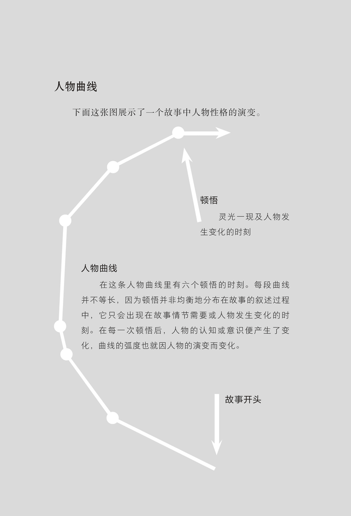

①亨利·詹姆斯（Henry James，1843—1916），继霍桑、麦尔维尔之后19世纪美国最伟大的小说家，也是世界文学史上的大文豪，被一致认为是心理分析小说的开创者之一，是20世纪小说的意识流写作技巧的先驱。代表作有长篇小说《一个美国人》《一位女士的画像》《鸽翼》《使节》《金碗》等。华顿夫人在移居法国后，与他成为挚友。—译者注

②新英格兰地区是指美国东北的一个地区，由缅因、佛蒙特、新罕布什尔、马萨诸塞、康涅狄格和罗得岛六个州组成，是英国殖民主义者最早开发的美洲地区。—译者注

③本斯托克，1994年，第3页。

④本斯托克，1994年，第21页。据信，华顿夫人从小由保姆和家庭教师抚养长大，被剥夺了正常的母女关系，才导致了她之后在艺术之路上的发展以及在婚姻生活中的外遇。（埃里奇，1992年，第6页）

⑤埃尔利赫，1992年，第xii页，以及第三章。

⑥华兹华斯这样描述作家对生活素材的积累：这是一种在宁静中品味情感的过程，一切好诗都是强烈感情的自然流露，来源于在宁静中积累起来的情感。

⑦韦格纳，1995年。

⑧乔治·艾略特（George Eliot，1819—1880）是英国维多利亚时代的著名作家，她的小说清新优美，极富田园生活和大自然的气息，并首次显示了现实主义小说的新特征。但部分读者觉得她的小说冗长乏味，有太多的道德说教，尤其是《罗慕拉》。—译者注

⑨休斯，2005年，第387页（未写明引用）。

⑩刘易斯，1986年，第1322页。

⑪根据埃丝特·隆巴迪（Esther Lombardi）的说法，华顿不仅影响了她那个时代的许多小说家，也影响了许多当代作家。另见科尔德，1985年。

⑫华顿，1911年，第23页。

⑬纳博科夫的《洛丽塔》（Lolita）叙述了一个中年男子与一个未成年少女的恋爱故事。该书曾被禁售，后来再度风靡，衍生出了“萝莉（loli）”一词，在日本引申发展成一种次文化。—译者注

⑭华顿，1928年，第11页。

⑮华顿，1920年，第242页。

⑯科恩在一项颇为有趣的研究中观察到，这些对人物思想的明显标注可能看上去单调无趣。出于这个原因以及为了更为深入地挖掘人物内心，作家们开始从心理叙述（作者从旁观者角度对人物内心的间接阐述）转向直接引用人物的内心独白（人物内心的直接独白）。（科恩，1978年，第38页）

⑰我们很容易由华顿夫人的这些心理描述片段联想到《包法利夫人》中爱玛幻想她可以和她的情人们一起享受浪漫生活的片段。

⑱这里指的是前文伯爵夫人提到的“情妇”一词。—译者注

⑲华顿，1920年，第247页。

⑳华顿，1911年，第19页、第23页。

㉑华顿，1911年，第23页、第103页。

㉒鲍勃·迪伦（Bob Dylan，1941— ），美国著名摇滚、民谣艺术家。2016年，鲍勃·迪伦获得诺贝尔文学奖，成为第一位获得该奖项的作曲家。—译者注

㉓布鲁姆，1997年，第19页。

㉔塞缪尔·贝克特（Samuel Beckett，1906—1989），爱尔兰作家，诺贝尔文学奖得主，创作的领域主要有戏剧、小说和诗歌。他是荒诞派戏剧的重要代表人物，代表作为《等待戈多》。—译者注

㉕詹姆斯·乔伊斯（James Joyce，1882—1941），爱尔兰作家、诗人，20世纪最伟大的作家之一，后现代文学的奠基者之一，其作品及“意识流”思想对世界文坛影响巨大。主要作品是短篇小说集《都柏林人》、长篇小说《尤利西斯》。—译者注

㉖参见金，2006年。

㉗斯坦利·库布里克（Stanley Kubrick，1928—1999），美国电影导演、编剧、制作人，代表作《闪灵》。—译者注

㉘乔伊斯，1916年，第205页。

㉙华顿，1920年，第38页。

㉚华顿，1920年，第40页。

㉛金，2006年，第150页。

# 第7章 萨默塞特·毛姆的创作方法

每当你发现你的写作变得华而不实时，你可以试着读读毛姆的作品。乔治·奥威尔曾说道：“我认为对我影响最大的现代作家是萨默塞特·毛姆，我非常佩服他能直截了当、毫不夸张地讲述一个故事。”毛姆的作品在风格上从来都不矫揉造作、复杂浮夸，因此他被誉为“早期朴素风格大师”①。

萨默塞特·毛姆（Somerset Maugham）于1874年出生在巴黎，双亲在他11岁之前就去世了。随后，毛姆被送回英国，与他冷酷苛刻的伯父一起生活。②尽管为了迎合伯父的要求，毛姆上了医学院，但他总是对写作展现出更多的兴趣。他在23岁那年便已经出版了第一部长篇小说《兰贝斯的丽莎》③（Liza of Lambeth，1897年）。

毛姆在德国海德堡学习时曾与一位年轻男子结成伴侣，后来他遇到了另一位男性情人弗雷德里克·哈克斯顿（Frederick Haxton），这段关系一直维持到毛姆70岁时哈克斯顿去世。毛姆还与茜瑞·威尔科姆（Syrie Wellcome）育有一女。茜瑞当时是个有夫之妇，这桩丑闻直接导致她在1917年和前夫离婚，随后便与毛姆结婚了。这段婚姻于1927年终结。

在第一次世界大战期间，毛姆进入英国情报部门，成为一名间谍。之后，他又搬到了美国，在好莱坞工作。他的文学作品类型非常丰富，包括戏剧、短篇故事、散文和小说。

## 像毛姆一样选择人物

作者不应随意挑选笔下的人物。选择人物最为重要的原则是他们的类型要均衡，以形成鲜明的对照。伍迪·艾伦④最喜欢的关于情节创作方面的书籍是拉约什·埃格里（Laios ⑤ Egri）的《编剧的艺术》（The Art of Dramatic Writing，1960年）。这本书提到，作品中的人物都必须经过精心的编排，“如果所有人物都是同一类型，例如他们都是恶霸，那么整个故事就会像一支只有打击鼓的管弦乐队一样单调怪异”⑥。当然，“为了多样而多样”也非挑选人物的目的，你的目标是让这些人物因为不同而产生冲突。在这一方面，毛姆显然是位大师。

《人生的枷锁》（Of Human Bondage，1915年）里的主人公菲利普·凯里（Philip Carey）是一位医生，也是一个敏感的年轻人。毛姆以自身为蓝本创造了这个角色。而另一位主要角色米尔德丽德·罗杰斯（Mildred Rogers）是菲利普的反面：她傲慢、挥霍、残酷，总是与菲利普发生冲突。事实上，随着他们关系的发展，她变成了一个虐待狂，而菲利普以近乎受虐的快感对她做出回应。“他们似乎总是处于争吵的边缘。事实上，他恨自己爱上了她，因为她总是在羞辱自己。”⑦这两个角色从来没有完美地融合在一起，因为他们总是惹恼对方。

在《月亮和六便士》（The Moon and Sixpence，1919年）中也能看到相同的手法，毛姆以法国后期印象派大师保罗·高更（Paul Gauguin）为原型塑造了主人公。小说中的这名画家名叫查尔斯·斯特里克兰（Charles Strickland），他被描绘成一个冷血无情、只关心艺术的人，对他来说，人类无关紧要。他一点也不尊重他的妻子，甚至为了自己的艺术事业抛下她去巴黎旅行。这部小说的另一个主要角色是二流画家德克·施特略夫（Dirk Stroeve），他是斯特里克兰的朋友。尽管他们都是画家，但两人在性格上刚好相反，在人物的配置上形成了很好的编排。斯特里克兰无情冷漠，施特略夫善良且富有同情心。然而，斯特里克兰恩将仇报，占有了施特略夫的妻子，并因为厌倦而始乱终弃，最后导致他的妻子绝望地自杀—尽管此时施特略夫仍在等待着妻子回到他的身边。还有比这两个人之间的分歧更严重的吗？注意毛姆是如何让这两位画家相互对照，并将其与你作品中的两个主要人物进行比较。扪心自问，你能笃定自己已经创造出了类似的对比吗？只有当答案是肯定的时候，你才会心安理得，无须再对人物的性格进行修正。

## 组织小说的章节

最容易被忽视的小说创作要点之一是在快慢章节之间进行转换。显然，把所有人物行动的章节放在前面，把所有分析的章节放在后面，会导致整个小说的不平衡。⑧将戏剧性的紧张情节与深思熟虑的慢节奏部分相互交替，才会更引起读者的兴趣。

毛姆在他的所有作品中都穿插了快慢节奏。如《刀锋》（The Razor’s Edge，1944年）一书讲述了年轻人拉里·达雷尔（Larry Darrell）追求精神启蒙的故事。在小说开头的一个戏剧性场景里，拉里告诉了自己的未婚妻，他想去求学而非经商，这让她大吃一惊。这一章的戏剧性效果因其未婚妻不愿流露内心的失望而增强了。“她的心脏在疯狂地跳动，陷入了极度的忧虑。”⑨她假装平静地接受了这一消息，但最终决定还是不嫁给他，并主动归还他的订婚戒指。在这戏剧性的一幕之后跟着一个节奏缓慢的章节，女孩平静地向家人和朋友解释婚约已经解除。同样的变换发生在小说结尾。在一个节奏缓慢的长章节里，小说的讲述者听着拉里倾诉他的精神追求。紧接着是两个简短的章节，描述了拉里的其中一个女友索菲·麦克唐纳（Sophie MacDonald）的横死。平静与暴力毗邻，这无疑是作者精心安排的结果。

同样的穿插手法也出现在《人生的枷锁》中。菲利普带着米尔德丽德去剧院，接着送她回家。此时，他正强烈渴求着她。“他不知道该如何度过他的目光能再次在她身上栖息前的时光。”⑩然而，米尔德丽德却冷落了他，他俩分开了，菲利普很绝望。在这些戏剧性的场景之后是一个延展的章节，菲利普反复思考了整件事情并为此感到孤独。然后，在第五十九章的结尾我们再次被推进一个戏剧性的场景—米尔德丽德又一次羞辱了菲利普。显然，快慢节奏之间的交替可以发生在章节内部，也可以发生在章节之间。

这种交替的效果也可以通过章节之间不同的段落长短来实现。⑪段落越长通常意味着节奏越慢。一章全由短段落构成的章节后面可以接着一个全由长段落构成的章节。毛姆在《月亮与六便士》的第五十一章和第五十二章中就运用了这种技巧。第五十一章充满了戏剧性，当中都是简短的段落和对话。它讲述了斯特里克兰如何到达南太平洋的塔西提岛，如何遇到了一位17岁的少女，并扬言要施加暴力，强迫她成为他的女人。在这个快节奏的章节后面是由臃肿的段落构成的缓慢章节，总结了斯特里克兰在之后的三年里与这个女孩的和谐相处。紧接着，又是一个快节奏的章节。在这章中，读者将看到斯特里克兰生活在土著人中间，并被作为他的模特的年轻男女包围着进行他的艺术创作。

## 推动故事的发展

推动故事发展的其中一个办法是将人物置于必须做出艰难抉择的情境之中。读者自然会想知道接下来将发生什么。

毛姆在《刀锋》的故事中段用到了这一技巧。此时的拉里身处农场，他曾遇到两个女人—艾莉（Ellie）和贝克尔夫人（Frau Becker）。其中，贝克尔夫人明显很喜欢他。一天夜里，一个女人爬上了他的床……拉里随后和她发生了关系，他猜想这个人一定就是贝克尔夫人。但他却懊恼地发现，那个人其实是艾莉。这一转折迫使拉里做出决定。读者自然想知道他将如何处理这一情况。

在《人生的枷锁》的第三十章中，毛姆将另一个角色置于被迫做出决定的困境中。16岁的凯西莉（Cacilie）被房东发现和一个亚洲人有染。房东对两人的关系表示反对，并威胁要让这个女孩搬走。凯西莉必须决定接下来要怎么办。在经过多次冲突后，她决定和她的爱人私奔。这场冲突推动了故事的发展，让读者渴望接着往下读，看看女孩究竟会如何面对施加给她的、让她停止与爱人见面的压力。

这本书的中段还有一个更具说服力的例子。菲利普终于受够了米尔德丽德对他的不断羞辱，决定离开她到更为体贴、富有母性的诺拉（Norah）身边。他认为自己是爱诺拉的，因为他们间的关系友好和谐，让他感受到心灵的慰藉。就在当读者们以为菲利普已经忘了米尔德丽德时，她却再次出现了。她向菲利普承认她现在过得很悲惨，因为新情人抛弃了她。刹那间，菲利普对她的所有渴求又重新燃起。他该怎么办？他会选择谁？读者们翻着小说往下读，渴望知道他将如何解决这场矛盾。⑫

除把角色置于他们必须做出决定的情景中外，叙述者还可以通过激发人们对未来事件的好奇心，通过为之后的故事“打广告”的方式让读者抱有期待，以此加快故事的节奏。⑬在《月亮和六便士》小说的开头，叙述者称他非常了解查尔斯·斯特里克兰这个人，并在战争期间登上塔西提岛发现了关于斯特里克兰的秘密——“我发现了他悲剧性的职业生涯中最晦涩模糊的部分，我可以将其揭露出来。”不论是那些对人性有短暂兴趣的人，还是对这位艺术家备感兴趣的人，在看到这里时都被吊起了好奇的胃口，渴望知道更多的故事。什么是叙述者口中最晦涩模糊的部分？这在之后的故事中起到了什么作用？这些野史秘闻什么时候才会在我们的面前揭晓呢？还有比这更能让读者希望从作家身上获取更多讯息的技巧吗？叙述者对于公布小道消息的承诺，推动读者不停地往下阅读。

在小说的第八章中，毛姆再次使用了这一技巧。他告诉我们，斯特里克兰抛弃了他的妻子和另一个女人去了巴黎。这让读者产生了好奇，并开始想象他的妻子会怎么做。她会跟他离婚吗？现在在巴黎的斯特里克兰的生活又是什么样的呢？我们会接着往下阅读，因为毛姆许诺我们在查尔斯·斯特里克兰悲惨的人生中还有更多的事将要发生。

在斯特里克兰逝世9年后，叙事者在小说第四十五章告诉我们，战争危机迫使他流亡到了塔西提岛。这明显是在暗示读者们之前“广告”过的某件事即将揭晓，还有比这更为明确的讯息吗？随后，叙述者顺理成章地在塔西提岛展开调查，很快他发现了那些认识斯特里克兰的人，包括一位诊断出斯特里克兰患有麻风病的医生。医生告诉了叙述者斯特里克兰死亡时发生的事，声称在他生命最后几天里完成的《美丽与污秽》这部作品是在他失明的状态下创作出来的！

你可以使用毛姆的这两种技巧来确保读者的兴趣，并在自己的写作中推进故事的发展。第一种技巧是让你的角色面临二选一的抉择。其中，要记住的关键一点是这个人物必须是在面对某个影响其人生的重大选项时做出抉择，并且这一抉择在某种程度上存在困难和挑战。当拉里发现他和一个他不爱的女人发生了关系时，他必须选择做些什么，这事关他作为一个男人的尊严；当凯西莉的情事被发现时，她必须选择做些什么，因为整个世界都在与她作对，而她做出私奔的决定影响了她的一生；当米尔德丽德回到菲利普身边时，他不得不在她和诺拉之间做出选择，他的决定将改变他的人生轨迹。不要给你的人物过于简单的选项，在他们身上施加困难的抉择才能驱使他们到达人生的岔路口。对读者而言，跟着角色的决定走上故事发展的新方向令人激动兴奋，他们会不断翻阅小说，希望知道故事的后续。

当你使用第二种技巧—向读者宣告将来会发生的事时，记住毛姆总是要确保这件事在小说中具有某种关键的意义，是情节中不可或缺的部分，并会对人物产生重大影响。当叙述者称他本人认识斯特里克兰，并探访了塔西提岛以便进一步了解这个男人时，读者实际上就得到了一个承诺。毛姆告诉我们，“即将发生的事是关于主人公的令人兴奋的细节，这个揭露对理解他至关重要”。当你告诉读者他们应该期待什么，并承诺这一期待的事情有趣并让人兴奋时，他们会带着极大的热情进行阅读。

## 制造惊喜

惊喜是讲故事的关键要素。写作本身就是一个仅揭示必要的部分并将其他部分隐藏起来，最终让读者大吃一惊的游戏。

正当我们以为拉里和伊莎贝尔（Isabel）会幸福时，毛姆却透露道，拉里更感兴趣的事是寻找真理、启蒙和智慧。正当我们以为菲利普·凯里已经满足于与诺拉的关系时，米尔德丽德又再次出现。正当我们以为斯特里克兰在占有了施特略夫的妻子后，似乎找到了一个他真正爱着的女人时，他却抛弃了她，最终导致了后者的自杀。

每次惊喜都会让读者感到震惊，并由此产生更高的阅读兴致。在上述案例中，惊喜都给故事带来了重大转折并揭示了主要人物的形象。当拉里告诉伊莎贝尔，他希望跟世上的智者学习时，她取消了他们的婚约，给予了他自由。读者会好奇拉里接下来的打算。他的人物形象对我们来说也越来越清晰—这的确是一个不同寻常的男人！他拒绝了一个爱他的年轻漂亮的女人到底是为了什么？是为了有机会学习古典文学，学习古人的智慧吗？他到底是一个怎样的人呢？

当米尔德丽德再次出现时，我们和菲利普一样感到震惊。之后，我们更清楚地看清了菲利普的为人：他在渴求着那个对他最为苛刻的女人。也许，他就是这样一个受虐狂。这个惊喜向我们进一步揭示了主人公的人物形象，并让我们兴趣大增。

当斯特里克兰致使施特略夫妻子自杀时，读者不仅感到惊讶，而且急切地想知道在他伤害了施特略夫的当下，他会怎么做，以及施特略夫会怎么做。施特略夫会报复吗？斯特里克兰这个人又是个怎样的怪物呢？一个像这般残忍无情的人是怎么成为伟大的画家的？

只要你的惊喜与故事密切相关，它就会为你的故事增添光彩。注意，毛姆为了达到令人惊喜的效果，并不是简单地让惊喜骤然发生，他总是先确保这些事发生的可能性。你必须确保情节上那些令人吃惊的峰回路转有着充分发生的缘由，并且这些转折是故事不可或缺的部分。例如，米尔德丽德的回归尽管让人感到意外，但在情节上说得通。我们知道此时的米尔德丽德身无分文，并且她也喜欢菲利普，所以在这个节骨眼上，她的出现令人惊讶但也合情合理。我们都知道斯特里克兰是一个畜生，他抛弃自己妻子便证实了这一点，所以尽管我们对他抛弃了施特略夫的妻子感到意外，但其实作者对此早有铺垫。同样，当得知拉里比起婚姻更喜欢学习时，我们感到震惊，但也心里有底，因为在此之前我们已被告知他是一个有智慧、有理想的青年。不论在何种情况下，你都必须确保惊喜已经被提前准备好。

除出人意料的事需具备合理性外，还要让这意料之外的事放大人物的特性。拉里的声明当然体现了他追求知识、寻求精神启迪的性格；米尔德丽德的归来以及菲利普将诺拉抛之脑后并拥抱了米尔德丽德，这再次告诉了我们菲利普是一个怎样的男人；斯特里克兰对施特略夫妻子的遗弃让他残忍无情的畜生形象更为鲜明，也让我们更加看清了这个人的秉性，即便我们（和叙述者一样）不能完全理解他那复杂行为背后的动机。当你记住这些要点时，你准备的意外将会让读者大吃一惊并为之着迷，同时也会让你的情节和人物引发更为强烈的共鸣。

## 将自己代入到作品之中

毛姆喜欢把自己代入到作品之中。他承认“我把我的一生都写进了我的书里”。在某些方面，他是最具自传性的作家之一。他本人就是《刀锋》的讲述者。在这部小说中，他甚至取笑自己，让苏菲（Sophie）称呼他为“道貌岸然的人”。⑭而且众所周知的是，《人生的枷锁》几乎就是一部自传小说，作为医学生的主人公的性格及发生在他身上的闹剧都取材自毛姆自己的人生经历。毛姆幼时的口吃在菲利普身上变成了天生跛脚。阅读这部作品的其中一个乐趣是它提供了一个直接洞察毛姆敏感心灵的近距离窗口。此外，《月亮与六便士》《寻欢作乐》（Cakes and Ale，1930年）也源自毛姆的生活。⑮

在《总结》（The Summing Up，1938年）一书中，毛姆承认，事实和虚构在他的作品中混杂在一起，以致没有办法将它们区分开来。“在我的一生中无论发生了什么事，我都会以这样或那样的方式用在写作里……事实和虚构在我的作品中混杂在一起，现在回想起来，我竟难以将它们区分开来。即便我能记起这些事，我也对记录事实不感兴趣，因为我已经更好地运用了这些细节。”⑯在这里，他承认了作品就是他内心世界的真实写照。

所有作家笔下的故事都是基于他们自身故事的不同方面创作出来的，但有些作家相比于其他人，在写作中更倚重自身的经历。从毛姆将亲身经历代入到作品中，我们可以学到什么呢？有一点需要注意的是，毛姆并没有像寻求轰动效应的新闻记者那样从根本上歪曲或夸大他的经历；相反，他相当忠实地将它们展现出来并写成了小说。⑰当然，当你用这种朴实的方式进行创作时，要避免其中的故事被熟悉的人认出来，他们可能以此起诉你诽谤。你可以通过将两个角色融合为一个角色，或是给他们和人物原型不同的职业或地址进行伪装。

## 像毛姆那样遵循一个严格的时间表

毛姆是一名医生，他的身体状况很好也就不足为奇。由于遵守了严格的时间表（包括早起、定期用温泉疗养身体），他活到了91岁。⑱可能关于毛姆写作生涯最具说服力的事实来自加森·卡宁（Garson Kanin）的观察：“毛姆仔细解释道，不论他身处何方，每天早上都八点钟起床，吃过早餐后便在九点钟坐下写上四个小时。”⑲在这段时间里，他充分挖掘自己丰富的人生经历。同时，他固定的写作时间丝毫不影响他拥有完整的个人生活。在这一点上，他像极了巴尔扎克，后者生活充实，人际关系丰富，但也每天留有固定的时间用来写作。事实上，在给一位年轻作家提建议时，毛姆说道：“如果你想成为一名作家，就必须接触世事变迁，等待阅历自己增长是不够的，你必须出去走走。即便你会时不时磨破你的双脚，但它最终也会成为你的经历，成为磨坊里等待被磨成粉的稻谷。”⑳丰富的人生经历加上有规律的写作习惯，为毛姆创作的包括30多部戏剧在内的作品积累了大量的素材。

毛姆对冥想也很感兴趣。他的诀窍之一是在做日常活动时进行冥想。毛姆可能把这种冥想技巧用在了自己的写作之中，他曾说过，“作家不仅仅是在办公桌前创作，他一整天都在进行着创作。当他在思考的时候，当他在阅读的时候，当他在历经世事的时候，他的所见所闻、所思所感都对其写作有意义，而且他也在有意无意地存储并改造着这些脑海中的影像”㉑。这种对写作持续的全神贯注是一个可以培养起来的习惯。

从毛姆的职业生涯中我们可以学习到两条经验：首先，如果能有规律地进行写作，你将更有可能创造出更多的作品并获得成功；其次，你需要将个人经历融入作品之中，这意味着你要深入生活本身并欣然接受错综复杂的人际关系。当你有这些经验时，你也可以像毛姆一样，对它们进行反复斟酌，并以某种方式将它们融入你的作品之中。对写作的持续关注和投入肯定是有益的，因为它就是一位真正的作家该做的事。

①柯蒂斯，1974年，第245页。

②摩根，1980年，第8—11页。

③他的这部作品曾被指控剽窃。（摩根，1980年，第57页）

④伍迪·艾伦（Woody Allen，1935— ），美国导演、编剧、演员，美国艺术文学院荣誉成员。—译者注

⑤原书中出现两种“拉约什”拼法，分别是Laios和Lajos。—编者注

⑥埃格里，1860年，第114页。

⑦毛姆，1915年，第309页。

⑧在切换快慢章节上，诺曼·梅勒（Norman Mailer）《夜幕下的大军》（The Armies of the Night，1968年）就是一个著名的失败例子。书的前半部分抓人眼球，充满戏剧性，主人公梅勒在五角大楼被逮捕时剧情达到了高潮。然而，下半部分却是对组织（反战、反征兵）游行（并向五角大楼进军这一历史）事件慢条斯理的分析。尽管这本书最后获得了普利策奖和国家图书奖，但相比于第一部分，第二部分的明显不同和枯燥无味，使得出版了该书第一部分“五角大楼的台阶”的哈珀公司拒绝出版第二部分。（迪尔伯恩，1999年，第235页）

⑨毛姆，1944年，第76—77页。

⑩毛姆，1915年，第297页。

⑪布朗和金，2004年，第164—165页。

⑫《人生的枷锁》，第六十六至六十九章。

⑬给未来事件“打广告”这一概念来源于编剧领域。（霍华德和马布里，1993年，第74—76页）广告与预兆相似，都与未来发生的某个事件有关，但预兆只是一种暗示，而广告则是一种期许。

⑭毛姆，1944年，第192页。

⑮梅耶尔斯，2004年，第9页。另见，科德尔，1961年，第37页。

⑯毛姆，1938年，第1页。

⑰要了解其中的不同之处，只需对比与毛姆的生平极为相似的《人生的枷锁》以及亨特·S.汤普森的《恐惧拉斯维加斯》这两本书。后者以汤普森现实生活中的冒险经历为原型，但显然为了达到戏剧性的效果，过分夸大和歪曲了现实。

⑱摩根，1980年，第287—288页。

⑲卡宁，1966年，第33页。

⑳毛姆，引用自摩根，1980年，第509页。

㉑毛姆，引用自西尔弗曼，1999年，第65页。

# 第8章 埃德加·赖斯·巴勒斯的创作方法

这个创造了人猿泰山这一经典角色的男人认为自己的书只不过是取悦大众的消遣读物，但埃德加·赖斯·巴勒斯的影响远不止如此。他是一位能工巧匠，其作品凭借高超的叙事技巧风靡全世界。他对节奏、冲突和浪漫元素的独到运用仍能为想在文学创作中注入活力和激情的当代作家提供宝贵的经验。

埃德加·赖斯·巴勒斯（Edgar Rice Burroughs）出生于1875年的芝加哥，是四个兄弟里的老幺。显然，他拥有家中最小的孩子通常所具有的创造力，创作出了一些冒险小说中最令人难忘的角色。他是众多科幻小说系列的作者，他的作品仍影响着当今的一些顶尖作家。然而，巴勒斯在一开始并未找到自己的谋生之道，他尝试了各种各样的工作，包括经营农场、给他的兄长们打工。有一天，他在一本低俗杂志上读到了一篇文章并对一位朋友说道：“即便是我也能写得比它更好。”他的朋友便怂恿他别光说不练，结果接下来发生的事就成了可载入历史的事。他的第一部小说《火星公主》（A Princess of Mars，1912年）成为有史以来最为成功的科幻系列小说之一。这个系列以虚构世界巴索姆（Barsoom，火星人对火星的称呼）为中心。巴勒斯创作了诸多情节紧凑的故事，其中的大多数都发生在火星、金星等遥远的地方。在那里，复杂先进的文明繁荣兴盛，不同种族相互间争权夺利。在这些故事中，巴勒斯总是设定了一位来自地球的英雄，他了解外星文明和习俗并为自由而战，赢得了属于自己的生存权利。同时，故事中都毫无例外地有一位衣着暴露的美丽公主成为他的爱人。这种套路一次又一次地在巴勒斯的作品中上演，但却很奏效，这让巴勒斯可以放飞想象去创造更多让读者连连拍案称奇的人物、怪物和背景环境。同样的幻想模式也出现在泰山系列小说中，这个系列还被拍成了大受欢迎的电影。

尽管巴勒斯是一位科幻作家，但他的创作技巧可以让所有作家受益。我们将研究他是如何开启一段故事，给人物命名，把握叙述的节奏，充分利用人物间冲突，并营造浪漫的氛围来吸引读者的兴趣。

## 你能从《泰山》中学到什么

在一件事上，埃德加·赖斯·巴勒斯比今天大多数作家做得都要更好—他知道如何正确地开启一个故事。他不会用稀奇古怪、令人反感的人物名字，或是完全陌生的异域世界来作为故事的开篇。即便是主流的文学小说家们也常常陷入这一误区，认为创作了最为华丽、最与众不同的奇幻世界，或是用了最富创意的名字，似乎就能立马吸引读者的注意。然而事实上，他们这么做反而疏远了读者，让读者很难进入故事之中。巴勒斯恰恰反其道而行之，他通常以人们熟知的场景开场，就像一个老朋友搂着你的肩膀，发自内心地在和你交谈。在提及一个完全不同的世界之前，他会先用一个熟悉的世界抛砖引玉。也就是说，在介绍陌生事物之前，先用熟悉的事物打底。他用这种方式让你感受到难得的愉悦，允许你先从一个已知世界出发，再逐步过渡到一个未知世界。他为那些见所未见的新奇事物做好铺垫，并让读者做好心理准备，通过渐进式的过渡让异世界的设定更为可信。

例如，《泰山》系列的第一本书《人猿泰山》（Tarzan of the Apes，1912年）并非以一个会和动物说话的野人开篇。相反，故事的开头讲述了英国的格雷斯托克勋爵（Lord Greystoke）约翰·克莱顿（John Clayton）如何远赴非洲，并与他的妻子一起被困丛林的故事。他们之后有了一个孩子，但被一只母猿猴抱走并抚养长大。这个孩子就是泰山。这部小说阐释了“高贵的野蛮人”这一经典主题，暗示社会的牢笼让人们从善良的本质中堕落。泰山并未接触过西方社会，他强大并且善良，代表着人类原始应有的模样。巴勒斯以泰山亲生父母的冒险经历作为小说的开头，让我们更容易进入到这个奇妙的故事中。当我们看到小婴儿被一只母猿猴抓走时，便停止了对故事合理性的怀疑，随着故事自然而然地读了下去，接受了“人猿”这一设定。

巴勒斯的作品中还有许多运用这一技巧的例子。例如，约翰·卡特（John Carter）系列的第一本小说《火星公主》就从我们所熟知的地球开始讲起。小说的序言由巴勒斯亲自撰写并署名，讲述了他随和的叔叔杰克的故事。这个故事对于读者来说很容易理解，但之后发生的事暗示了接下来约翰·卡特的故事：当杰克叔叔去世时，他要求自己的侄子巴勒斯将他的遗体放入一个“只能从里面打开”的带铰链的棺材里。接着，我们跟随约翰·卡特（以杰克叔叔为原型）的手稿进入了整个故事，并得知他在亚利桑那州勘探金矿时被印第安人追赶并逃进了一个洞穴，之后便在那里昏了过去。到此为止的一切都容易理解，因为约翰·卡特所处的世界对我们来说并不陌生。但紧接着，故事迎来了戏剧性的转变，我们发现卡特转眼之间来到了火星。当然，我们并未因这一突发状况感到手足无措，因为我们仍和在小说一开始就已经十分熟悉的人物约翰·卡特在一起。

除了刚才举的这些例子之外，我最喜欢的使用了这一技巧的例子来自《金星上的海盗》（又译为《金星海盗》，Pirates of Venus，1934年）中的开头。“如果在这个月十三日的午夜，一位穿着白色裹尸布的女性出现在你的卧房，就马上给我回信；否则无须回复此信。”对信中所言内容嗤之以鼻的收件人把它扔到了一边，并将这事忘得一干二净。但到了指定的那一天，那个女人真的出现了！故事就这样把我们从一个普通的现实场景（一个人收到信件）带到一个超现实的星球上，那里习俗诡异，有着相互交战的金星军队以及迷人的外星女人。通过这种方式，巴勒斯像一个老手一样引导读者走进与熟知的现实社会完全不同的异世界中。遗憾的是，他这些精心出版的书籍，现在不能那么容易读到了。如果现在的作家能读到它们，那我们现在的小说可能会以更容易让读者理解的方式开头吧。

## 为什么人物的名字很重要

读埃德加·赖斯·巴勒斯写的书，其中吸引读者的一点是人物的姓名：女性的姓名悦耳动听，男主人公的姓名雄武有力，坏人们的姓名阴险卑鄙。具体而言，主人公总是有一个充满男子汉气概的名字：火星系列的主人公约翰·卡特（John Carter），泰山系列的泰山（Tarzan），金星系列的卡森·内皮尔（Carson Napier），《隐藏之地》（又译为《隐匿人的世界》，The Land of Hidden Men）的戈登·金（Gordon King），卡斯帕克系列（the Caspak series）的鲍文·泰勒（Bowen Tyler）和佩卢西达尔系列（the Pellucidar series）的大卫·英尼斯（David Innes）、阿布纳·佩里（Abner Perry）、杰森·格里德利（Jason Gridley）。女性的名字则和她们的美貌一样动人：《火星公主》中巴索姆的公主德娅·索利斯（Dejah Thoris）、《月亮女仆》（The Moon Maid）的诺埃拉（Nah-ee-lah）、《火星大师》（The Master Mind of Mars)的瓦拉·迪亚（Valla Dia）、《金星上的海盗》的杜瓦雷（Duare）以及其他充满异域风格的女性人名。请记住，人物的姓名贯穿了整本书，因此如果你笔下人物的名字不吸引人，这甚至会有损小说的销量，因为许多人在买书之前通常会随手一翻，粗略地看看是否对其中的内容感兴趣。幸运的是，对名字的这种鉴赏力是可以培养的。这里强烈推荐克里斯托弗·P.安德森（Christopher P. Andersen）的《名字游戏》（The Name Game，1977年），它揭示了名字中存在着潜意识及无意识的心理关联。尽管这本书是为了帮助人们给婴儿起名而创作的，但它对姓名的心理分析对作家而言也有着独特的价值。

## 如何像巴勒斯一样把握故事的节奏

埃德加·赖斯·巴勒斯是位把控小说节奏的大师，但他并不是一开始就知道所有的窍门。事实上，他在获得让读者欲罢不能的技巧前，已经写了好几本书。尽管他的故事情节总是激动人心，但他是在完成了《火星公主》之后才真正掌握节奏上的诀窍。①在其后的小说中，巴勒斯学到了两个用节奏给故事带来强烈刺激感的技巧。任何一个作家都可以将这两个技巧用于故事结构之中来增强故事的节奏感。

第一种技巧我们已经在威廉·萨默塞特·毛姆那里见识一二。毛姆在一个情节紧凑的情景后紧跟着一个戏剧性的停顿，使得“戏剧性的停顿或对比”产生了明显的节奏感。②然而，与毛姆不同的是，巴勒斯并没有放慢故事的节奏，而是从一条叙事线跳入另一条同样扣人心弦的叙事线中，让读者被迫焦急地等待第一条叙事线重新开始。为此，他在主线里加入了其他章节。例如，他在卡斯帕克和佩卢西达尔两个系列中就多次用到这个方法。通过章节的隔断，将其中一个人物留在上一个章节的危险之中，让读者不得不为人物所处的危险境地感到忧心忡忡，直到这个人物的叙事线再次开启。这种方式并未将故事的节奏放慢，但却增强了悬念，并控制了整个故事的节奏。

另一种在文学中极为常见的技巧是在加快某一特定部分的情节后突然暂停，放缓整个故事的进度。通过这种方式，巴勒斯控制了故事发展的速度，让读者沉浸其中并不知疲倦。部分作家故事里的所有要素都沿着一条叙事线开足马力向前狂奔，导致他们没能控制好作品的节奏。要知道，一位在整场比赛中都全速奔跑的田径运动员是不可能赢得胜利的，作家也必须通过变换写作的节奏来达到作品的最大效果。例如，在《火星战士》（A Fighting Man of Mars，1931年）中穿插着一些来自哈斯多城的哈德罗在红色星球上搜寻一位失踪公主的场景。这些节奏缓慢的场景为故事中的紧张气氛做了铺垫，同时也给故事强度带来了层次感，与那些尔虞我诈的斗争、你死我活的战斗及死里逃生的逃亡形成了鲜明的对比。萨默塞特·毛姆也运用这一方法来控制故事节奏，但相比之下，巴勒斯这种节奏上的变化更容易被感知，因为他的作品更多是以人物外在行动作为驱动的。当巴勒斯的故事节奏发生变化时，人物的肢体动作通常也变得明显缓和；而毛姆的作品更多是以人物内心的情感波动作为驱动的，故事节奏的放缓是通过设置让心境发生变化的情景来完成的。比较这两种变换节奏的方法着实有趣，它们对于控制故事的发展都很管用，也都能被运用到各种各样的故事类型中，当然，巴勒斯的方法更适用于动作片。

## 为什么冲突是必要的

巴勒斯是位多产的作家，他的写作速度相当快。约翰·塔利亚费罗（John Taliaferro）在其撰写的通俗易懂的巴勒斯传记中指出，巴勒斯凭借一些久经检验的技巧快速地写作：

● 故事通常发生在一个奇特的地方，在那里有一名奇 男子—例如丛林中的泰山、火星上的约翰·卡特、 身处内心世界的大卫·英尼斯、金星上的卡森·内 皮尔。

● 主人公通常是“一位既有教养又训练有素的勇士”。

● “他总是被一大批野蛮人追赶，并被扔进了一个‘阴 森’牢房。”

● “乐观是巴勒斯所有主人公的特点。”

● “通过斗智斗勇斗力，他最终战胜了对手，走上了回 家的路，或找到了一个更好的新家。”

穿着挑逗性的衣服。”

● 故事中有许多战争、斗争和死里逃生的场景。

● 不会出现性爱场景，但女主角有被强暴的危险：“在 巴勒斯的几乎所有故事中，女主角总是要面对‘比 死亡更悲惨的命运’。” ③

这份巴勒斯所依赖的情节设置技巧清单突显了冲突在故事创作中的重要性。例如，在巴勒斯17天内写完的《飞越远星》（Beyond the Farthest Star，1964年）这本书中，读者每翻两页就能看到一场冲突。这本书讲述了一名战斗飞行员被运往距离地球45万光年的地方，发现自己赤身裸体地出现在波洛达（Poloda）星球上。他被一群身穿红色亮片和黑色靴子的外星人抓住了，并因间谍罪受到审判。随着小说的展开，更多的冲突不断涌现出来并层层升级，主人公发现他所在的整个星球都在打仗，卡帕人（Kapar）和乌尼斯人（Unis）在过去的101年里一直处于战争状态。

在《隐藏之地》（The Land of Hidden Men，1932年）里，戈登·金冒险进入了丛林，冲突就在第一页以人与人相互对立的形式展开了。他的柬埔寨向导因恐惧而拒绝继续带领他向丛林深处前进，于是戈登决定独自前行。看到这里，读者们当然都清楚这将是个错误的决定。随后，在我们面前呈现的是人与自我相互对立的冲突，戈登开始觉得自己冒险进入未知的荒野是个错误的决定。不久，戈登遇到了一头野猪，冲突以人与野兽相互对立的方式再次出现。最后，当戈登与麻风国王（the Leper King）战斗时，又回到了人与人之间的冲突。

拿起巴勒斯的任何一本小说，你都会发现它充满了冲突。主人公被四条胳膊的巨人们追赶，被飞在空中的人追捕，被交战中的部落捕获，被未开化的原始人威胁，被野兽和恐龙袭击，这些一点也不稀奇。他所爱的女人通常会被一个邪恶集团俘获，这个集团的领袖往往是一个贪婪好色的邪恶之徒，威胁着要羞辱她。冲突持续演化，经常会爆发，成为部落、国家甚至不同世界之间的战争。

下面这个例子将说明巴勒斯是如何让主人公不得不与巨大的威胁做斗争而令他身处危险之中的。在《图维娅，火星女仆》（Thuvia, Maid of Mars，1920年）中，主人公卡索里斯（Carthoris）是一位高贵的贵族和优秀的战士，他前去营救被杜萨尔（Dusar）士兵抓走的图维娅。在找到她时，他被迫同时和三个士兵进行战斗。与此同时，另一个士兵将女孩从现场带走了。卡索里斯在杀死了两个敌人后，不得不再次踏上寻找心爱女人的旅途。在经过了一系列冒险后，他借助托尔卡斯国王（Jeddak of Torquas）霍尔坦·古尔（Hortan Gur）的力量找到了她。此时，他不仅要面对抓走图维娅的敌人，还要受到图维娅对他的怀疑，因为她误认为是卡索里斯策划了这起绑架。种种困难接踵而至，直到最后一页，两人才最终走到了一起。

严格来说，这种高密度的冲突在主流小说中并非必要的，但巴勒斯让主人公身处危险境地的方法值得借鉴。从他的小说中，作家可以学习到构建有力情节布局的基本技巧。冲突是推动一个故事向前发展的引擎，如果你发现一个故事的情节正逐渐失去吸引力，那么将主人公置于与某人的冲突中来加大主人公面临的风险并增强其挑战性，会让你的故事重获生机。如果你的故事中的冲突密度能达到巴勒斯的十分之一，并在最后一章（更别提在最后一页了！）解开那些浪漫的纠葛—你将会成为一个叙述故事的高手，并且会对巴勒斯教给你的秘诀感激不尽。

## 如何为你的故事增添浪漫

正如我们在前面提到的，浪漫是巴勒斯大部分故事的核心。例如在《隐藏之地》的第五章中，戈登·金迷上了丛林女孩芙覃（Fou-tan）。“她轻盈身体的一举一动，纤纤玉手的一姿一势，美丽的脸蛋和眼睛里的一颦一笑都充满挑逗。她散发着魅力，而戈登的每一寸肌肤、每一只眼睛、每一个鼻孔都感受到了。”巴勒斯对其他小说中女主角的描写也同样迷人并通常充满诗意。“巴勒斯所用到的‘男女一见钟情’的主题并不稀罕，不过他是第一个把这个主题带入科幻小说里的人。”④在一场场星际冒险中，浪漫元素的出现让故事在超现实的背景下有了现实感。例如，男女主角可能正一同畅游火星浩瀚的死海底部—“希利姆族的塔拉驾驶着飞行器疾驰在希利姆双子城外的赭色海底。”（《火星棋士》，The Chessmen of Mars，1922年）浪漫元素在所有文学作品中一贯的魅力让科幻故事超越了单纯的幻想，使得人们在巴勒斯的故事中品味到了爱情熟悉又新奇的味道，增添了故事的现实感和可信度。

当然，在往故事中添加浪漫情节时，相爱的男女往往不会简单地在一起，他们之间将充满阻碍。⑤例如，在《月亮女仆》中，一位名叫朱利安（Julian）的地球人来到了月球的内部，并遇到了一位迷人的漂亮姑娘，很快他便坠入爱河。然而，他和那位叫诺埃拉（Nah-ee-lah）的姑娘被一种半人半马的残暴生物抓住了，在这一过程中，他竭力保护女孩不受到伤害。随着故事的发展，巴勒斯暗示女孩可能会回应他的感情，尽管如此，这对潜在的恋人在接下来的故事里并未心意相通：起初是因为他俩变成了囚犯，后来是因为女主角对男主角产生了误解（这是爱情中常见的阻碍之一，可参考简·奥斯汀《傲慢与偏见》中伊丽莎白和达西因类似的误会不欢而散）。朱利安告诉我们，“我感到有些不对劲，她似乎在生我的气，但我想象不到是出于什么原因”⑥。在过了大约十页之后，误会终于澄清，但他俩仍不能互诉真情，因为他们正身处险境，被一群试图杀死他们的士兵追赶着。和往常一样，巴勒斯保持了他一贯的作风，直到故事的结尾在所有问题都明朗后，男女主人公才互表爱意，走到了一起。

毫无疑问，在科幻小说中加入浪漫的爱情故事让巴勒斯的小说更具魅力。他的例子强有力地证明了浪漫可以适用于任何故事类型并可以提升故事的吸引力，不论这个故事是多么天马行空。所以你不必在强化男女主人公的性格塑造上迟疑，也不必拒绝在故事中运用浪漫。即便是卡夫卡这样缺乏热情的作家也会在他寓言般的故事中引入浪漫，更别提那些幻想和科幻小说大师也在这么干。因此，可以断言几乎没有哪个故事是无法通过挑起人们对爱情的兴致来增添魅力的。

①卢波夫，1968年，第48页。

②威廉姆斯，1998年，第84页。

③这些写作套路摘自塔利亚费罗，1999年，第18—20页，第65页。

④塔利亚费罗，1999年，第19页。这个主题后来也被其他星际科幻小说作家成功采用，如E. E.史密斯（E. E. Smith）和罗伯特·海因莱因（Robert Heinlein）。

⑤参见福尔克，1983年，第65—67页中《爱情的阻碍》（“Obstacles to Love”）一文。“无论情节多么强烈，除非相爱的阻碍严重到足以把恋人分开，否则这本书就不会吸引人。”

⑥巴勒斯，1923年，第144页。

# 第9章 弗兰兹·卡夫卡的创作方法

卡夫卡令许多人感到困惑。人们读他的书，欣赏他的作品，但却从来没有想到过或许能从他身上学到任何关于写作的知识。我承认这是可以理解的，因为他的风格过于独特。事实上，当我向学生们提出在卡夫卡的作品中是否有可以学习和模仿的地方时，学生们总是抱怨“我可不想写关于人类变成了甲虫或无名氏在官僚机构中挣扎的故事！”正因为卡夫卡是如此与众不同，许多人便断定无法从他身上学到任何东西。但他的奇特之处可能就是他最大的魅力所在，因为这些东西只有从他身上才能学到。正因为卡夫卡独特的风格，本章可能是这本书中最为重要的章节。

诚然，卡夫卡经常被看作一位阴郁沉闷的作家，但我首先建议写作者们带着一种黑色幽默感去读卡夫卡的作品，这样会从中获益。在卡夫卡的小说中，主人公们总是竭尽全力去完成某些看似简单的任务却以失败告终，比如前去和一位官员赴约或去往附近的某个地方。在《审判》（The Trial，1925年）一书中，主人公无缘无故被捕，他竭力冲破黑幕以求免除自己的罪责，但这一切努力均是徒劳。在《城堡》（The Castle，1926年）整本书中，主人公一直在试图进入一座城堡，但最终连一个脚趾头都没踏进去！在《变形记》（The Metamorphosis，1915年）中，主人公突然变成了一只甲虫，却始终不知道为何自己会变成这般模样。普利策奖得主、《波特诺的抱怨》（Portnoy’s Complaint）的作者菲利普·罗斯并不是唯一一个觉得《变形记》十分有趣的人；卡夫卡本人当然也这么觉得。罗斯直言道：“我深受一位名叫弗兰兹·卡夫卡的喜剧家以及他那部诙谐喜剧《变形记》的影响……我曾读到过，他在工作时会时不时发出咯咯的笑声。因为这种对惩罚和有罪的病态专注就是这么有趣！这个故事虽然耸人听闻，但却让人忍俊不禁。”①罗斯的评论提供了一个非常有价值的见解。如果我们从一开始就知道在卡夫卡阴郁的作品背后有这么多的诙谐幽默，我想我们看到的将不仅仅是呈现在眼前的文字，作家们也会发现从他身上可以学到很多东西，包括如何让小说变得幽默有趣，以及如何以寓言的方式描述故事。

弗兰兹·卡夫卡（Franz Kafka）1883年出生于布拉格，与三个妹妹一起长大；然而，他身上却带有“年长的幼子”②气质，与他的父亲之间产生了严重的冲突③。卡夫卡在大学学习法律，毕业后就职于保险公司，经常白天上班，晚上写作。④他最为著名的代表作包括《审判》《城堡》以及短篇小说《变形记》。他的大部分作品都描述了陷入前途黯淡、无可救药的官僚体制中的主人公。“卡夫卡式风格（Kafkaesque）”专指“如梦魇般的感受”或过度的官僚主义。在卡夫卡死后，他的三个妹妹都被送到了纳粹集中营并因此殒命。虽然他无法预见这场灾难，但他的作品向人们预示了现代人心中最邪恶的部分，这无疑令许多人震撼。

在我们进一步了解卡夫卡之前，我们必须承认卡夫卡是一位特立独行的作家，他在内容、形式和风格上都是一位开拓者。他的作品前无古人，后无来者。话虽如此，我们也不要忘记，即便是像卡夫卡这样的创新者，也并非与世隔绝地进行创作。事实上，他深受狄更斯等作家的影响。“他模仿过的对象包括俄罗斯、德国、法国、捷克、美国的作家。”⑤为了将卡夫卡恰当地置于影响了所有作家（及读者）的互文性⑥文本网络中来考量，以及为了展示把一种文本理念作为分析工具对另一种文本产生的影响是多么深刻，这里值得一提的是J. D.塞林格本人是卡夫卡的超级粉丝。在定居新罕布什尔州科尼什镇后，塞林格如饥似渴地读完了卡夫卡的日记，他的《麦田里的守望者》（1951年）一书可能就受到了卡夫卡的影响。⑦

## 卡夫卡成功的秘诀

如果你能像卡夫卡一样着手创作一篇故事，故事的开篇必将充满戏剧性！如果你能像卡夫卡一样在故事开头抛出一个精彩的引子，那么你的读者必然会翘首以盼，从一开始就被牢牢吸引。这就全看你有没有勇气像卡夫卡那样简明扼要地开门见山了。例如在《审判》中，卡夫卡开篇第一句就概述了整个剧情和主要冲突：“肯定有人中伤了约瑟夫·K，因为在一个早上，他无缘无故地被逮捕了。”⑨这段开场白既没有（像巴尔扎克那样）无休止的场景设置，也没有（像狄更斯那样）长篇的人物分析，更没有（像哈代那样）复杂的背景交代。就像“嘭”的一声打开了一道门，剧情立马出现在了眼前。

任何打开《变形记》的人都会被书中的第一句话所震惊，而这句奇特又惊人的开场白正是整本书的前提：“格雷戈尔·萨姆萨（Gregor Samsa）在一天早上从令人不安的梦中醒来，发现自己在床上变成了一只巨大的甲虫。”这是所有文学作品中最为著名的句子之一。如果你在任何一所大学的文学专业课上提到这个句子，大多数人都会告诉你“这是卡夫卡写的！”他们可能喜欢，也可能不喜欢（很少有例外不喜欢）卡夫卡的作品，但他们都知道这就是卡夫卡的风格。

在这两个开场中，卡夫卡做了一件了不起的事。他归纳了故事的核心并总结了整个剧情中的主要冲突。然而，许多作家都害怕这么做，他们更喜欢藏着掖着，等待揭示主要矛盾和故事前提的时机出现。但在某些特定的情况下，比如在恐怖小说、科幻小说，甚至在神秘小说中，开篇第一句其实就可以直击故事的核心。如果它为故事确定了基调，就不必认为它透露了过多内情。

## 卡夫卡的杰出之处体现在他对情节的处理上

卡夫卡是荒诞派的先驱。在研究奇闻轶事的专家叶列阿扎尔·梅莱廷斯基（Eleazar Meletinsky）看来，荒诞是卡夫卡创作的指导原则。

> 卡夫卡小说中的情节和主角都……超越了历史时间。它们有着普遍的历史意义。卡夫卡式的“凡人”代表了全人类，这些“凡人”身上的故事情节描写解释了这个世界。他给主人公的日常生活赋予了一种梦境般的特质：昏暗中的亮光、难以稳定的注意力、变幻无常的本性、与场所不相称的行为，以及突如其来的情爱片段。⑩

汤姆·沃尔夫也认为卡夫卡是荒诞派的创造者，但他是在一次集体研讨中谈论到美国小说最糟糕的特点时做出了这一评论，并且他将现代荒诞作品视为文学中不应该出现的错误。但是在某种程度上，荒诞可以推动故事的发展，作家也可以通过剥离事实中的现实元素来创造普遍性的事物，故事有时也能在这种表现形式下更为有力，因此，卡夫卡的方法在现今仍然奏效。成功运用卡夫卡方法的例子就包括了贝克特、玛格丽特·杜拉斯⑪、达格·索尔斯塔和阿兰·罗布—格里耶⑫的小说。

卡夫卡小说中的主人公总是被困在情节里，并且他们很难让事态有所好转，反而被所处的社会困境和规则反复摧残。从这个意义上来说，不论他多么努力地想要完成某件事，他仍无法摆脱相对被动的状态。他可能会像《地洞》（The Burrow，1928年）里动物化了的主人公那样尝试主动出击，但这么做也仅仅只是加固了他所隐蔽的洞穴罢了。在《审判》中，不论K多么努力，他也“从没有见过安排了他命运的高等法院法官”。⑬这种被动与大多数作家得到的让主人公成为一个“行动者”、一个真正的“推动者和撼动者”的所有建议相反。只要K能顺利完成任何一件事，他就会是一个行动者，但他的首要任务是在《审判》中活下来和进入《城堡》里的城堡。然而在这两本书中，他始终都无法像《地洞》的主人公一样，哪怕仅仅只是前进一步。在《变形记》中，主人公几乎无法移动他那笨重的身体。同样，在卡夫卡的第一部小说《美国》（Amerika，1927年）中，主人公被其他人物“不断地诱惑和虐待”。⑭

所有这些都呈现出了一股梦魇般的气息。的确，卡夫卡作品中的所有情节都“具备一种梦境般的特质，卡夫卡也承认这与他梦境式的内心世界相对应”。⑮但他利用梦境的灵活性（如在走廊上打开一扇门，却进入了一个法庭；或是来到了一个无法摆脱追赶者的地方；或是永远无法找到一个问题的答案）呈现了他自身的创作状态，并以这种表现主义的方式展现了人类的状态。在弗洛伊德看来，人类的思维是以一种非线性、像做梦一样的方式进行思考。而卡夫卡的作品如实地反映了这种思维方式。这就是为何他的作品具有普遍性意义并具有广泛吸引力的原因。

卡夫卡用这种表现主义方式撰写情节。但他并未全盘接受德国表现主义运动中“正宗”的表达方式，反而认为它们过于浮华。尽管如此，他的作品仍具有梦幻般的特质，这使它们同汉姆生的作品、童话寓言、神话有诸多相似之处。在许多方面，它和约翰·班扬的宗教寓言小说《天路历程》也很类似，后者讲述的是一个男人通往天堂的朝圣之旅。但卡夫卡的小说在表明一物象征另一物上，并不具有像《天路历程》中主人公所走的路即是通往天国的路那样明确的寓言意义。相反，卡夫卡寓言中的寓意是灵活可变的，对于读者的个人理解也更为开放。在卡夫卡的故事中，主人公们生活在一个充满威胁的、怪诞陌生的世界里，他们往往在这个怪诞的世界里越陷越深，最后不得不接受它就是真实。读者在间接经历中被拽入这个梦境，透过主人公的眼睛感受它。卡夫卡通过这种方式，让故事情节带有一股强烈的寓言色彩，并带领读者领略现代人的荒诞处境。

## 如何像卡夫卡一样搭建故事的结构

所有人都知道卡夫卡的作品将读者带到一个陌生的荒诞世界。但很少有作家意识到，当你有着类似的故事情节，特别是当你的故事线单一并与主流格格不入时，可以尝试研究卡夫卡的文学手法，看看其中是否有任何能帮助你改善自身作品的技巧。例如，贝克特就意识到，要构建像卡夫卡那样的故事，就必须让主人公陷入窘境：他必须进入一个陌生的新领域，并为此感到困惑，同时每每在寻求理解和完成某件事的过程中因遭到挫折而感到沮丧失落。弗兰纳里·奥康纳的作品就被认为极具卡夫卡风格⑯，因为她的主人公〔例如，处女作《智血》（Wise Blood，1952年）里的主人公黑兹尔·莫茨（Hazel Motes），以及《暴力夺取》（The Violent Bear It Away，1960年）里的主人公塔沃特（Tarwater）〕无法接受自己住在一个他们所认为的陌生世界里。⑰

乔治·奥威尔的《1984》在很多方面也与卡夫卡的风格类似，因为它将主人公置于无法取胜的逆境之中。为了便于你更好地理解掌握卡夫卡建构小说的方法，这里将对比奥威尔和卡夫卡风格的异同。相同的是，两者作品中的主人公都与其所生活的世界和社会格格不入。不同的是，“奥威尔式”的风格“描写的是语言因服务于权力变得扭曲和腐化……也可用来描绘政府压制和国家暴力下噩梦般的世界”⑱，而“‘卡夫卡式’一词则被用来描述荒诞、冷漠、怪异的都市景观，也可用于指代无名小卒对官僚主义的抗争”⑲。从这一区别可以看出，尽管主人公都与其所处的世界发生了冲突，卡夫卡的故事结构更强调主人公与摧残他的噩梦般的灰色地带对抗，或者与由官僚体系和社会规则构成的复杂系统进行的对抗。

对作家而言，理解卡夫卡风格的一个有效方法是按照克里斯托弗·布克的《七种基本情节》里所建议的思路去分析他的作品。例如，《审判》是自我 “探索与归来”⑳情节的黑暗版。刘易斯·卡罗尔（Lewis Carroll）的《爱丽丝梦游仙境》（Alice's Adventures in Wonderland，1865年）则是此类故事的另一种版本。在这类故事中，主人公进入了一个陌生的世界，这里发生的一切都变得越来越奇特诡异，故事中的其他人物或发生在主人公身上的事件开始对他/她露出獠牙。换句话说，随着情节的推进，怪异感和危险也随之增加。在“光明”的版本中，主人公（例如爱丽丝）最后历经险阻成功回家。而在“黑暗”的版本中（例如《审判》），主人公“依然被困，永无归途”。㉑布克的分析与诺思罗普·弗莱（Northrop Frye）的观点类似，他认为卡夫卡较少关注线性的故事情节，而更多关注“精神上的事件”，弗莱认为《城堡》描述的就是一场“焦虑的噩梦”。㉒

现代作家能从这种情节建构中学到什么吗？答案就在20世纪一些最受尊敬的作家作品中。正如我们前面提到的，弗兰纳里·奥康纳用“卡夫卡体”进行创作，她的主人公都是所处世界的局外人，他们对世界的看法异于常人。索尔·贝娄㉓的《受害者》（The Victim，1947年）也是一部“卡夫卡式小说”，小说中的主人公觉得自己被困在了纽约，被其他人物以及对他生病侄子的责任所束缚。㉔菲利普·罗斯的《波特诺的抱怨》（1969年）也包含了类似的主题，并且“把对被害感和负罪感的卡夫卡式思考推向夸张的极限”。㉕尼尔·盖曼㉖的《乌有乡》（Neverwhere， 1996年）将主人公推入位于伦敦地下的奇特世界。成功运用了卡夫卡情节创作方法的当代作家名单远远比上述的要长，其关键因素在于黑暗版本的“探索与归来”情节在现代已经有了良好的读者基础。如果你正在写此类小说，或者你的小说中带有卡夫卡的元素，那么没有比卡夫卡流派的创建者卡夫卡本人更好的老师了。

例如，你可以直接清楚地从卡夫卡身上学到如何将主人公推入一个像《审判》中那样奇怪荒诞世界的技巧。卡夫卡让主人公为身处怪诞的世界而辗转反侧，就像卡罗尔让爱丽丝为自己掉入了奇境而百般苦恼一样。如果你的主人公也进入一个陌生的环境中，你可以用同样的方法让他对奇特的新环境感到困惑烦恼，以及苦苦思索自己为何陷入其中，自己曾经做过什么。你还必须论证你的主人公是否能够脱离这个怪诞的世界。如果不能，那么你的小说就会像卡夫卡的一样是个“黑暗版”的故事，你的主人公将被永远地困在陌生世界里。卡夫卡给了你结束这种黑暗故事的方式—在《审判》的结尾，K被处决了。如果你也敢给予你的主人公同样悲惨的命运，卡夫卡将启发你的灵感。塞林格对《麦田里的守望者》结尾的处理与卡夫卡如出一辙，霍尔顿最后发疯了。同样，奥威尔《1984》的结局也是一样的阴郁，因为主人公史密斯失去了他的自由思想和之前的所有信念。

## 如何将卡夫卡作为作家最大的缺点变成你最大的优势

卡夫卡作为作家的一个缺点是他没有为他的人物提供背景信息。例如，我们对《审判》中的约瑟夫·K知之甚少。在卡夫卡的小说中，“所有物体的存在只与中心人物有关联……对人物过去的经历、所处的环境，甚至一组特定心理压力的充分描写，在卡夫卡的小说里是不存在的”㉗。这种贫乏的背景信息与作家们在现代小说及相关课程中所学到的背道而驰。这些小说或课程鼓励作家去丰富人物的形象，甚至鼓励他们就此进行练习。

卡夫卡的另一个缺点是未能描绘出人物间完善的浪漫关系。他的小说中没有D. H.劳伦斯和乔治·艾略特笔下相爱的情侣。这里没有激情四射的情爱，即便这样的桥段出现在了他崇拜的作家陀思妥耶夫斯基的作品中（如《罪与罚》中的拉斯柯尔尼科夫和索尼娅，《白痴》里的梅诗金公爵和纳斯塔霞），以及狄更斯的笔下（如《远大前程》里的皮普和艾丝黛拉，《大卫·科波菲尔》里的大卫和朵拉）。“但是，”你可能会说，“卡夫卡本来就不打算在作品里涵盖这种浪漫啊！”尽管如此，人际关系，特别是浪漫的人际关系以及维持它们的能力，构成了文学作品中的大部分内容。它们在卡夫卡作品里的缺席，或以极其微不足道的形式出现，无疑是让他的作品显得如此沉闷的原因之一。在他的作品里，情色的片段永远不会持续，人际关系充其量也只是昙花一现。

然而，卡夫卡作为作家最大的缺点不是其作品中浪漫关系的缺失，而是中心人物与其他人物之间联系的缺失。例如，《审判》里的约瑟夫·K没有朋友。他和莱妮（Leni）间的短暂调情空洞且没有结果，因为“他后来被告知她能爱上任何一个受到指控的男人”㉘。没有任何人会在任何重要的事上帮助他。在《城堡》里，K也是一个孤独的人。他的两个助手对他十分敷衍，旅店老板的作用微乎其微，出现在他身边的女人们不愿帮忙，所以K可以被认为是孤独一人活在这个世界里。他不仅没有任何对他而言有意义的关系，甚至都没有主动去寻求这种关系。当他试图与一个女人搭上关系时，也只是为了别有用心地达成进入城堡的目的。即便如此，他所遇到的女人们甚至都没有帮助他实现这个小小的目标。同样在《变形记》中，变成巨大昆虫的格雷戈尔遭到了全家人的抵触和嫌弃，他们觉得他令人恶心、反感。就连曾与他关系最为亲密的妹妹到最后也开始感到厌恶。格雷戈尔就像卡夫卡作品里的大多数主人公一样，没有亲近的人，甚至没有任何有意义的关系。

克里斯托弗·布克甚至暗示道，卡夫卡小说中的主人公由于缺乏人际关系，与精神错乱者相似。㉙那么，卡夫卡的这些“缺点”对你会有什么帮助呢？如果你希望写一个虚构的寓言故事，那么你可以通过减少人物的背景信息、剔除浪漫的元素、删减人物的人际关系，以此突显主人公的格格不入来达到同卡夫卡小说一样的效果。塞缪尔·贝克特在《莫洛伊》《马龙之死》《无名氏》中成功地运用了这一方法。达格·索尔斯塔也在《羞怯和尊严》中取得了类似的成功。

如果你要讲述一个关于在某种意义上异化了的主人公进入怪异荒诞的世界并且随着情节发展承受了莫大威胁的故事，那么你完全可以向卡夫卡请教。你甚至还可能以某种方式调整卡夫卡的风格。比如，让主人公有一段强烈又浪漫的感情；比如，试着充实主人公的身份背景；再比如，让主人公拥有一个可以帮助他的盟友或朋友，至少这位朋友能够理解他的困境并给予同情。这样，卡夫卡作为作家最大的缺点—人物之间缺乏直接的联系—也许能成为你最大的优势。实际上，你甚至还可以试着重写卡夫卡的寓言故事。

例如，《城堡》里的约瑟夫·K在酒吧的地板上与一个女孩发生了关系。不久，他又与另一个女孩发生了关系，导致了前者的嫉妒。这使得他不得不花费大量的时间来安抚这两人。这些事件通常不会受到关注，因为评论家更关注的是卡夫卡作品中所呈现出来的官僚主义。但对于一个想要效仿他风格的作家来说，可以从他停下的地方开始，在这些梦魇般的作品里加入些许卡夫卡式的浪漫。当然，贝克特和达格·索尔斯塔并不是为了这个目的去模仿卡夫卡风格的，但仍存在一些作家重拾卡夫卡所落下的部分并用一种新方式去完善这些故事的可能性。这就是效仿的含义，你可以比你效仿的对象更往前走一步。D. H.劳伦斯就比他的仿照对象乔治·艾略特往前走了一步，对诸如夫妻的眼睛等细节进行刻画。㉚你也可以效仿卡夫卡，增加浪漫等其他相关元素。通过这种方式，效仿就成为你和效仿对象之间的一场竞赛，在这场竞赛中，你正在追赶甚至试图超越对方。

总之，我所说的这一切并不是在敦促你放下手中的写作去重写卡夫卡的作品，或是盲目地仿照他，而是为了向你展示学习其他作家写作风格的可行性。达成这一步的关键在于模仿，它可以让你从任何一位作家身上汲取其中的优点，化为己有，并改进其余部分。这就是为何古罗马著名教育家昆体良认为我们应该同最好的作品进行赛跑，换句话说，我们要试着改进这些作品然后超越它，而非盲目地仿照、复制甚至是剽窃。所有提倡模仿的人都认为，我们应该完善模仿对象的写作风格，“模仿是我们追赶模仿对象的方法；一旦我们赶上了目标对象，之后我们应竭尽全力超越这个目标……但需要强调的是，这种改进和超越的态度应始终融入模仿的过程中”㉛。如果你不开始模仿，你就无法达到追赶甚至超越的目的，而超越应该成为你永恒的目标。

①罗斯，1992年，第39—40页。

②“Honorary Laterborn”这个词由弗兰克·苏洛威（Frank Sulloway）发明，用来描述那些由于与父母之间巨大的冲突，而具备了幼子特征（包括创造力和亲和力）的长子。（苏洛威，1996年，第123页）

③关于卡夫卡与其父的冲突可以参见卡夫卡的作品《判决》和《致父亲的信》。—译者注

④西塔提，1990年，第100页。

⑤斯皮尔卡，1963年，第39页。

⑥“互文性（intertextuality）”，这一概念首先由法国符号学家、女权主义批评家朱丽娅·克里斯蒂娃在其《符号学》一书中提出。其基本内涵是，每一个文本都是其他文本的镜子，每一个文本都是对其他文本的吸收与转化，它们相互参照，彼此牵连，形成一个潜力无限的开放网络，以此构成文本过去、现在、将来的巨大开放体系和文学符号学的演变过程。—译者注

⑦“霍尔顿的冒险历程和（《审判》里的）约瑟夫·K的世界之间出现了平行，这种平行表现为霍尔顿从未与他遇到过的任何一个人有过真正的接触……就像一个精神病患一样，他总是在两种情形间来回转换：将世界上几乎所有人都视为令人恼火的伪善者并蔑视他们……然后，好像在努力弥补一样，又夸张地表达出即便如此他还是非常喜欢或想念他们。”（布克，2004年，第394页）

⑧达格·索尔斯塔（Dag Solstad，1941— ），挪威作家。—译者注

⑨卡夫卡，1925年a版《审判》，第3页。

⑩梅莱廷斯基，2000年，第317页。

⑪玛格丽特·杜拉斯（Marguerite Duras，1914—1996），法国作家、电影编导，代表作有《广岛之恋》《情人》等。—译者注

⑫阿兰·罗布—格里耶（Alain Robbe-Grillet，1922— ），法国作家，“新小说”流派的创始人，代表作《去年在马里昂巴德》《窥视者》等。—译者注

⑬梅莱廷斯基，2000年，第322页。

⑭基尔希，2009年，BR，第23页。马克·哈曼（Mark Harman）翻译的新版《美国》颇受欢迎，对于对卡夫卡散文风格及其对标点符号的运用感兴趣的作家来说，这是本必读物。这版译本也是除阅读德文原文外的最佳读物。

⑮赖斯，1978年，第134页。

⑯戴维斯，1953年，第24页。

⑰另一部现代“卡夫卡式”小说是本·马库斯（Ben Marcus）写的《著名美国女性》（Notable American Women）。

⑱古登，2008年，第141页。

⑲古登，2008年，第101页。

⑳“探索与归来（Voyage and Return）”是《七种基本情节：我们为何讲述故事》里荣格学说研究者克里斯托弗·布克在对各类传说模式及其心理学含义进行总结后，归纳出的小说中存在的七种基本情节的其中一个。它意指主人公前往陌生的领域，在克服重重困难后最终归来，并且除了其神奇的经历之外没有带回任何东西。该情节的人物代表为《奥德赛》里的奥德修斯、《爱丽丝梦游仙境》里的爱丽丝、《格列佛游记》里的格列佛。—译者注

㉑布克，2004年，第393页。

㉒弗莱，2003年，第40—41页。

㉓索尔·贝娄（Saul Bellow，1915—2005），美国作家，被称为美国当代文学发言人，代表作《奥吉·马奇历险记》《洪堡的礼物》。—译者注

㉔贝尔科维奇和帕特尔，1994年，第144页。

㉕琼斯和南斯，1981年，第81页。

㉖尼尔·盖曼（Neil Gaiman，1960— ），英国作家，被视为新一代幻想文学的代表，代表作《美国众神》。—译者注

㉗罗尔斯顿，1986年，第28页。

㉘布克，2004年，第393页。

㉙布克，2004年，第394页。

㉚乔治·艾略特擅长对人物外貌和内心的描写，她的书中有成段的对人物细致入微的刻画。—译者注

㉛加尔布雷斯，2000年，第77页。

# 第10章 D. H.劳伦斯的创作方法

在谈论劳伦斯这位20世纪最具争议的作家之一时，需提醒各位注意的是，熟悉他的作品内容可能会怂恿一些人去冒极端的风险并走入危险的领域，甚至犯类似的文体错误。劳伦斯是一位具有魔力的作家，他的小说结构常常极度不平衡，但他那份冒险进入新领域的叛逆可能正是激发和唤醒一个沉睡中的天才所必需的。事先告知各位，慎重的判断力和良好的品位是在模仿劳伦斯的每一步上必不可少的品质，因为那些追随劳伦斯的人将走上一条狭窄的道路，这路上四处潜伏着结构不平衡、文体冗余及其他陷阱。然而，对于那些敢于冒险的人来说，这次跋涉可能会令人感到振奋和鼓舞。

D. H.劳伦斯（D. H. Lawrence）出生于1885年，是一个煤矿工人和一位小学教师的孩子，在兄弟姐妹中排行中间。他的家庭对他早期的作品有着深刻的影响。在这些作品中，男人常常未受到过教育，而女人则是智慧、教养和美丽的典范。他的第三本小说《儿子与情人》（Sons and Lovers，1913年）着重讲述了他与母亲间的亲密关系。煤矿在这个故事中起到了重要的作用，主人公保罗·莫雷尔（Paul Morel）的父亲就在那里工作。而米丽安（Miriam，保罗的女友）的形象则以劳伦斯年轻时的女友杰西·钱伯斯（Jessie Chambers）为原型。这部小说提供了劳伦斯在青少年时期的生动画像。《努恩先生》（Mr. Noon，1920年）也同样地描绘了劳伦斯与其妻弗里达·威克利（Frieda Weekley）的关系。①弗里达为了劳伦斯，离开了她的丈夫和三个年幼的孩子。她与劳伦斯的私奔体现了劳伦斯对女性的某种独特魅力。劳伦斯将他所知晓的所有人际关系都写进了书里，而这些关系和现代文学里的相当不同。

《查泰莱夫人的情人》（Lady Chatterley’s Lover，1928年）在美、英及多个国家和地区被封禁多年。在劳伦斯看来，性应该被公开讨论。在那本书中，他的用词对于那个时代的人来说过于直白和令人震撼。在政府的不断侵扰下，劳伦斯和他的妻子为了寻求政治上的自由，以及为了找到更为温暖的地方来治疗他的肺病而被迫经常搬家。在此期间，他们在新墨西哥州的陶斯农庄待的时间最长。

## 为什么没有人能写出像劳伦斯那样的对话

除了理解正确的对话形式之外，劳伦斯还具备将对人物的直观理解落在纸上的独特能力。这两个要素对构成精彩对话必不可少，学习劳伦斯的技巧甚至可以帮助初学者们创作出生动、富有智慧的对话。

当然，首要的是掌握正确的对话形式。一般这需要写出几句对话内容，并指出发言者是谁。劳伦斯在撰写人物对话时运用了很好的对话形式，但他也超出常规，在进行人物对话时插入了对人物的描写。《恋爱中的女人》（Women in Love，1920年）是一本关于杰拉尔德（Gerald）和葛珍（Gudrun）、鲁珀特（Rupert）和厄休拉（Ursula）两对男女之间的浪漫爱情故事。小说的大部分魅力源于劳伦斯对人物对话的把控。例如，第六章的其中一个场景便展现了劳伦斯将生动的细节加入主要人物对话间的精湛技巧。杰拉尔德和鲁珀特正在一家咖啡馆里和达林顿小姐（Miss Darrington）聊天，杰拉尔德觉得这位小姐很有魅力。对话的关键在于劳伦斯对对话者的描述：

> “你能在这里停留多久呢？”她问道。

> “一两天吧，”他回答，“没什么急事。”

> 但她仍然用温柔的双眸望着他的脸，这眼神是多么的奇特，令他激动难耐。他的自我意识非常强烈，立马为自己的魅力深感喜悦。他感到浑身血液沸腾，仿佛能释放出惊人的能量。他觉察到这个姑娘那双蓝色的眼睛正盯着自己。她的眼睛很美，如鲜花般的眼睛睁得大大的，赤裸裸地看着他。瞳孔上似乎飘浮着一层如梦幻般易碎的彩虹，就像有薄薄的一层浮油七彩斑斓地附在了水面上。②

这段关于杰拉尔德对女孩的反应以及他注意到女孩那双充满爱意的眼神的细节描写，在一般的人物对话中并不常见。劳伦斯的独特之处就在于他能找到正确的情感语言去描绘人物的眼睛、外貌和表情等细节。并且他知道这其中哪些要素是相互关联的，比如杰拉尔德的情欲、女孩对他长时间的凝视以及他们对彼此的想法。同时，他还知道用什么样的词去恰到好处地表达他们现在的所思所想。可以看到，他有着极好的语感去恰如其分和点到为止地展现人物，用词充满了情感和言外之意。那么，他是从哪儿学到这样的技巧呢？很显然他并非从其他小说家身上学到这一点的，尽管他崇拜并模仿过的哈代和乔治·艾略特的作品中有关于恋人的描述。③

劳伦斯曾告诉过他的女友杰西·钱伯斯，他打算如何创作《白孔雀》（The White Peacock，1911年）这本小说。

> “通常这类书以两对恋人为主体，并聚焦于他们的情感发展，”他说，“乔治·艾略特的大部分作品都是基于这个构思创作的。即便我不想要情节并会对此感到厌倦，也可以先试试从两对恋人入手进行创作。”④

他在《恋爱中的女人》中采用了同样的构思，其中，姐妹花厄休拉和葛珍与鲁珀特和杰拉尔德分别相爱。但劳伦斯更关注的是人物间的关系而非故事情节，这使得他的小说有一种零散的感觉。不过，他通过对人物内心和思想的深入探索弥补了这一不足。阅读这部小说的一个乐趣在于发现每一个章节中都充满了对人物情感关系进行深入刻画的场景。劳伦斯显然从他的前辈那里学到了一些结构技巧，但他又自行发明了构建精彩的人物对话的方法。

## 构思和写草稿

和大多数成功的职业作家一样，劳伦斯的小说并非一挥而就，而是经过了反复的修改。但与大部分作家不同的是，劳伦斯对修改的过程更加挑剔，他的作品往往是以一种非常规的方式完成的。他会快速地写出一个初稿。接着，他再写第二稿，但这并非初稿的修订版，既不像福克纳一样对结构进行重新布局，也不像海明威一样对文本进行提炼，而是从里到外对小说进行重写。“劳伦斯并非仅仅在修改草稿，他经常从头到尾重新写了一遍。”⑤这听起来很不可思议，他会从第一页开始，在空白页重写整个故事！有时，他这样做是为了修正人物间的关系和动机。例如，《查泰莱夫人的情人》就有三个发行版本，“在每个版本中，林园看守人和查泰莱夫人幽会的动机都不同”⑥。

《恋爱中的女人》有着更为复杂的版本演变。事实上，“三十年来，学者们一直都在研究这本书里的文本变化！”这在某一方面看上去很好笑，但这个研究对作家来说具有很好的启发价值。这本书最初写于1913年，名为《姐妹们》（The Sisters）。而在那年，劳伦斯重新翻写了这本书，但当他写到第380页时，他对第二个版本感到不满意，便停笔了。随后在1914年年初，他又写了第三个版本，题为《结婚戒指》（The Wedding Ring）。实际上，他曾把这个版本寄给了他的出版商，但由于战争的爆发，该书并未立即出版。于是，他又开始重写，在1914年到1915年期间，用同样的材料写了一份名为《虹》（The Rainbow，1915年）的浩繁手稿。到了1916年，他重新写了另一份手稿，并将它打印了出来。之后，在这份手稿上进行修改。“小说的百分之十是完全重写的……剩下的百分之九十也被狠狠地修改过。”⑦换句话说，劳伦斯对这本书至少重写了五遍。为什么劳伦斯要不厌其烦地进行修订和重写呢？评论家认为，部分原因是他手头上浩如烟海的素材已经够他写两本书了。另一部分原因在于，他想要改变一些既定的人物关系。“关键性的人物关系—尤其是鲁珀特·伯金与杰拉尔德、伯金与厄休拉之间的关系—都发生了巨大的变化。”⑧

从劳伦斯创作小说的方法中你可以学到的最为重要的一课是，当你完成了第一稿后，或正在写第二、第三稿时，你可能会对已经写出来的内容感到十分诧异。尤其在你回顾文稿时，可能对此感到并不十分满意。你也许会因此决定重新调整人物之间的关系，或进行其他重大的修改。你可能会觉得像劳伦斯那样重新开始创作这本小说可能更为容易；你也可能会觉得在原稿上进行大规模改造更为简单，因为电脑上的办公文档让这一过程变得便捷。但不应排除在必要或合适的时候采用劳伦斯的方法重新开始写作。

正如评论家指出的，“在劳伦斯的故事中，情节从来都非首要”⑨。事实上，劳伦斯曾直言不讳地对杰西·钱伯斯说，他不想要什么情节。但他的小说的确采用了一些经典的情节方法（包括冲突及冲突的解决），这些方法在你进行创作时会很有帮助，特别是在创作聚焦人物关系的小说时。当然，劳伦斯大部分时间都在进行自由创作，利用人物和成对的人物关系来开启一本小说，并在整本书里放飞他的想象。他最喜欢的方法是，在没有过多提纲限制的情况下根据自己的喜好写出一些场景和章节，然后再回顾这些素材进行修改。许多作家也用这种方法进行写作，你也可以进行尝试，前提是你不会因为无法把握故事的走向感到焦虑。当然，也有很多作家并不知道在他们下笔后，故事的高潮或矛盾的解决方案会是什么。对此，劳伦斯采用了一个名为“角色自我意识”的技巧，“在作者让人物变得鲜活的过程中，他们开始有了自我，能说一些、做一些作者在一开始写小说时都不知道他们会说的话、会做的事”⑩。如果你也能放手，像劳伦斯一样让角色活出自我，你就会发现他随心所欲和零碎松散的结构在描绘人物情感上十分到位。在此，故事情节退居第二位，撰写初稿也变得更为容易。

## 劳伦斯是如何在最简单的场景中创造刺激的

即便劳伦斯着重描绘的是人物间的关系而非动作场景或枪战画面，他还是给读者带来了极强的感官刺激。在《儿子与情人》中，他加入了一些意想不到的男女调情场景。例如，在第七章中，保罗近乎是强迫他的精神伴侣米丽安学代数，他们坐在桌旁开始上课。不过，没过多久，情况就变成了像爱洛漪丝和阿贝拉尔⑪一样的局面，这位年轻男子感受到了女孩的魅力。“看见她任凭他的摆布坐在那儿，嘴巴张着，眼睛圆睁着，浅笑中露出一丝害怕、抱歉和害羞，他顿时血液沸腾。”在第十二章中，保罗开始了与已婚妇女克拉拉·道斯（Clara Dawes）的婚外情。婚外情始于单纯的约会，之后他便渴望着她。劳伦斯驾轻就熟顺着主人公保罗的思维，呈现出他情感的激情一面。“他有些神志不清。他觉得假如星期一不很快来临的话，自己就会发疯。到了星期一，他就可以再看见她了……但他简直无法忍受这期间漫长的等待。”在这章的结尾，两人走过泥地后，保罗为克拉拉擦靴子，然后克拉拉吻了他。“他跪在她的脚边，用一根树枝和一把杂草擦着靴子上的泥巴。她把手埋进他的头发里，把他的头扳过来亲吻着。”即便是最简单的行为也因劳伦斯对爱意萌发的男孩的感受和行为细致入微的观察和刻画变得强烈。这种对男女关系细致入微的观察是劳伦斯后续的所有作品的特征。

在《虹》中，他以同样的方式对16岁的厄休拉和她21岁的情人斯克里宾斯基（Skrebensky）之间的关系进行了刻画，创造出了情感极为强烈的场景。在这本书中，我们可以看到劳伦斯在深入展现人物间的亲密感情上更为自信，人物的内心独白也变得更为强烈。例如，在第十一章中：“她一动不动、束手无策地站在那儿。然后他的嘴靠近了，紧贴着撑开了她的唇，一股炽热的、令人浸透的情感从她的体内涌起。她向他张开了嘴唇，在酸楚的漩涡中将他拉得更近，让他更为深入地亲吻着，口水不断涌上来沾湿自己，沾湿自己，但又十分柔软，哦，柔软得似巨浪一样无法抗拒，直到她带着有点失控的哭声挣脱开了。”这段文字反映出劳伦斯在文字上的过度重复，但感叹词“哦”的使用、句子的长短、标点停顿，给这一情景增加了令人窒息的效果。

《查泰莱夫人的情人》通过对主角及其情人林园看守人之间情爱关系的描写创造了激情场景。当查泰莱夫人想到那个令她神魂颠倒的男人时，劳伦斯用尽浑身解数来展现她的激情。例如，在第十章中：“她已经沉醉在她温柔的美梦里……在她的身上，在她的所有血脉里，她都能感受到他和他的孩子。他的孩子就在她的血脉之中，像曙光一样温暖着她。”这种情感描写，通过劳伦斯在重复重要词语上的天赋（也有人说是累赘），在略微重复之余显得极富创造性。这些华丽的片段贯穿了整本书，使它们拥有了力量和强度去超越情节可以创造出的简单事实。正如许多评论家注意到的，劳伦斯关心的始终不是情节而是人物，以及通过激情展现出来的他们之间的关系、感受和欲望。

在《恋爱中的女人》中，情侣间的强烈情感达到了顶峰。其中一对情侣葛珍和杰拉尔德陷入了争执，这场争执已经超越了他们间的浪漫关系，涉及男女之间的根本竞争。而厄休拉与鲁珀特之间的关系尽管也如此强烈并充满激情，但显得更为平静。“鲁珀特和厄休拉的关系是在相互探索之下增进的，而杰拉尔德和葛珍的关系却持续出现强烈的对立，仿佛一个人就必须支配另一个人似的。”⑫从第八章开始，像下面这样的描述就贯穿了整个故事，让人物鲜活了起来：“伯金就像一只寄居蟹，从壳里看到了厄休拉在遇到挫折和孤立后仍然有着炫彩夺目的光芒。她身上藏着一股危险又迷人的力量，像一朵生命力极强的花蕾，奇特但毫无意识地绽放。冥冥之中他被她吸引着，察觉到她就是他的未来。”这样的描述并非绚丽矫饰的散文，相反，它在最为简单的场景中加入了某种浪漫刺激的元素，成为阅读劳伦斯作品主要的乐趣之一。在读了他的作品一段时间后，你会发现其中的所有人物关系都变得更有意义，而你也会觉得自己有了去观察周围人内心和情感的神奇能力。他们的眼神突然之间变得富有内涵和意义。“一颦一笑一回眸”皆是“亦诗亦韵亦端庄”。

你也可以通过聚焦于人物的内心感受和相互间的挑逗，在最为简单的场景中创造出同样的激情效果。尤其是那些关于人物间关系的故事，可以采用劳伦斯的方法去探究人物的思想，揭示他们内心最深处的渴望和隐约可见的欲望。强烈建议在阅读劳伦斯的作品时用荧光笔做标注，这样你就会看到男女间的情长意绵占据了多大的篇幅。然后，试着用同样比例的篇幅去创作场景，这样你的作品就会高于平均水准，并拥有除了劳伦斯之外极少作家能做到的感性。

## 象征手法

《查泰莱夫人的情人》一书中既有大量的现实描写，特别是关于奥利弗·梅勒斯（Oliver Mellors）和查泰莱夫人之间的情事，也用到了大量的表象。⑬我们用表象一词来表示出现在故事背景里或贯穿于整部作品中的象征，这种象征反复出现，一直围绕在人物所生活的世界周围。《查泰莱夫人的情人》中的表象包括了林园看守人的林子、查泰莱夫人的丈夫的工业区以及查泰莱夫人居住的庄园。《纽约时报》指出，这本小说成功描述了“第一次世界大战后英国的强烈诉求，既展现了一个被工业化和阶级观念侵蚀的贫穷社会那冷酷无情、令人不安的形象，又呼吁通过激情和回归自然的方式实现英国的复兴”⑭。其中的大部分诉求是通过对表象的运用来完成的，这表明了象征手法在艺术作品中的强大作用。

研究劳伦斯如何运用象征主义可以让任何一位作家对这个文学手法有更多的认识。当然，你不一定会用到劳伦斯使用过的象征，因为你肯定会找到属于自己的象征。但仔细观察劳伦斯将象征手法融入作品，特别是融入整部小说以及故事高潮的方式，应该会具有特别的启发和帮助。著名的劳伦斯学者和传记作家马克·肖勒（Mark Schorer）注意到《查泰莱夫人的情人》中充满了象征。

> 这部小说里的所有一切都具有象征意义，“一草一木总关情”，甚至小说本身就构成了一个庞大的意象，让人们像记住画一样轻易地印在脑海里。在这幅画的背景中，黑色的机器在昏暗的天空下无情地隐现；在前景中是一片既相互交织又有所分离的葱绿树丛，在那里两个赤裸的人儿正在尽情地舞蹈。⑮

相比在使用象征手法上更为隐晦的作家，劳伦斯运用象征手法的方式更容易掌握。这并非因为他的象征过于直白或异常夸张，而是他所选择的象征相对清晰并容易理解。在《查泰莱夫人的情人》中所使用的“结构性的方法”包含了两种象征的“简单并列”：一种是“抽象的、理性的、死气沉沉的”象征，另一种则是“具体的、感性的和充满自然活力的”象征。⑯前一个象征与查泰莱夫人下半身瘫痪的丈夫有关，代表着劳伦斯在现代人身上发现的令人反感的品质，后者则以康妮（查泰莱夫人）和她的情人林园看守人梅勒斯为代表。丽贝卡·韦斯特（Rebecca West）指出在《查泰莱夫人的情人》中，“准男爵和他的阳痿象征着那个时代文化的萎靡不振，而康妮与林园看守人的情事则是对激情生活的回归”⑰。这些主题对劳伦斯来说尤为重要，因此他用大量的象征去支撑这些主题也就顺理成章。

根据定义，象征可以是人、场所，也可以是事物，它们所具有的含义远远超出了其字面意思，指向了更为宏大的主题和价值。它们能为艺术作品增色，给其增添一种厚重、充实的特质。读者们常常认为象征是传递某个重要讯息或体现作品主题的事物。当一个作品运用到了象征手法并很好地将象征与故事相融合时，它就更显得富有文学色彩。很难想象，如果没有林园看守人的林子象征着自然生活、没有庄园象征着死气沉沉的生活，劳伦斯将如何写出像《查泰莱夫人的情人》这样精彩的小说。工业世界的背景也在书中发挥着象征作用，如果有读者不清楚这一象征是什么，劳伦斯就会通过查泰莱夫人之口指责她丈夫用那“丑陋的工业化”煤矿毁掉了许多人的生活，直接将这个象征甩在读者面前。⑱“是谁从人们身上夺走了自然生活和男子气概，并给他们套上了工业社会的恐惧？”⑲不要害怕像劳伦斯一样，通过让角色激动地抒发自身的感受并将象征带入这份激情之中来时不时推着你的读者去思考象征的含义。在这样激烈的争论或强烈的感情中，象征就会变得清晰易懂，并且不会被认为过于直白。像劳伦斯一样将表象时不时带入故事焦点会让你的小说更为严肃，也更富有文学基调。

某些特定象征，如生命力、自然的价值和性的繁殖能力，在劳伦斯的作品中反复出现。动物在他的作品中也具有象征意义。例如，他在散文《启示录》（Apocalypse，1931年）里呐喊道：“马，马！强劲的性交能力、有力的动作和力量的象征。”在短篇小说《狐狸》（The Fox，1923年）中，他用狐狸象征亨利在与两个女主人公关系中的掠夺本性。在《恋爱中的女人》中，牛象征着性和生命。葛珍奚落一群牛，就像她在性与权力的竞争中奚落杰拉尔德。和其他艺术家一样，劳伦斯经常用月亮作为女性的象征。⑳例如，在《恋爱中的女人》中，当鲁珀特朝湖中投石破坏了月亮的倒影时，他也在象征性地破坏他与潜在的另一半厄休拉的关系。这也许是厄休拉看到他时感到如此震惊的原因：“厄休拉感到茫然，丧失了思考的能力。”月亮象征着女人，象征着围绕在鲁珀特身边的这一朦胧存在，象征着用潮水牵引着他的心并让他失去自我的存在。

向劳伦斯学习象征手法，可以帮助作家们更为自信地运用这一技巧。如果你认为运用象征手法超出了你的能力范畴那就大错特错。记住，你可能在甚至没有意识到的情况下就已经在故事中加入了象征元素。作家们也经常如此。因为故事的画面通常是多维度的，既指向了叙述中的字面意思，也蕴含着更大的含义。通常意识到象征所指向的含义是自我挖掘作品内涵的过程，是一个真正的自我探索过程。当你意识到你的作品已经拥有了象征并参透了其中的内涵时，你也将对其他人作品中的象征有着更为深刻的认识。你越了解象征在文学中的作用，你就能越有效地将它们恰当地融入小说。最后，不论是新手还是老手，都可以通过查阅象征主义的词典或阅读约瑟夫·坎贝尔㉑、卡尔·荣格等人的作品，从中汲取关于这一手法的基本知识。对于门外汉而言，推荐阅读荣格的《人类及其象征》（Man and His Symbols，1964年）以及莫里斯·毕比（Maurice Beebe）的《文学中的象征主义：文学解读导论》（Literary Symbolism: An Introduction to the Interpretation of Literature，1960年），这两本书特别有用并且容易理解。

①马多克斯，1994年，第117—120页。另见梅耶尔斯，1990年，第92页。除了将他和弗里达的关系写进书本以外，《努恩先生》里还有着英语文学史上最漫长的接吻场景。

②劳伦斯，1920年b，第57页。

③“劳伦斯在写《白孔雀》时，模仿了乔治·艾略特的风格。”（克罗克尔，2007年，第20页）

④劳伦斯，引用自克罗克尔，2007年，第20页。

⑤波普瓦夫斯基，2001年，第31页。

⑥马登，1988年，第106页。

⑦这里需要感谢彼得·普雷斯顿和彼得·霍尔总结了这份《恋爱中的女人》的修订年代表，我在引用时做了些简化。（普雷斯顿和霍尔，1989年，第11—12页）

⑧沃森和瓦齐，劳伦斯，1998年，第liii页，“序言”。

⑨桑顿，1993年，第5页。

⑩梅雷迪思和菲茨杰拉德，1972年，第35—36页。威廉·福克纳是另一位用此技巧的作家。事实上，他曾表态他并不知道自己笔下的角色会做出什么。参见本书第11章。

⑪阿贝拉尔（Abélard，1079—1142），法国中世纪僧侣、哲学家，巴黎大学的创始人之一，他和爱洛漪丝（Heloise）的爱情故事是那个时代的宗教和文学史中最为迷人的一部分。之后，法国思想家、哲学家卢梭著名的书信体小说《新爱洛漪丝》以此为蓝本，描写了平民出身的家庭教师圣普乐和贵族学生尤丽小姐的不幸爱情故事。—译者注

⑫米勒，2006年，第91页。

⑬可参见汉姆马，1983年，第77—86页。书中讨论了充满整个小说的田园意象和象征主义。

⑭角谷美智子，1992年。

⑮肖勒，“序言”，劳伦斯，1928年b，第24—25页。

⑯莫伊纳汉，1959年，第66页。

⑰韦斯特，引用自莱文，2003年，第121—122页。

⑱卡维奇，1969年，第198页。

⑲劳伦斯，1928年a，第170页。

⑳扬，1999年，第113页。

㉑约瑟夫·坎贝尔（Joseph Campbell，1904—1987），美国研究比较神话学的作家，主要著作有《神话的力量》等。—译者注

# 第11章 威廉·福克纳的创作方法

事实上，有些读者畏于读福克纳的书，因为他的作品以复杂著称，但坚持这一观点的人肯定小瞧了福克纳和他们自己的能力，他们失去的将是与20世纪最富有诗意的一位作家相遇相识的所有乐趣。在我的脑海中，理想的福克纳入门书毫无疑问是他的小说《圣殿》（Sanctuary，1931年）。这部小说是这位诺贝尔奖得主最为通俗易懂的作品，它展示了福克纳最完美的一面，而且不像其之后的作品那样繁复。

1897年出生的威廉·福克纳（William Faulkner）是家中四兄弟中的老大。年轻时的他曾写过诗，后来为了加入加拿大空军，他谎称自己是英国人。可以看出，他很早就显露出了创造的本领！1929年，他与埃丝特尔·奥尔德姆（Estelle Oldham）结婚，并搬到了位于密西西比州牛津城的“山楸橡树”别墅。①福克纳酗酒严重，曾在好莱坞工作过一段时间，并与传奇电影导演兼制片人霍华德·霍克斯（Howard Hawks）的秘书梅塔·卡彭特②（Meta Carpenter）发生了婚外情。福克纳小说的大部分故事都发生在位于密西西比州的虚构的约克纳帕塔法县（Yoknapatawpha County）。从风格上看，他最为显著的成就之一是他作品所呈现出的诗意。“语言就是我的音乐”，他说道。③作为一位文学小说的创新者，他声称自己是在意识到写作是为了取悦自己而非取悦他人之后才开始取得成功。就其最好的一面看，他的文体充满了典故和抑扬顿挫的声韵之美；而从最坏的一面看，它极具哥特风格和洛可可风格，繁复晦涩并充斥着大量华丽的辞藻。福克纳对语言的热爱众所周知：他的弟弟曾称，比尔（威廉的昵称）把词典翻得卷起了角；并且，福克纳还曾批评海明威在用词上不敢冒险。作为同时代最受欢迎的小说家，福克纳与海明威在风格上完全相反，海明威的文字简洁利落，而福克纳的文字常常复杂冗长。

他的第一本小说《士兵的报酬》（Soldier’s Pay，1926年）讲述的是一战后一位英国退役士兵回乡后的遭遇。他的成名之作《圣殿》讲述了一名女大学生被一个叫金鱼眼（Popeye）的恶棍强奸的故事。“写这本书就是为了赚钱。”福克纳在序言中故意“误导”读者说道。但实际上，这是一部精心设计并且精彩绝伦的作品，绝对不是纯粹为了钱而创作的。④他最为著名的小说《喧哗与骚动》（The Sound and the Fury，1929年）由四个部分组成，其中一个部分是从一位智力发育不良的人物视角出发的。这部小说在时间线上来回切换，并用斜体表示时间的变化。福克纳甚至说道：“我想把它印成不同的颜色，每种颜色都表示不同的时间。”他的创造力永无止境，他学会了在创作中进行各种各样的冒险。同时，他小说中的其中一个主题是关于种族关系。例如，《八月之光》（Light in August，1932年）讲述的是一位被控谋杀了一名白人妇女的黑人男子的故事。在1949年，福克纳获得了诺贝尔文学奖。

尽管福克纳的风格纷繁复杂，但没有哪个故事比福克纳的小说在语言上更为优美，作家可以从他身上了解到语言运用和散文写作的知识。我们将集中讨论他如何进行创作，为何他的方法对你会起到帮助作用，他如何开始和结束一个故事，如何塑造人物，以及如何在主流派小说中运用悬疑元素。有关福克纳最具权威的传记出自约瑟夫·布洛特纳（Joseph Blotner）之手，这本传记虽然只有一卷，但包含了关于福克纳的几乎所有信息。如果你的作品过于简单或缺乏深度，如果你想给你的故事增添意义，如果你渴望写出富有抒情诗调的华丽散文，那福克纳的作品就刚好能“对症下药”，推动你的作品达到新的高度。实际上，他的作品影响了一代作家，他们将福克纳的一些风格元素融入自身的作品来深化作品的意义并增强共鸣，尤其是美国南方的一些作家，如弗兰纳里·奥康纳、杜鲁门·卡波特⑤、罗伯特·佩恩·沃伦⑥、科马克·麦卡锡⑦。但他的影响远远超出了美国南部地区，扩散到了美国以外的国家，乔伊斯·卡罗尔·欧茨⑧、托尼·莫里森⑨、萨特和阿尔贝·加缪⑩等人也受到他的作品的启发。⑪所以，如果你承认你也受到福克纳的影响，那你和这些作家就是追求文学美感的同伴了。

## 为何他的方法对小说及非小说作品都能起到帮助

福克纳曾在一家邮局工作过一段时间，但他对自己的工作职责几乎毫不上心，他总是“坐在邮局后面的一张摇椅上，不停地写作……他并不在意顾客，反而是顾客会用硬币敲打柜台引起他的注意，之后他才勉强站起来为他们服务”⑫。这则轶事对任何想要成功的作家来说都是一个小小的经验：专注是完成任何工作的关键。在你写作时，你必须忽略其他的杂事。当你忘掉那些烦恼并专注于你的故事时，你会发现比起还要完成日常琐碎工作的那段时间，你的写作将以更快的速度向前推进。当然，你可能需要其他的收入来源，但专注的作家总是会全身心投入自己的作品，并且无论何时何地都将之置于首位。

同时，福克纳也从未不屑于通过模仿其他作家的作品去学习其中的创作技巧和风格特征来提升自己的写作。在创作诗歌的过程中，他主动模仿了A. E.豪斯曼⑬、阿尔杰农·查尔斯·斯温伯恩⑭、丁尼生⑮和T. S.艾略特的作品，并将学到的诗歌风格融入自己的小说写作之中，使得其语言风格在词语的选择、短语的节奏和句子的韵律上充满了美感。他的散文则受到了吉卜林⑯、康拉德、乔伊斯和赫胥黎⑰等人的影响。⑱作为一名伟大的创新者，他在晚年声称作家去模仿别人的作品是错误的，但其自身的实践却自证其谬。

此外，福克纳还会将自己的作品打成文字稿，然后对稿子进行手写修改。他从不满足于自己的写作，会经常删改内容，甚至会把大量材料挪到故事的其他部分。⑲福克纳专注于小说创作使他显得有些冷漠，尽管他看上去彬彬有礼、颇有教养。朋友和老师都只记得他是个成天做梦、对运动或功课都不感兴趣的男孩，他所关心的则是自我的表达。

## 如何开启一个故事

《圣殿》的开篇以金鱼眼和贺拉斯（Horace）在一条溪流两旁的对视拉开序幕。他们彼此凝视着对方，用充满威胁恐吓的词语激烈对峙着。《我弥留之际》（As I Lay Dying，1930年）这部小说开篇讲述的是为艾迪·本德伦（Addie Bundren）定制的一口棺材。《喧哗与骚动》则以康普生家的白痴三儿子班吉（Benjy）混乱的自述开头。在《八月之光》的第一页，莱娜·格鲁夫（Lena Grove）从阿拉巴马到了密西西比，这一旅行在这部以暴力和死亡为中心的小说中象征着生命和重生。

这些例子表明福克纳并非简单地从故事的中段入手开启一个新故事。⑳在其他作家看来，从故事矛盾最为集中的部分切入故事极富戏剧性，而福克纳的技巧比他们的要更为复杂且更值得关注，特别是那些想要创作出富有文学色彩的作品的作家们应该好好研究福克纳这一独特的技巧。通常，福克纳并不是直接进入主题，而是从故事的边缘切入主线。在《圣殿》的主线谭波尔·德雷克（Temple Drake）被绑架和强奸开始之前，福克纳以金鱼眼与贺拉斯隔溪对视的场面揭开故事的序幕。对于读者来说，两人之间对峙的原因是一个悬念，引发了他们的好奇，加上金鱼眼和贺拉斯复杂的过去，他们之间的故事更值得期待。㉑从故事的边缘或偏离主线的场所拉开故事的序幕，使得福克纳在将女主角推入险恶的漩涡前，首先创造了一个满是恶棍的黑暗世界。

在《我弥留之际》中，艾迪·本德伦的孩子们想将他们母亲的尸体带回密西西比的杰弗生安葬。和福克纳的大多数作品一样，这本书有着“多重交错的观点和错综复杂的时间线”。㉒小说从艾迪·本德伦撒手归西开始，时不时跳到其他时间线上，然后又反复回到运输棺材和前往杰弗生之旅的主线上。这种写法和玛格丽特·杜拉斯的《情人》（The Lover，1984年）如出一辙，后者在几条时间线上来回切换，不断偏离又返回到渡轮上的女孩这个主画面。福克纳则从一口棺材的建造入手，穿插诸多人物的叙述，创造出了一个复杂的故事背景并勾起了读者的好奇。

《喧哗与骚动》是福克纳最为著名也是最为复杂的意识流小说。该书给人的感受就像福克纳将一个原本严格按照时间线发展的故事拆开并重新整理编号，迫使读者陷入一系列无序的事件。对于这种疯狂的开篇，其应对之策是顺着主要人物的意识流而非时间线去理解故事的发展。这本书的第一部分围绕着康普生家的白痴儿子班吉的自由联想铺展开来，一个模糊的印象或词语都会让只有3岁智力的班吉想起以前的某件事。通常一页之内就会出现多次时间线上的变换，有时这些场景的变化会用正体字、斜体字加以区分，有时并未做任何标注。对此，福克纳曾坦言道：“我曾想过用不同的颜色将这本书的第一部分打印出来，但那样做实在是太贵了。”㉓即便今天有数不胜数的文章整理出了这部小说正序的时间线，还是有许多读者希望能以标注不同颜色等方式对原文中的时间线加以区分。尽管以班吉的视角切入故事增加了开篇的阅读难度，但这也渲染并加深了作为故事背景的康普生家的颓败氛围。

《八月之光》也在错置的时间中包含了许多回忆的片段，讲述了乔·克里斯默斯（Joe Christmas）的悲剧。故事发生在名为杰弗生的小镇，作为主人公的乔有着一半的黑人血统和一半的白人血统，他因杀死了自己的白人情人而遭到白人们的私刑处决。故事的大部分内容沉闷黑暗，揭露了主要人物悲惨的过去：乔·克里斯默斯小时候遭受过许多种族歧视，成年后对那些歧视他的人有着强烈的报复冲动，在告诉了情人乔安娜·伯登（Joanna Burden）自己有黑人血统后，他因双方日益激化的冲突而认为自己遭到歧视便亲手杀死了乔安娜；书中另一人物牧师海托华（Reverend Hightower）则活在了妻子的自杀和祖父被谋杀的阴影里；乔·布朗（Joe Brown）逃避作为一名父亲的责任，成了一名罪犯。福克纳在这本书的开篇保持了他一贯偏离中心主题的作风，从一位从没见过乔·克里斯默斯的次要角色莱娜·格鲁夫入手，以一个意想不到的角度开启了这个故事，并用莱娜的善良来暗示乔·克里斯默斯也依然存有善良之心。

许多写作辅导书、技巧手册都提倡作者采用常规做法，从故事中段进入整个故事。这种方法在某些情况下很奏效，毫无疑问也能为小说的开篇添加戏剧性，不过福克纳另辟蹊径——从边缘带入，这种方法也值得一试。通过这一方式，福克纳以巨大的深度和复杂度创造出了一个令人信服的三维世界。对读者而言，在发展完整的虚构世界中去努力解开一个错综复杂的谜题也是一种妙不可言的乐趣。福克纳以外围次要的人物或事件作为开篇，赋予了作品更多的文学色彩。尽管这种方法也伴有风险，可能会让读者感到困惑并让故事的进展变得缓慢；但它的优势不可忽视，老练的读者反而会享受并欣赏这种文学性的开头所带来的不确定性和复杂性。

## 如何结束场景、章节和小说

除以独特的方式展开故事外，福克纳还让故事的结尾具有了同样令人惊叹的艺术性。约翰·加德纳（John Gardner）称福克纳小说的结尾“前后呼应”，其中“打动我们的不仅仅是人物、画面和事件以某种形式在结尾重述或重现——我们是被事物间愈加紧密的联系以及最终连接起来的价值观所感动。柯勒律治㉔指出……正是这种愈加复杂的联系赋予了文学作品魅力”㉕。《八月之光》以珀西·格雷姆（Percy Grimm）阉割了乔·克里斯默斯结束，看到这一场景的杰弗生镇人不会忘记这一刻，而任何一个读了这个场景的人也会对它印象深刻，部分原因是乔·克里斯默斯在濒死之时的意识流复现了故事中的主题和画面，比如呼应了种族主义中心思想，并凸显出乔·克里斯默斯的生死被暴力贯穿起来。

《喧哗与骚动》中杰森（Jason）部分的结尾也同样令人难忘，这两部小说都是以阉割为主题。在结尾处，杰森把他被阉割的弟弟称为“美国大太监”，并补充道：“我知道至少还有两个人也需要像这样挨上一刀。”他的冷酷无情在福克纳的所有作品中都是绝无仅有的。这一富有深意的结尾表明了康普生家族是如何从这位最应该受到谴责的次子开始一步步走向败落的。

《圣殿》的结尾既富有诗意又充满寓意。谭波尔·德雷克做伪证指控古德温（Goodwin）杀死汤米（Tommy）。而真正的犯人金鱼眼因一桩他并未参与的谋杀案而被判死刑，蒙冤的古德温则被私刑处死。小说在最后一页总结道：“这一天天色阴暗，这个夏天都是这般阴沉，甚至这一年的日子都是如此昏暗不明。”在倒数第二段，福克纳这样描述受害者兼施害者的谭波尔·德雷克：“谭波尔掩着嘴打了个哈欠，掏出了一个小粉盒，粉盒的镜子上映衬着的是一张郁郁寡欢的悲伤脸蛋。”接着在最后一句，她抬起头看了看这“雨与死亡的季节”。生与死不断累积的影响，对堕落又愧疚的谭波尔·德雷克令人回味的描写，以及结尾再次强调的“死亡”—所有这些细节都给这部作品带来了强大的冲击力，使得这本小说成为福克纳最了不起的成就之一。

福克纳结束一个场景、一个章节及一本书的方式突显了他风格中鲜明的复杂性。他经常用结尾呼应之前的事件，将它们联系在一起来增强整部作品的意义和魅力。同时，福克纳还在结尾处增加了一丝诗意，这么做也许在作品的前半部分并不合适，但结尾处的点睛之笔让福克纳的故事充满了艺术性。

你可以将福克纳重复或呼应小说主题的方法运用到小说的结尾，通过回顾前文千丝万缕的故事，将其编织并浓缩成最后几页的精华。你也可以尝试在结尾处进行修辞或短语上的创新，甚至加入几丝诗意，在这里追求语言上的文学色彩并不会像在前文那样突兀。相反，对于读者而言，他们更容易接受小说在结尾处的升华。此外，小说结尾还是检验作家语言美感的地方，你可以像诗人一样让结尾充满韵律之美。信不信由你，许多读者都会记得他们最喜欢的小说结尾。如果你无法想象出人们把你小说的最后一段记在心里的情景，那不妨试着在其中融入诗歌般的韵律。当然，这并不意味着结尾一定要写得如名曲般优美动听，只需避免结尾在结构上的过度繁杂，让它尽量听上去流畅悦耳即可。这里有个小技巧，那就是避免在结尾的句子中用到“但是（but）”，相反，用“然后（and）”这个词更能留下一个令人印象深刻的意境。

## 人物创作与主题

威廉·福克纳塑造了现代小说中最为全面、立体的几个角色。有时，他甚至会花整个章节告诉我们角色是谁、从哪里来、曾经做过什么，以及为什么他们会在将来做出奇怪且令人意想不到的事，而不是说明他们现在在做些什么，例如在《八月之光》中就是如此。从他的这一方法中，你能学到什么吗？事实上，福克纳有三条任何作家都能受益的成功原则。

首先，你必须把角色塑造当成一种技巧，这样才会激励你在这方面下功夫，塑造符合故事需要的角色。你一旦构想出了这一角色，就可以放任其自行发展。“只要这些角色业已成型，他们就会……放飞自我，反而是作家们在他们背后竭力追赶，着急地记下他们的所言所语、所作所为……他们已经控制了这个故事……作家们只需紧跟他们的步伐，把他们的故事化为笔下的文字。”㉖

其次，你需要学会观察。福克纳说：“一个好的创作能塑造出一个真正的立体人物，他能自行站稳脚跟并对故事产生影响。”为了塑造出强有力的角色，你必须观察人类，关注他们与他人的互动。福克纳说道：“有且仅有的学习对话写作的方法就是‘当别人说话的时候，仔细聆听’。”㉗

再次，你需要想象力以及追随灵感的勇气。就想象力而言，福克纳对这一创造力构成要素的看法与现代右脑思维理论中关于大脑的图像能力以及图像对无意识的重要性相差无几。“对我来说，一个故事通常是从一个简单的想法、一段回忆、一个心里的画面开始的，”福克纳说道，“故事的创作仅仅是为了逐渐呈现那一刻罢了，以解释它为什么发生或者它会产生怎样的后果。” 在写《喧哗与骚动》《八月之光》等小说时，福克纳往往将读者可能会喜欢的想法搁在一旁，只顾朝着自己定下的目标前进。同样，作家在跟随灵感、激发自身的创造潜力上也需要同样的自信帮助自己达到目标。在福克纳将《圣殿》的大部分情节读给好友菲尔·斯通（Phil Stone）听后，斯通告诉他：“比尔……我看这本书卖不出去。这种骇人听闻的小说已经过时了。”而约瑟夫·布洛特纳告诉我们，“尽管福克纳有充分的理由感到灰心丧气，但他一贯相信自己的判断，仍坚持写完这本小说”㉘。一个人如果没有清楚地意识到自我价值是无法创作出像《喧哗与骚动》《八月之光》这样的作品的，显然，福克纳具备了这种自信。“优秀的艺术家往往认为，没有人能给他提供建议。他有着强烈的虚荣心。不管他多么钦佩这位提建议的作家，他都想证明其想法是错误的。”㉙

除人物的塑造发展外，福克纳还把故事主题视为作家工具箱里的又一利器。在作为弗吉尼亚大学驻校作家的两个学期里，福克纳在一节课堂讨论上回答了学生们关于创作方法的问题。有人问福克纳是如何运用小说主题的，他回答道：“主题就像修辞和标点符号一样，是作家的工具之一。”㉚同时，他经常谦虚地将自己的创作比喻成搭建鸡舍，把自己比作一个工匠。㉛他认为，一个人需要像工匠一样对待自己的“手工艺品”，这暗示了写作需要经历一段“学徒期”，也暗示了在经过学习和实践后可以掌握这些搭建鸡舍的方法。这个观点十分鼓舞人心，尤其是它出自如此伟大、极富创新性和创造力的作家之口。

## 添加悬疑的技巧

福克纳最不为人知的写作技巧之一是他对悬疑的运用。他像狄更斯一样在几乎所有的作品中都运用了悬疑元素；但和狄更斯不同的是，他的悬疑元素并非逻辑推理型的，而是在另一层面上带着一股颇具文学色彩的神秘。作为乔伊斯《尤利西斯》的崇拜者，福克纳认为复杂本身就是优点，他的小说也以复杂的人物、情节、风格印证了这一信念。读者翻开福克纳小说遇到的第一个悬疑便是此时此刻发生了什么以及是在谁身上发生的。这些人又是谁？他们从哪儿来？他们之间有什么关系？《圣殿》的开头也许是解释这一手法如何吸引读者最好的例子，《八月之光》《喧哗与骚动》中也同样运用了这个手法。福克纳的全部作品中很少有简单的情节或故事。即便是看似简单的《我弥留之际》也很复杂，充满了悬念。在这本书中，福克纳创造出了“部分读者难以理解的复杂风格”。㉜对福克纳而言，复杂的相对价值在于它能够编织出充满他独特想象的画面，而不必担心读者对此的反应。

现代作家被告知他们必须进行清晰的表述，因为读者不会给他们超过五页、五段，甚至五句的机会来等待他们激发阅读的兴趣。超市书架上充斥着自称畅销书的大众书籍，它们都是以一种极简式的短句断裂文体讲述故事，例如：故事开篇就是一起谋杀案，紧接着便是汽车追逐，而后枪击战和刺杀事件接踵而至准备抓住读者的眼球。当然，即便是福克纳也没有不屑于运用暴力，在他的书中就充斥着谋杀、强奸和阉割等暴力行为，事实上，他本人认为暴力是作家的基本工具之一。但现代风格中开门见山的开场和清晰的人物关系显然并非创作的唯一方式。小说背后所蕴含的深意，三维立体的人物角色，以及相信读者会对复杂的人物故事买账的自信—这些纯文学小说中的优点皆是威廉·福克纳留给作家们的遗产。在解决写作中一些最为普遍的问题上，现代作家没有比这更好的指导原则了。但这并不意味着你需要设计一些让读者理解起来犯难的情节，或每当你引入人物时都要像福克纳一样把他塑造得极为复杂。关键在于他的风格将有力地帮助作家们写出比普通小说更深刻的作品，这对现代美国小说而言无疑是件好事。

①我曾参观过福克纳1925年在新奥尔良住过的一套狭小公寓。在那里居住期间，他遇到了舍伍德·安德森。他提到，安德森的生活看上去很简单：每天工作几小时，剩下的时间可以自由地做任何他想做的事。“我决定，如果那就是一个作家应有的生活，我就要成为一名作家。于是，我开始写起了第一本小说。”（福克纳，1956年，第18页）他的第一本小说《士兵的报酬》于1926年出版。  
舍伍德·安德森（Sherwood Anderson，1876—1941），美国作家，代表作《小城畸人》。—译者注

②梅塔·卡彭特在其回忆录《亲爱的绅士》（A Loving Gentleman）中揭示了这位作家罕见的浪漫一面。参见王尔德和波兹登，1976年。

③福克纳，引用自里奥—杰里夫，2001年，第44页。

④约瑟夫·布洛特纳在《圣殿》修订版上的注释表明，福克纳并不想在1932年现代图书馆重印版中收入这个“误导性”的介绍。（布洛特纳，1987年，第337页）

⑤杜鲁门·贾西亚·卡波特（Truman Garcia Capote，1924—1984），美国作家，代表作《蒂凡尼的早餐》 《冷血》。—译者注

⑥罗伯特·佩恩·沃伦（Robert Penn Warren，1905—1989），美国第一任桂冠诗人，代表作《国王的人马》《许诺》。—译者注

⑦科马克·麦卡锡（Cormac McCarthy，1933— ）出生于美国罗得岛州，小说家和剧作家，代表作《血色子午线》。—译者注

⑧乔伊斯·卡罗尔·欧茨（Joyce Carol Oates，1938— ），美国小说家、诗人、评论家、剧作家，代表作《人间乐园》等。—译者注

⑨托尼·莫里森（Toni Morrison，1931—2019），美国黑人女作家，其作品情感炽热，简短而富有诗意，主要作品有《最蓝的眼睛》《苏拉》《所罗门之歌》等。1993年获诺贝尔文学奖。—译者注

⑩阿尔贝·加缪（Albert Camus，1913—1960），法国作家、哲学家，存在主义文学、“荒诞哲学”的代表人物。主要作品有《局外人》《鼠疫》等。—译者注

⑪帕里尼，2004年，第432页。

⑫布洛特纳，1984年，第110页。

⑬A. E.豪斯曼（A. E. Housman，1859—1936），英国著名悲观主义诗人。—译者注

⑭阿尔杰农·查尔斯·斯温伯恩（Algernon Charles Swinburne，1837—1909）是英国维多利亚时代最后一位重要的诗人。—译者注

⑮阿尔弗雷德·丁尼生（Alfred Lord Tennyson，1809—1892）是英国维多利亚时代最受欢迎及最具特色的诗人。—译者注

⑯约瑟夫·鲁德亚德·吉卜林（Joseph Rudyard Kipling，1865—1936），英国小说家、诗人。主要作品有诗集《营房谣》《七海》。—译者注

⑰阿道司·赫胥黎（Aldous Leonard Huxley, 1894—1963），英国作家，代表作《美丽新世界》。—译者注

⑱布洛特纳，1984年，第49—50页，第137—138页，第144页，第159页。

⑲布洛特纳，1984年，第137页。

⑳这里用到了“in medias res”一词，意为直接交代事件发展过程，而非从头开始叙述。—译者注

㉑《圣殿》经常被误认为是个简单的黑帮故事，实际上，它是一部复杂的文学作品。福克纳对此进行了大量的修改，大幅度调整段落和章节，直到他满意为止。“在小说前11页的顺序最终敲定前，它可能被插入了额外的17页。除了139页手稿中的34页外，许多部分都不止挪动过一次。”（布洛特纳，1984年，第236页）

㉒安德森，2007年，第62页。

㉓福克纳，引用自考恩，1968年，第15页。

㉔塞缪尔·泰勒·柯勒律治（Samuel Taylor Coleridge，1772—1834），英国诗人和评论家。—译者注

㉕加德纳，1983年，第192页。

㉖福克纳，引用自格温和布洛特纳，1995年，第120页。

㉗福克纳，引用自英奇，1999年，第77页。

㉘布洛特纳，1984年，第237页。

㉙福克纳，1956年，第11页。

㉚福克纳，引用自格温和布洛特纳，1995年，第239页。

㉛埃文斯，2008年，235页。

㉜布鲁克斯，1963年，第141页。